# Retribution Study — Language Analysis (E3–E7)

Integration of the Colab Facet Pipeline with the Survey Data, under the Preregistered Section 6.7 Validation Gate

David G. Kamper

August 01, 2026

# Overview

This is the **language-analysis document** for the Retribution study. It consumes the outputs of the Google Colab notebooks in `Analysis/NLP/colab/` (the facet dictionary, the LLM ensemble, the embedding similarities, and the human gold codes), joins them to the scored survey data produced by `01`, applies the **preregistered Section 6.7 validation gate**, and then runs **E3 through E7**.

The document is written so that it **knits before the Colab outputs exist**. Every NLP input is guarded with `file.exists()`. When a stream is missing, the corresponding chunk prints an explicit *“awaiting Colab outputs from `Analysis/NLP/colab/`”* notice, states exactly which file it needs, and skips the computation — the surrounding narrative, the gate specification, and the analysis plan still render in full.

## Pre-registered hypotheses

The language predictions are **E3 through E7** (prereg §2.4). All five are **exploratory**, and per prereg §2.4 and §6.7 they form **one exploratory family** whose false discovery rate is controlled **within the family** with Benjamini–Hochberg. **Nothing in this document is confirmatory.** The confirmatory family (H1–H21) lives in the main analysis document and is not touched here.

- **E3** — In the backward-looking explanations (the sentence justification `Sentence_OpenEnd1`, “Q1”, and the goal-ranking explanation `Priorit_Explain`, “Q333”), retributivists use more desert, proportionality, and censure language than non-retributivists. Also run continuously as a regression on the retribution subscale.
- **E4** — Within participants, principled-retributive language (desert, proportionality, censure) appears **together with** vengeful language (revenge, infliction of suffering) rather than in place of it. Because both sides come from the same automated scoring, the prereg **requires** the same co-occurrence to show up in the **non-model word-list** measure, and requires comparison against the survey desert–revenge correlation, before it is read as evidence.
- **E5** — Desert language and proportionality language do not hold together in the open-ended responses: the **text version of H6**.
- **E6** — Backward-looking explanations are more retributive and forward-looking explanations more consequentialist; the **within-person** difference indexes a retributive versus consequentialist motive.
- **E7** — The facets add prediction of the within-vignette sentence **on top of the survey measures**, using the **eight-item punitiveness scale**, never the full index (the full index already contains the sentence).

**Word count is a covariate throughout** (prereg §6.7), since people differ in how much they write.

## Phases

1. **Phase 0** — Setup, paths, packages, helper functions
2. **Phase 1** — Survey side: the scored data from `01` (with an inline fallback build)
3. **Phase 2** — NLP input inventory (the `file.exists()` guard)
4. **Phase 3** — Loading the language streams (ensemble, embeddings, word list, gold)
5. **Phase 4** — The preregistered §6.7 **validation gate** (ICC ≥ .60 **and** facet–scale *r* ≥ .30)
6. **Phase 5** — **E3**: retributivists versus others on the backward-looking texts
7. **Phase 6** — **E4**: principled × vengeful co-occurrence, with the required word-list corroboration and the survey benchmark
8. **Phase 7** — **E5**: desert versus proportionality language (text version of H6)
9. **Phase 8** — **E6**: backward versus forward within person
10. **Phase 9** — **E7**: facets added to the sentence model (8-item punitiveness)
11. **Phase 10** — Benjamini–Hochberg FDR **within the E3–E7 exploratory family**
12. **Phase 11** — Export, placeholders, session info

## Data note

The survey side is the Qualtrics **Values** export (numeric 1–7). The **Labels** file is a codebook only — it mixes anchor text with bare numbers at the middle scale points — and is never used for numeric work. `Data/` also holds an interim partial export (`Pilot_300_*`); read `Data/FullData_Values.csv`. Three facts about the export drive the code below:

- The export has **three header rows** (names, question text, ImportId JSON): read row 1 as names, then `skip = 3`.
- The sentencing block is **vignette-split** (`Sentence1_V1_1`, `Sentence1_V2_1`, …; `Sentence_OpenEnd1_V1`, …). Columns are coalesced by the embedded `Vignette` field. Slider exports carry a trailing `_1`.
- The ranking explanation the prereg calls **Q333** exports as **`Priorit_Explain`**.

The pre-registered exclusions (`Finished == 1`, `Progress == 100`, `AttnCheck1 == 9`, `AttnCheck2 == 4`) leave **N = 948 of 1,015**, through 1,015 → 965 → 958 → 948. `AttnCheck1` passes on **9**, the value the instructed-response item tells participants to select. `AttnCheck2` is the arithmetic item 8 + 7 and passes on the **response-option code 4**, which is the option carrying the answer 15 — testing it against 15 excludes the whole sample. Vignette assignment comes out at 315 / 317 / 316.

`Sentence1` is z-scored **within vignette**, because the three cases differ in severity and a raw sentence is not comparable across them. `punitiveness` is the **eight self-report items**; `punitiveness_full` adds `Sentence1_z` and is **never** used where the sentence is on both sides of a model. `Retribution_6` and `Retribution_7` arrive already keyed 1–7 in the substantive direction and must not be reversed again. `severity_1` is reverse-keyed **only** inside the just-deserts proportionality component, never as a standalone item.

The three open-ended items are scored **separately, never pooled** (prereg §5.15):

| Prereg name | Export column | Orientation | `item_type` in the NLP files |
| --- | --- | --- | --- |
| Q1 (sentence justification) | `Sentence_OpenEnd1_V*` | backward-looking | `backward` |
| Q2 (what the sentence should accomplish) | `Sentence_OpenEnd2_V*` | forward-looking | `forward` |
| Q333 (ranking explanation) | `Priorit_Explain` | backward-looking | `ranking` |

## Output organization

All outputs are written to subdirectories of this document’s folder (`Retribution/Analysis/R/`):

- `output/tables/` — CSV tables (gate table, E3–E7 results, FDR family)
- `output/figures/` — PNG figures
- `data/cleaned/` — the scored participant file shared with the Colab pipeline

# PHASE 0: SETUP AND PACKAGE LOADING

```r
# =========================================================================
# PHASE 0a: PATH CONFIGURATION
# -------------------------------------------------------------------------
# WHAT THIS CHUNK DOES: defines every filesystem path the document uses, makes
# the three output directories, and prints a readable report of which of the
# candidate NLP folders currently exist.
# PREREG: no hypothesis. Infrastructure for prereg 6.7 (the language analysis).
# WRITES: creates output/tables/, output/figures/, data/cleaned/ (directories
#         only, no files). Defines DATA_PATH, SCORED_PATH, OUT_*, NLP_SEARCH.
#
# All paths are relative to this .Rmd's folder: Retribution/Analysis/R/, because
# knitr sets the working directory to the document's folder at knit time. Using
# file.path() rather than hard-coded "/" keeps it portable (the project lives on
# a Google Drive mount whose absolute path contains spaces and an @ sign).
# =========================================================================

# --- Survey inputs -------------------------------------------------------
# DATA_PATH is the RAW Qualtrics export, used only by the inline fallback in
# Phase 1. It is the "Values" file: numeric codes 1-7. The parallel "Labels"
# file is a codebook only -- it writes anchor text at the endpoints and bare
# numbers in the middle -- and is NEVER used for numeric work.
# 1,015 raw rows; N = 948 survive the pre-registered exclusions.
DATA_PATH    <- file.path("..", "..", "Data", "FullData_Values.csv")   # Values export (full, 1015 raw)
# SCORED_PATH is the authoritative scored participant file written by document
# 01. It is also the file handed to the Colab notebooks, so the survey side of
# the validation gate is computed from exactly the same numbers on both sides.
SCORED_PATH  <- file.path("data", "cleaned", "retribution_scored.csv") # written by 01

# --- Output directories --------------------------------------------------
OUT_TABLES  <- file.path("output", "tables")    # CSV: gate table, E3-E7 results, FDR family
OUT_FIGURES <- file.path("output", "figures")   # PNG figures
OUT_DATA    <- file.path("data", "cleaned")     # participant-level files shared with Colab

# recursive = TRUE creates intermediate folders; showWarnings = FALSE makes the
# call idempotent, so re-knitting an already-built project is silent rather than
# emitting "directory already exists" noise.
for (dir in c(OUT_TABLES, OUT_FIGURES, OUT_DATA)) {
  dir.create(dir, recursive = TRUE, showWarnings = FALSE)
}

# --- Where the Colab outputs may land ------------------------------------
# THIS IS THE HEART OF THE "AWAITING COLAB" DESIGN. The language pipeline runs
# in Google Colab notebooks (Analysis/NLP/colab/), which download their CSVs to
# whatever folder the analyst points them at. Rather than demand one canonical
# location, the document searches several plausible ones IN ORDER and takes the
# first hit (see find_nlp() below). That means an analyst can drop the files in
# any of these and re-knit without editing code.
#
# Until the ensemble has been run, none of these folders holds anything, and the
# expected output of this document is a series of boxed "AWAITING COLAB OUTPUTS"
# notices standing in for the facet results. Every downstream chunk is guarded on
# that basis. Once the notebooks have produced their CSVs, dropping them into any
# one of these folders and re-knitting is the entire integration step.
NLP_SEARCH <- c(
  file.path("..", "NLP", "outputs"),   # the pipeline's own outputs folder
  file.path("..", "NLP", "colab"),     # notebooks' download folder
  file.path("nlp"),                    # a local drop folder next to this file
  file.path("data", "nlp")
)

# --- Report ---------------------------------------------------------------
# Printing the search path with an [exists]/[not present] marker is the first
# diagnostic a reader sees: if every line says [not present], the whole language
# analysis below will be in awaiting-Colab mode, and that is expected, not a bug.
cat("Output directories ready:\n")
```

```
## Output directories ready:
```

```r
cat("  Tables:  ", OUT_TABLES,  "\n")
```

```
##   Tables:   output/tables
```

```r
cat("  Figures: ", OUT_FIGURES, "\n")
```

```
##   Figures:  output/figures
```

```r
cat("  Cleaned: ", OUT_DATA,    "\n\n")
```

```
##   Cleaned:  data/cleaned
```

```r
cat("NLP search path (first match wins):\n")
```

```
## NLP search path (first match wins):
```

```r
for (p in NLP_SEARCH) {
  cat(sprintf("  %-28s %s\n", p, ifelse(dir.exists(p), "[exists]", "[not present]")))
}
```

```
##   ../NLP/outputs               [exists]
##   ../NLP/colab                 [exists]
##   nlp                          [not present]
##   data/nlp                     [not present]
```

```r
# =========================================================================
# PHASE 0b: PACKAGE LOADING
# -------------------------------------------------------------------------
# WHAT THIS CHUNK DOES: hard-stops if a genuinely required package is absent,
# loads the required set, and feature-flags the optional ones with has_pkg().
# PREREG: none. Infrastructure.
# WRITES: has_pkg() (a predicate used later), plus global print options.
#
# No install.packages() here: this document must knit non-interactively (and on
# a reviewer's machine, and from a cron job), and silently installing packages
# into someone else's library would be a side effect a knit should not have.
# Optional packages are feature-flagged instead of required so that a missing
# nice-to-have degrades one block of output rather than killing the knit.
# =========================================================================

required_packages <- c(
  "readr",     # Qualtrics CSV import
  "dplyr",     # data manipulation
  "tidyr",     # pivot_longer / pivot_wider for the long facet files
  "ggplot2",   # figures
  "psych",     # alpha, cohen.d
  "knitr"      # kable tables in the knitted output
)
optional_packages <- c(
  "broom",     # tidy() model output
  "irr",       # ICC when it must be computed here rather than read in
  "psychTools",# companion to psych
  "cocor"      # dependent-correlation comparisons
)

# requireNamespace() tests availability WITHOUT attaching, so the check itself
# has no side effects. vapply with logical(1) forces a plain logical vector, so a
# package whose namespace load returns something odd cannot silently pass.
missing_required <- required_packages[
  !vapply(required_packages, requireNamespace, logical(1), quietly = TRUE)]
# Fail loudly and immediately. A half-loaded environment would let some chunks
# run and others quietly produce NA, which is worse than not knitting at all.
if (length(missing_required)) {
  stop("Missing required packages: ", paste(missing_required, collapse = ", "))
}
# Attach the required set. invisible(lapply(...)) suppresses the list of NULLs
# that lapply would otherwise print.
invisible(lapply(required_packages, library, character.only = TRUE))

# has_pkg() is the feature flag used for the optional packages: TRUE if the
# namespace can be loaded. Optional packages are NOT attached -- anywhere they
# are used it is via pkg::fun(), so nothing depends on the search path.
has_pkg <- function(p) requireNamespace(p, quietly = TRUE)

# scipen = 999 turns off scientific notation, so p-values and R-squared values
# print as 0.0001234 rather than 1.234e-04 in the cat()/kable output. digits = 4
# is the default print precision; individual kable() calls set their own digits
# where more or fewer are wanted.
options(scipen = 999)
options(digits = 4)

cat("Required packages loaded.\n")
```

```
## Required packages loaded.
```

```r
cat("Optional packages:\n")
```

```
## Optional packages:
```

```r
for (p in optional_packages) {
  cat(sprintf("  %-12s %s\n", p, ifelse(has_pkg(p), "available", "not installed (skipped)")))
}
```

```
##   broom        available
##   irr          available
##   psychTools   not installed (skipped)
##   cocor        available
```

```r
# =========================================================================
# PHASE 0c: HELPER FUNCTIONS
# -------------------------------------------------------------------------
# WHAT THIS CHUNK DOES: defines every reusable function in the document.
# Nothing is computed here; the functions are called from Phase 1 onward.
# PREREG: the statistical helpers implement prereg 6.1 (composites are item
#         means with >= half the items answered, reported with a reliability
#         coefficient; associations are Pearson r with 95% CI) and 6.7 (word
#         count is a covariate throughout the language analysis).
# WRITES: format_p, sig_stars, compute_composite, get_cor_ci, format_cor_table,
#         part_cor, welch_d, count_words, awaiting_colab, find_nlp.
#
# These mirror the Dark Side / Punishment 2.1 conventions deliberately, so the
# two pipelines read the same way and a number computed here is computed the
# same way there. The two additions specific to THIS document are
# awaiting_colab() and find_nlp(), the missing-input guard machinery.
# =========================================================================

#' Format a p-value for display
#' @param p  a single numeric p-value (or NA)
#' @return   character: "NA", "< .001", or "= 0.0xy" -- APA style, always
#'           carrying its own relational operator so the caller can write
#'           sprintf("p %s", format_p(p)) and get "p < .001" or "p = 0.032".
format_p <- function(p) {
  # Defensive: a vector or an NA returns "NA" rather than recycling or erroring.
  # This matters because several callers pass a value pulled out of a model
  # summary that can legitimately be missing when the model failed to fit.
  if (length(p) != 1 || is.na(p)) return("NA")
  # Below .001 no further precision is meaningful at these sample sizes, and
  # APA style caps the report there.
  if (p < .001) return("< .001")
  sprintf("= %.3f", p)
}

#' Convert p-values to significance stars
#' @param p  numeric vector of p-values (NA allowed; vectorised)
#' @return   character vector of "", "*", "**", "***"
#' Thresholds are the conventional .05 / .01 / .001. NOTE: these stars are a
#' reading aid only. The decision rule that matters in this document is the
#' Benjamini-Hochberg-adjusted p in Phase 10, not the raw star.
sig_stars <- function(p) {
  dplyr::case_when(
    is.na(p) ~ "",
    p < .001 ~ "***",
    p < .01  ~ "**",
    p < .05  ~ "*",
    TRUE     ~ ""
  )
}

#' Composite score (row mean of items, >= half answered) with Cronbach's alpha
#'
#' Implements the prereg 5.1 / 6.1 scoring convention verbatim: "Each composite
#' is the mean of its items after reverse coding, computed for anyone who
#' answered at least half of the items."
#'
#' @param data            data frame containing the items
#' @param items           character vector of column names. Columns that do not
#'                        exist are dropped rather than erroring, so the same
#'                        item list can be used against a fallback build that
#'                        happens to be missing an optional column.
#' @param composite_name  label printed in the alpha report
#' @param print_output    if TRUE, print "name  alpha = .xxx (k = n)"
#' @return list(composite = numeric vector of row means,
#'              alpha     = Cronbach's raw alpha,
#'              n_items   = number of items actually used)
#'
#' IMPORTANT: reverse coding is the CALLER's job. This function assumes every
#' column it is handed is already keyed so that higher = more of the construct.
#' Handing it a raw (unreversed) item silently produces a wrong composite and a
#' deflated alpha.
compute_composite <- function(data, items, composite_name, print_output = TRUE) {
  # Keep only the columns that actually exist, in the caller's order.
  items     <- intersect(items, names(data))
  item_data <- data[, items, drop = FALSE]
  # How many of the items this participant actually answered.
  n_answered <- rowSums(!is.na(item_data))
  # The composite itself: row mean over the answered items.
  composite  <- rowMeans(item_data, na.rm = TRUE)
  # THE >= HALF-ITEMS RULE (prereg 5.1). ceiling(k/2) is the threshold, so with
  # k = 7 items a participant needs 4, and with k = 4 they need 2. Anyone below
  # it is set to NA rather than being scored from one or two items -- a mean of
  # one item is not the composite the reliability coefficient describes.
  # rowMeans(na.rm = TRUE) would otherwise happily return a value from a single
  # non-missing cell, which is exactly the failure this line prevents.
  composite[n_answered < ceiling(length(items) / 2)] <- NA_real_

  # Cronbach's raw alpha, reported alongside every composite per prereg 6.1.
  alpha_value <- NA_real_
  if (length(items) >= 2) {   # alpha is undefined for a single item
    alpha_value <- tryCatch(
      # check.keys = FALSE is deliberate and load-bearing: psych::alpha's
      # auto-reversal would silently flip an item whose correlation with the
      # rest is negative. Here reverse coding is preregistered and already
      # applied by the caller, so an item that correlates negatively is a
      # FINDING (e.g. H6's prediction that just deserts does not cohere), not
      # something to be quietly repaired.
      suppressWarnings(psych::alpha(item_data, check.keys = FALSE,
                                    warnings = FALSE)$total$raw_alpha),
      # A degenerate item set (zero variance, all-NA column) returns NA rather
      # than aborting the whole knit.
      error = function(e) NA_real_)
  }
  if (print_output) {
    cat(sprintf("  %-32s alpha = %s (k = %d)\n", composite_name,
                ifelse(is.na(alpha_value), "  -  ", sprintf("%.3f", alpha_value)),
                length(items)))
  }
  list(composite = composite, alpha = alpha_value, n_items = length(items))
}

#' Correlation with 95% CI
#' @param x,y  column NAMES (character), not vectors -- this one takes names and a
#'             frame, unlike part_cor() below, which takes the vectors themselves.
#' @param data data frame holding both columns
#' @return named numeric vector: r, ci_lower, ci_upper, p, n
#'
#' Pairwise-complete by construction: complete.cases() is taken on the two columns
#' only, so a participant missing some third variable still contributes here.
#' Reporting r with a 95% CI (not r alone) is the prereg 6.1 convention for every
#' association in the study.
get_cor_ci <- function(x, y, data) {
  ok <- stats::complete.cases(data[[x]], data[[y]])
  test <- stats::cor.test(data[[x]][ok], data[[y]][ok])
  c(r        = unname(test$estimate),
    ci_lower = test$conf.int[1],
    ci_upper = test$conf.int[2],
    p        = test$p.value,
    n        = sum(ok))
}
```

```r
#' Format a correlation matrix with significance stars
#' @param cor_matrix  square matrix of r values
#' @param p_matrix    matching matrix of p-values, same dimensions and order
#' @param decimals    rounding for the printed r (2 by default, APA style)
#' @return character matrix, same dimnames, with the diagonal blanked to "-"
#'
#' The diagonal is set to "-" rather than "1.00" because a variable's correlation
#' with itself carries no information and printing it invites the eye to read the
#' matrix as if it had a meaningful trace.
format_cor_table <- function(cor_matrix, p_matrix, decimals = 2) {
  r_formatted <- round(cor_matrix, decimals)
  stars_vec   <- sig_stars(as.vector(p_matrix))
  values_vec  <- paste0(format(as.vector(r_formatted), nsmall = decimals), stars_vec)
  result <- matrix(values_vec, nrow = nrow(cor_matrix), dimnames = dimnames(cor_matrix))
  diag(result) <- "-"
  result
}

#' Partial correlation of x and y controlling z (word count throughout this doc).
#'
#' THE WORKHORSE OF THIS DOCUMENT. Prereg 6.7 makes word count a covariate
#' "throughout" the language analysis, because a participant who writes 80 words
#' has more opportunity to trip any facet than one who writes 8; without the
#' partial, every facet would correlate with every other facet through length
#' alone, and E4's principled-x-vengeful co-occurrence -- the single most
#' interesting language result -- would be the easiest thing in the study to
#' manufacture by accident.
#'
#' @param x, y  numeric vectors of equal length (the two variables to relate)
#' @param z     numeric covariate, or NULL for a plain zero-order correlation.
#'              Everywhere in this document that it is supplied it is n_words.
#' @return one-row data frame: r, lo, hi (95% CI), p, n. On any degenerate input
#'         it returns the same shape filled with NA and n = 0, so a caller can
#'         rbind() results without checking first.
#' @seealso Called by the Phase 1 survey benchmarks, gate clause B (Phase 4),
#'          E4 (Phase 6), E5 (Phase 7) and the secondary E7 checks (Phase 9).
part_cor <- function(x, y, z = NULL) {
  empty <- data.frame(r = NA_real_, lo = NA_real_, hi = NA_real_, p = NA_real_, n = 0L)
  dat <- if (is.null(z)) data.frame(x = x, y = y) else data.frame(x = x, y = y, z = z)
  # Listwise deletion across all supplied variables. It has to be listwise rather
  # than pairwise here: the residualisation below only makes sense on rows where
  # the covariate is present too.
  dat <- dat[stats::complete.cases(dat), , drop = FALSE]
  # k = number of covariates actually partialled (0 or 1 in this document). It is
  # counted from the frame rather than hard-coded so the df arithmetic stays
  # correct if a second covariate is ever passed.
  k <- if (is.null(z)) 0L else ncol(dat) - 2L
  n <- nrow(dat)
  # Floor of 6 + k complete cases. Below that the Fisher-z standard error
  # (1/sqrt(n - 3 - k)) is either undefined or so wide that the interval is
  # meaningless. Returning `empty` rather than erroring keeps a sparse facet from
  # aborting the knit.
  if (n < (6L + k)) return(empty)
  xs <- dat$x; ys <- dat$y
  # Partialling by residualisation: regress each variable on the covariate and
  # correlate the residuals. That is algebraically the partial correlation, and
  # doing it explicitly (rather than via a matrix inverse) keeps the degrees of
  # freedom visible in the line below.
  if (k > 0L) {
    zz <- as.matrix(dat[, setdiff(names(dat), c("x", "y")), drop = FALSE])
    xs <- stats::resid(stats::lm(xs ~ zz)); ys <- stats::resid(stats::lm(ys ~ zz))
  }
  # A constant residual vector means the covariate explained the variable
  # completely, or the facet never varied. cor() would return NA with a warning;
  # returning `empty` says the same thing without the noise.
  if (stats::sd(xs) == 0 || stats::sd(ys) == 0) return(empty)
  r  <- stats::cor(xs, ys)
  # df loses 2 for the correlation itself plus 1 for each partialled covariate.
  df <- n - 2L - k
  tt <- r * sqrt(df / (1 - r^2))
  # Two-sided p. Two-sided is the default here because most of the language
  # estimates are relational rather than directional; prereg 6.8 reserves
  # one-sided tests for predictions that name a direction, and the directional
  # E-predictions are handled where they are stated (E6's signed delta, E3's
  # signed d), not inside this general-purpose helper.
  p  <- 2 * stats::pt(-abs(tt), df)
  # CI via the Fisher z transform: atanh(r) is approximately normal with
  # SE = 1/sqrt(n - 3 - k), so the interval is built on that scale and tanh()
  # maps it back. This gives an asymmetric interval on the r scale, which is
  # correct -- r is bounded at +/-1 and a symmetric interval can overshoot.
  se <- 1 / sqrt(n - 3L - k)
  ci <- tanh(atanh(r) + c(-1, 1) * stats::qnorm(.975) * se)
  data.frame(r = r, lo = ci[1], hi = ci[2], p = p, n = n)
}

#' Welch t-test + Cohen's d for a two-group contrast.
#' Both t and d are signed group1 - group0 (retributivist minus everyone else),
#' so the two never point in opposite directions in the printed tables.
#'
#' @param y  numeric outcome (a facet score, or a word-count-residualised one)
#' @param g  two-level grouping vector. In this document it is sv_retributivist:
#'           0 = ranks something other than desert first, 1 = ranks
#'           "criminals deserve to be punished" first (prereg 5.3, the primary
#'           categorical definition).
#' @return one-row data frame: M0, M1, t, df, p, d, n; NA-filled on degenerate
#'         input so results can be rbind()ed unconditionally.
#'
#' WELCH, NOT STUDENT. t.test() defaults to Welch's unequal-variance test and
#' that default is kept deliberately (it is also what prereg 6.5 specifies for
#' the retributivist contrasts). The retributivist group is a minority of the
#' sample, so the two groups differ in n; and a group that talks about desert
#' more may also talk about it more variably. Student's t assumes neither of
#' those away safely -- with unequal n AND unequal variance it is anticonservative
#' when the smaller group is the more variable one. Welch costs only fractional
#' degrees of freedom when variances happen to be equal.
#'
#' Cohen's d is nevertheless computed on the POOLED SD, not on Welch's separate
#' variances, because d is being reported as a standardised effect size on a
#' common metric; the pooled denominator is the conventional definition and the
#' one the prereg's power analysis (4.3, d = 0.19 detectable) is stated in.
welch_d <- function(y, g) {
  empty <- data.frame(M0 = NA_real_, M1 = NA_real_, t = NA_real_, df = NA_real_,
                      p = NA_real_, d = NA_real_, n = 0L)
  ok <- !is.na(y) & !is.na(g)
  # Need both groups present and a minimum of 6 usable observations overall.
  if (sum(ok) < 6 || length(unique(g[ok])) < 2) return(empty)
  # factor() sorts levels, so with a 0/1 grouping lv[1] = "0" (everyone else) and
  # lv[2] = "1" (retributivists). y1 is passed FIRST to t.test() so the statistic
  # is signed retributivist-minus-rest, matching the sign of d below.
  y <- y[ok]; g <- factor(g[ok]); lv <- levels(g)
  y0 <- y[g == lv[1]]; y1 <- y[g == lv[2]]
  if (length(y0) < 2 || length(y1) < 2) return(empty)
  tt <- tryCatch(stats::t.test(y1, y0), error = function(e) NULL)
  if (is.null(tt)) return(empty)
  n0 <- length(y0); n1 <- length(y1)
  s_pool <- sqrt(((n0 - 1) * stats::var(y0) + (n1 - 1) * stats::var(y1)) / (n0 + n1 - 2))
  # A zero pooled SD (every score identical) leaves d undefined rather than
  # infinite; NA is the honest report.
  d <- if (is.na(s_pool) || s_pool == 0) NA_real_ else (mean(y1) - mean(y0)) / s_pool
  data.frame(M0 = mean(y0), M1 = mean(y1), t = unname(tt$statistic),
             df = unname(tt$parameter), p = tt$p.value, d = d, n = length(y))
}
```

```r
#' Word count for an open-ended response
#' @param x  character vector of open-ended text (NA allowed)
#' @return   integer vector of whitespace-delimited token counts, 0 for blanks
#'
#' This is the covariate prereg 6.7 requires throughout, and it is also what
#' defines a "non-blank" response everywhere below (n_words > 0). NA is mapped to
#' "" first so that a participant who skipped the item scores 0 rather than NA --
#' the soft prompt (prereg 5.15) lets people continue without answering, so skips
#' are common and are a real zero, not missing data. The explicit ifelse on the
#' empty string is needed because strsplit("", "\\s+") returns a length-1 list,
#' which would otherwise count an empty answer as one word.
count_words <- function(x) {
  x <- ifelse(is.na(x), "", trimws(x))
  n <- lengths(strsplit(x, "\\s+"))
  as.integer(ifelse(x == "", 0L, n))
}

#' THE GUARD. Printed wherever a Colab output is not yet on disk.
#' @param what   plain-language description of the analysis being skipped
#' @param files  character vector of the file name(s) that would unblock it
#' @return invisible NULL; called for its printed side effect
#'
#' WHAT A READER SHOULD EXPECT: until the Colab notebooks in Analysis/NLP/colab/
#' have been run and their CSVs downloaded, this banner appears in place of every
#' facet result -- the gate table, E3, E4's ensemble arm, E5, E6, E7 and the FDR
#' family. That is the designed state of the document, not a failure. The banner
#' names the specific missing file and the notebook that produces it, so the
#' remedy is always mechanical: run that notebook, drop the CSV on the search
#' path, re-knit. Everything that does not depend on the ensemble -- the survey
#' benchmarks, the corpus description, the gate specification, the E7 baseline
#' model -- still computes and prints around it.
awaiting_colab <- function(what, files = NULL) {
  bar <- strrep("-", 74)
  cat(bar, "\n")
  cat("AWAITING COLAB OUTPUTS from Analysis/NLP/colab/\n")
  cat(sprintf("  %s cannot be computed yet.\n", what))
  if (!is.null(files)) {
    cat(sprintf("  Required file(s) not found: %s\n", paste(files, collapse = ", ")))
  }
  cat("  Produced by the notebooks in Analysis/NLP/colab/:\n")
  cat("    01_preprocessing_and_facets   -> facet_dictionary_scores.csv, gold_codes.csv,\n")
  cat("                                     gold_split_assignment.csv\n")
  cat("    02_llm_ensemble_scoring       -> ensemble_facet_scores.csv, ensemble_agreement.csv\n")
  cat("    03_embeddings_and_similarity  -> embedding_facet_similarity.csv\n")
  cat("  Drop the downloaded CSVs into Analysis/NLP/outputs/ (or R/nlp/) and re-knit.\n")
  cat(bar, "\n")
  invisible(NULL)
}

#' Locate an NLP input across the search path. Returns NA_character_ if absent.
#' @param filename  bare file name, e.g. "ensemble_facet_scores.csv"
#' @return the first existing path as a string, or NA_character_ if the file is
#'         on none of the NLP_SEARCH folders
#'
#' First match wins, in the order NLP_SEARCH lists. If the same file somehow sits
#' in two of those folders, the earlier folder is authoritative -- so drop new
#' downloads in Analysis/NLP/outputs/ and they will take precedence over anything
#' stale further down the path. The NA return (rather than an error) is what makes
#' the whole file.exists() design work: every caller tests for NA and either
#' computes or prints awaiting_colab().
find_nlp <- function(filename) {
  for (dd in NLP_SEARCH) {
    p <- file.path(dd, filename)
    if (file.exists(p)) return(p)
  }
  NA_character_
}

cat("Helper functions loaded:\n")
```

```
## Helper functions loaded:
```

```r
cat("  format_p()          - p-value formatting\n")
```

```
##   format_p()          - p-value formatting
```

```r
cat("  sig_stars()         - p -> stars\n")
```

```
##   sig_stars()         - p -> stars
```

```r
cat("  compute_composite() - composite + alpha\n")
```

```
##   compute_composite() - composite + alpha
```

```r
cat("  get_cor_ci()        - correlation with 95% CI\n")
```

```
##   get_cor_ci()        - correlation with 95% CI
```

```r
cat("  format_cor_table()  - formatted correlation matrix\n")
```

```
##   format_cor_table()  - formatted correlation matrix
```

```r
cat("  part_cor()          - partial correlation (word count is the covariate)\n")
```

```
##   part_cor()          - partial correlation (word count is the covariate)
```

```r
cat("  welch_d()           - Welch t + Cohen's d\n")
```

```
##   welch_d()           - Welch t + Cohen's d
```

```r
cat("  count_words()       - open-end word count\n")
```

```
##   count_words()       - open-end word count
```

```r
cat("  awaiting_colab()    - the missing-input guard\n")
```

```
##   awaiting_colab()    - the missing-input guard
```

```r
cat("  find_nlp()          - locate a Colab output on the search path\n")
```

```
##   find_nlp()          - locate a Colab output on the search path
```

```r
# =========================================================================
# PHASE 0d: THE E3-E7 EXPLORATORY FAMILY REGISTRY
# -------------------------------------------------------------------------
# WHAT THIS CHUNK DOES: creates the empty FAMILY data frame and the
# register_test() function that appends to it. Nothing is tested here; this is
# the ledger every later E-test writes into.
# PREREG: 2.4 ("E3 through E7 are exploratory") and 6.7 ("E3 through E7 form one
#         exploratory family; we control the false discovery rate within it and
#         report effect sizes and confidence intervals").
# WRITES: FAMILY (grows through Phases 5-9), register_test(). Phase 10 turns it
#         into output/tables/e3_e7_family_fdr.csv.
#
# ONE FAMILY, AND ONLY ONE. E3, E4, E5, E6 and E7 are a single exploratory family
# for FDR purposes. They are not five separate families, and they are not part of
# the confirmatory H1-H21 family in the main analysis document -- Benjamini-
# Hochberg is applied to this registry and to nothing else, and the confirmatory
# corrections there are applied to their sets and not to these. Mixing the two
# would be wrong in both directions: it would penalise the confirmatory tests for
# exploratory ones the prereg never promised to weigh against them, and it would
# lend the language tests a confirmatory status they do not have.
#
# NOTHING HERE IS CONFIRMATORY. Every row in this registry is exploratory, and a
# row that survives BH is an exploratory finding, worth following up, not a
# confirmed prediction.
#
# WHAT IS DELIBERATELY NOT REGISTERED: the word-list previews, the co-firing base
# rates, the holistic "both" rates and the prevalence descriptives. They are
# reported because they are informative about whether a null is real or an
# artifact of sparsity, but they are not tests of E3-E7. Registering them would
# enlarge the denominator of the BH step with results nobody is making a claim
# from, which would cost power on the tests that matter; leaving them out keeps
# the family exactly the set of tests the prereg names.

# The registry is created with zero rows but the full column schema, so that
# Phase 10 can write a correctly-shaped CSV even when no test ever ran (the
# awaiting-Colab state), and so rbind() below never has to guess column types.
# Every estimate carries its CI and n alongside the p-value because prereg 6.7
# requires effect sizes and confidence intervals for this family, not just
# corrected p-values.
FAMILY <- data.frame(
  hypothesis = character(0), test = character(0), estimate_type = character(0),
  estimate = numeric(0), ci_lo = numeric(0), ci_hi = numeric(0),
  p = numeric(0), n = integer(0), claim_eligible = logical(0),
  stringsAsFactors = FALSE
)

#' Append one test to the E3-E7 exploratory family.
#' @param hypothesis     "E3".."E7"
#' @param test           human-readable description, including the item it ran on
#' @param estimate_type  what `estimate` is: "Cohen's d", "b", "partial r", "dz",
#'                       "delta R2" -- the family mixes metrics, so each row says
#'                       which one it carries
#' @param estimate, ci_lo, ci_hi, p, n   the result and its interval
#' @param claim_eligible whether the facet(s) behind this test cleared the 6.7
#'                       gate
#' @return invisible NULL; called for the side effect on FAMILY
#'
#' The `<<-` is deliberate: FAMILY is a document-level ledger that accumulates
#' across chunks, and a chunk that runs a test must not be able to forget to
#' record it. Every E-test in Phases 5-9 calls this immediately after computing
#' its estimate, in the same loop iteration, so the registry and the printed
#' tables cannot drift apart.
#'
# claim_eligible records whether the facet(s) behind a test cleared the 6.7 gate.
# BH is applied across the WHOLE family either way (the prereg defines the family
# as E3-E7, not as "the gate-passing subset"), which is the conservative choice;
# but a surviving test on a non-gate-passing facet is reported as descriptive and
# supports no claim. Keeping the two decisions separate matters: multiplicity and
# measurement validity are different problems, and a facet that no survey scale
# corroborates does not become measurable by having a small p-value.
register_test <- function(hypothesis, test, estimate_type, estimate,
                          ci_lo = NA_real_, ci_hi = NA_real_, p, n = NA_integer_,
                          claim_eligible = NA) {
  # as.numeric()/as.integer()/as.logical() coerce on the way in so that a caller
  # passing, say, an unnamed one-element vector out of a model summary cannot
  # change a column's type mid-document and break the later p.adjust().
  FAMILY <<- rbind(FAMILY, data.frame(
    hypothesis = hypothesis, test = test, estimate_type = estimate_type,
    estimate = as.numeric(estimate), ci_lo = as.numeric(ci_lo),
    ci_hi = as.numeric(ci_hi), p = as.numeric(p), n = as.integer(n),
    claim_eligible = as.logical(claim_eligible),
    stringsAsFactors = FALSE))
  invisible(NULL)
}

cat("Exploratory-family registry initialised (E3-E7, BH-FDR applied in Phase 10).\n")
```

```
## Exploratory-family registry initialised (E3-E7, BH-FDR applied in Phase 10).
```

# PHASE 1: SURVEY SIDE — THE SCORED DATA FROM 01

The survey validators come from `01`, which writes `data/cleaned/retribution_scored.csv`. If that file is not on disk yet, this document rebuilds the variables it needs directly from the Values export, using the same recipe as `01` (identical exclusions, identical vignette coalescing, identical reverse-coding, identical within-vignette z-scoring). The fallback is deliberately limited to the variables E3–E7 use; `01` remains the owner of the full scored file and of the reliability table.

Why the survey side has to be *exactly* `01`’s numbers rather than merely equivalent ones: gate clause B correlates each facet against its matching survey scale, so the scale is not a convenience here, it is half of the measurement claim. `data/cleaned/retribution_scored.csv` is also the file handed to the Colab notebooks, so the same scored values sit on both sides of the gate.

```r
# =========================================================================
# PHASE 1a: LOAD THE SCORED SURVEY DATA
# -------------------------------------------------------------------------
# WHAT THIS CHUNK DOES: tries to load 01's scored participant file, checks that
# every variable E3-E7 needs is present, and sets `survey` if so. If the file is
# absent or incomplete it leaves `survey` NULL, which triggers the inline rebuild
# in the next chunk.
# PREREG: 6.2 (the exclusions that produced the file), 6.7 (the survey scales the
#         gate validates against).
# WRITES: survey (data frame or NULL), survey_source (provenance string printed
#         at the end of the document), REQUIRED_SURVEY_COLS.
#
# Two-stage load rather than a bare read: a file that EXISTS but predates a change
# to the variable list would otherwise load happily and then produce NA columns
# several phases later, where the failure is much harder to read. Checking the
# column list up front turns that into an explicit message here.
# =========================================================================

survey <- NULL
survey_source <- NA_character_

# Everything E3-E7 needs from the survey side. If 01's file is missing any of it,
# the inline fallback below rebuilds rather than letting the document half-run.
# The list is worth reading as a specification of what the language analysis
# actually consumes:
#   ResponseId          the join key to every NLP file
#   Vignette            1/2/3, needed because Sentence1 is z-scored within it
#   retributivist       prereg 5.3 primary CATEGORICAL definition (ranks desert 1st)
#   retribution         the 7-item subscale
#   retribution_rel     prereg 5.3 primary CONTINUOUS measure, used in E3's
#                       regression form
#   punitiveness        the 8 self-report items -- the E7 baseline predictor
#   punitiveness_full   the 8 items plus Sentence1_z; loaded ONLY so the E7 guard
#                       can print the inflated correlation it exists to forbid
#   Sentence1_z         the E7 outcome, standardized within vignette
#   deserved / revenge / suffering / proportionality
#                       the four gate anchors named in prereg 6.7
#   proportionality_jd  the 3-item just-deserts proportionality component (H6/E5
#                       survey benchmark)
#   Sentence_OpenEnd1/2, Priorit_Explain
#                       the three open-ended items (Q1, Q2, Q333)
REQUIRED_SURVEY_COLS <- c(
  "ResponseId", "Vignette", "retributivist", "retribution", "retribution_rel",
  "punitiveness", "punitiveness_full", "Sentence1_z", "Sentence1", "Sentence2",
  "sentence_ratio", "deserved", "proportionality", "proportionality_jd",
  "revenge", "suffering", "just_deserts",
  "Sentence_OpenEnd1", "Sentence_OpenEnd2", "Priorit_Explain")

if (file.exists(SCORED_PATH)) {
  # guess_max = 10000 exceeds the row count (N = 948), so readr types every column
  # from the whole file rather than from the first 1,000 rows. That matters for
  # the open-ended text columns: a block of leading blanks would otherwise be
  # guessed as logical and silently discard every response below it.
  candidate <- readr::read_csv(SCORED_PATH, show_col_types = FALSE, guess_max = 10000)
  missing_cols <- setdiff(REQUIRED_SURVEY_COLS, names(candidate))
  # All-or-nothing: a partially usable file is rejected in favour of a clean
  # rebuild, so there is never any ambiguity about which recipe produced a number.
  if (length(missing_cols) == 0) {
    survey <- candidate
    survey_source <- SCORED_PATH
    cat(sprintf("Loaded scored survey data from 01: %s\n", SCORED_PATH))
    cat(sprintf("  %d rows x %d columns; all %d required variables present.\n",
                nrow(survey), ncol(survey), length(REQUIRED_SURVEY_COLS)))
  } else {
    cat(sprintf("%s exists but is missing %d required variable(s): %s\n",
                SCORED_PATH, length(missing_cols), paste(missing_cols, collapse = ", ")))
    cat("  Falling back to the inline build from the Values export.\n")
  }
} else {
  cat(sprintf("%s not found - rebuilding the needed variables from the Values export.\n",
              SCORED_PATH))
  cat("  (01 owns the authoritative scored file; this is a knit-safe fallback.)\n")
}
```

```
## Loaded scored survey data from 01: data/cleaned/retribution_scored.csv
##   948 rows x 216 columns; all 20 required variables present.
```

```r
# =========================================================================
# PHASE 1b: INLINE FALLBACK BUILD FROM THE RAW VALUES EXPORT
# -------------------------------------------------------------------------
# WHAT THIS CHUNK DOES: when 01's scored file is unavailable, rebuilds exactly
# the variables E3-E7 need, straight from the raw Qualtrics export -- exclusions,
# vignette coalescing, reverse coding, within-vignette z, composites, and the
# three retributivist measures.
# PREREG: 6.2 (exclusions), 5.1/6.1 (composite scoring), 5.4 (just deserts and
#         its proportionality component), 5.11 (within-vignette standardization
#         and the sentencing ratio), 5.2 (punitiveness, both versions),
#         5.3 (the three retributivist measures).
# WRITES: survey, survey_source; and, only if nothing is there already,
#         data/cleaned/retribution_scored.csv.
#
# WHY THIS EXISTS: this document must knit on its own, including on a machine
# where 01 has not been run. The recipe is kept identical to 01's line for line,
# so a number computed here equals the number 01 would have written. 01 remains
# the owner of the authoritative scored file, the full composite set, and the
# reliability table; this rebuild covers only what E3-E7 consume.
#
# HAZARD: if you change a scoring rule in 01, change it here too. The two are
# meant to agree exactly, and the failure mode of a divergence is silent -- the
# document would knit and every gate correlation would be quietly built on a
# different denominator than the Colab pipeline used.
# =========================================================================

if (is.null(survey)) {

  # No graceful degradation here: with neither the scored file nor the raw export
  # there is no survey side at all, and every clause-B correlation would be NA.
  stopifnot(file.exists(DATA_PATH))

  # --- Read: three header rows (names, question text, ImportId JSON) ---------
  # THE QUALTRICS THREE-HEADER QUIRK. The export's row 1 is the variable names,
  # row 2 the full question text, row 3 an ImportId JSON blob; real data starts
  # at row 4. So: read the names alone with n_max = 0, then re-read with skip = 3
  # supplying those names. Reading it in one pass would make row 2's prose the
  # first data row and coerce every numeric column to character.
  raw_names <- names(readr::read_csv(DATA_PATH, n_max = 0, show_col_types = FALSE))
  raw <- readr::read_csv(DATA_PATH, skip = 3, col_names = raw_names,
                         show_col_types = FALSE, guess_max = 10000)
  # Expect 1,015 rows here: the full collection, before any exclusion.
  cat(sprintf("Raw Values export: %d rows x %d columns\n", nrow(raw), ncol(raw)))

  # --- Coerce the scale/numeric columns (open-ends stay character) -----------
  # This is the VALUES export, so every attitude item is already a numeric code
  # 1-7; the explicit as.numeric() pass guards against readr having typed a
  # column as character because of a stray blank. The three open-ended columns
  # are deliberately absent from this list -- they must stay character.
  #
  # SLIDER COLUMNS CARRY A TRAILING _1. Qualtrics exports slider questions with a
  # statement suffix even when there is only one statement, which is why the list
  # below reads CRT_1_1 / CRT_2_1 / CRT_3_1, age_1, and Sentence1_V1_1 rather
  # than the names the instrument uses. Dropping the _1 silently drops the column.
  num_cols <- c(
    paste0("Retribution_", 1:7), paste0("Deterrence_", 1:3),
    paste0("Incapacitation_", 1:2), paste0("Rehabilitation_", 1:2),
    paste0("Solidarity_", 1:3), paste0("Prioritization_", 1:4),
    "punishmore_1", "punishmore_2", "parsimony_1", "parsimony_2",
    "threestrikes_1", "threestrikes_2", "LWOP", "deathpenalty", "AttnCheck1",
    paste0("revenge_", 1:4), "proportionality", "severity_1", "severity_2",
    paste0("exclusion_", 1:3), paste0("essential_", 1:4), paste0("Society_", 1:3),
    paste0("choice_", 1:2), "AttnCheck2", paste0("dueprocess_", 1:3),
    paste0("uncertain_", 1:4), paste0("rates_", 1:2), paste0("fear_", 1:3),
    paste0("hate_", 1:3), paste0("anger_", 1:2), paste0("degrad_", 1:3),
    paste0("suffer_", 1:2), paste0("prisonvi_", 1:2), paste0("harsh_", 1:3),
    paste0("rwa_", 1:5), paste0("sdo_", 1:8), paste0("vprone_", 1:4),
    paste0("Raceresent_", 1:4), "CRT_1_1", "CRT_2_1", "CRT_3_1",
    "Sentence1_V1_1", "Sentence2_V1_1", "Sentence1_V2_1", "Sentence2_V2_1",
    "Sentence1_V3_1", "Sentence2_V3_1",
    "Shark_1", "Shark_2", "Shark_3", "age_1", "gender", "race", "education",
    "lib/conserv", "PoliticalID", "leanPros_1", "leanPros_2", "Vignette", "Progress")
  # intersect() keeps the list tolerant of an export that omits an optional
  # column; suppressWarnings absorbs the expected "NAs introduced by coercion"
  # on genuinely blank cells.
  num_cols <- intersect(num_cols, names(raw))
  raw[num_cols] <- lapply(raw[num_cols], function(x) suppressWarnings(as.numeric(x)))

  # --- Pre-registered exclusions (prereg 6.2) -------------------------------
  # Four screens, applied in this order and BEFORE any test is run:
  #   Finished == 1     submitted rather than abandoned
  #   Progress == 100   reached the end of the instrument
  #   AttnCheck1 == 9   the instructed-response item in the punitiveness block;
  #                     9 is the value the instruction tells participants to pick
  #   AttnCheck2 == 4   the arithmetic item in the due-process block. The question
  #                     is 8 + 7; 4 is the RESPONSE-OPTION CODE for the correct
  #                     answer 15, not the number 15. Testing == 15 excludes
  #                     everyone.
  # Failing either check is disqualifying on its own (prereg 6.2: "Failing one
  # check is enough, since both are easy for an attentive respondent").
  # The !is.na() on each is not decoration: a bare `d$Finished == 1` yields NA for
  # a missing value, and NA subscripting silently inserts all-NA rows.
  # Expected funnel: 1015 -> 965 -> 965 -> 958 -> 948.
  funnel <- c(loaded = nrow(raw))
  d <- raw
  d <- d[!is.na(d$Finished)   & d$Finished   == 1,   ]; funnel["finished"]    <- nrow(d)
  d <- d[!is.na(d$Progress)   & d$Progress   == 100, ]; funnel["progress100"] <- nrow(d)
  d <- d[!is.na(d$AttnCheck1) & d$AttnCheck1 == 9,   ]; funnel["attn1"]       <- nrow(d)
  d <- d[!is.na(d$AttnCheck2) & d$AttnCheck2 == 4,   ]; funnel["attn2"]       <- nrow(d)
  cat("\nExclusion funnel:\n"); print(funnel)
```

```r
  # --- Coalesce the vignette-split columns ---------------------------------
  # THE VIGNETTE SPLIT. Each participant saw one of three randomly assigned crime
  # vignettes (prereg 3.2), and Qualtrics exported the sentencing block once per
  # vignette: Sentence1_V1_1, Sentence1_V2_1, Sentence1_V3_1, and likewise for
  # Sentence2 and both open-ends. Every participant therefore has data in exactly
  # one of the three and NA in the other two. pick_vig() reads the embedded
  # `Vignette` field (1/2/3) and pulls each row's value from the matching column,
  # producing the single Sentence1 / Sentence_OpenEnd1 columns the rest of the
  # analysis assumes exist. Balance across the three is 315 / 317 / 316.
  #
  #' @param df    the post-exclusion frame
  #' @param stem  column stem without the _V suffix, e.g. "Sentence1"
  #' @return  vector of length nrow(df), one value per participant
  pick_vig <- function(df, stem) {
    # Sliders (Sentence1, Sentence2) carry the extra _1 statement suffix; the
    # open-end text boxes do not. Getting this wrong yields an all-NA column
    # rather than an error, which is why the test is explicit.
    slider <- grepl("Sentence[12]$", stem)   # Sentence1/Sentence2 export with a trailing _1
    out <- rep(NA, nrow(df))
    for (v in 1:3) {
      src <- paste0(stem, "_V", v, if (slider) "_1" else "")
      if (!src %in% names(df)) next
      # Assignment is masked by vignette, so the three passes write to disjoint
      # rows and no participant can pick up another vignette's value.
      sel <- !is.na(df$Vignette) & df$Vignette == v
      out[sel] <- df[[src]][sel]
    }
    out
  }
  # The explicit as.numeric()/as.character() casts fix the type of each coalesced
  # column: `out` starts as logical NA, so a stem whose source columns are all
  # missing would otherwise come back logical and break arithmetic downstream.
  d$Sentence1         <- as.numeric(pick_vig(d, "Sentence1"))
  d$Sentence2         <- as.numeric(pick_vig(d, "Sentence2"))
  d$Sentence_OpenEnd1 <- as.character(pick_vig(d, "Sentence_OpenEnd1"))
  d$Sentence_OpenEnd2 <- as.character(pick_vig(d, "Sentence_OpenEnd2"))
  # Priorit_Explain (the prereg's Q333) is NOT vignette-split: the goal-ranking
  # question comes before the sentencing block, so it exports as one column and
  # is used as-is.

  # --- Reverse coding (higher = more of the named construct) ----------------
  # 8 - x is the reversal for a 1-7 scale: it maps 1->7, 4->4, 7->1. Prereg 5.1
  # marks reversed items (R) so that a higher score always means more of the named
  # construct. Reversed items are written to NEW columns with an _R suffix rather
  # than overwriting the original, so the raw item stays available and no item can
  # be reversed twice.
  #
  # HAZARD: Retribution_6 and Retribution_7 arrive from Qualtrics ALREADY keyed
  # 1-7 in the substantive direction, and are deliberately absent from this list.
  # Adding them would flip two of the seven retribution items against the other
  # five, deflating the subscale's alpha and corrupting retribution_rel, which is
  # E3's continuous predictor.
  rev7 <- function(x) 8 - x
  rev_items <- c("punishmore_1", "parsimony_1", "parsimony_2", "severity_2",
                 "dueprocess_2", "hate_2", "degrad_1", "prisonvi_1", "prisonvi_2",
                 "harsh_2", "fear_1", "essential_3", "Society_1", "Society_2",
                 "Society_3", "rwa_3", "sdo_3", "sdo_4", "sdo_7", "sdo_8",
                 "Raceresent_1", "Raceresent_4")
  for (it in intersect(rev_items, names(d))) d[[paste0(it, "_R")]] <- rev7(d[[it]])
  # severity_1 is reverse-keyed ONLY inside the just-deserts proportionality
  # component, never for the standalone H4/H5 items.
  # Prereg 5.4 scores the proportionality component from the proportionality item
  # plus the two severity items reversed, "so that wanting punishment greater or
  # less than the crime lowers proportionality". severity_1 asks whether
  # punishment should EXCEED the seriousness of the crime, so within that
  # component agreement is disproportionality and has to be flipped. As a
  # standalone item it measures what it says and is read forward, which is why it
  # gets its own line here instead of a place in the rev_items list above.
  d$severity_1_R <- rev7(d$severity_1)

  # --- Within-vignette z of the first sentence ------------------------------
  # Prereg 5.11: "Because the three vignettes differ in severity, the first
  # sentence is standardized within vignette before it is pooled or added to the
  # punitiveness index." A raw 20-year sentence means something different after
  # the robbery-turned-deadly vignette than after the intimate-partner-violence
  # one; z-scoring within Vignette removes the vignette's mean and spread so that
  # what remains is how harsh this participant was RELATIVE TO OTHERS WHO READ THE
  # SAME CASE. Grouping before mutate() is what makes it within-vignette; ungroup()
  # afterwards prevents the grouping from leaking into later dplyr verbs.
  d <- d %>% dplyr::group_by(Vignette) %>%
    dplyr::mutate(Sentence1_z = as.numeric(scale(Sentence1))) %>% dplyr::ungroup()

  # --- Composites used by E3-E7 --------------------------------------------
  # Every one is an item mean over reverse-coded items with the >= half-answered
  # rule, per prereg 5.1; compute_composite() prints each alpha as it goes
  # (prereg 6.1 requires a reliability coefficient alongside every composite).
  cat("\nComposites rebuilt for the language analysis:\n")
  # The four goal subscales (prereg 5.3). Only retribution is of direct interest;
  # the other three exist to be subtracted from it in retribution_rel below.
  d$retribution    <- compute_composite(d, paste0("Retribution_", 1:7), "retribution (7)")$composite
  d$deterrence     <- compute_composite(d, paste0("Deterrence_", 1:3), "deterrence")$composite
  d$incapacitation <- compute_composite(d, paste0("Incapacitation_", 1:2), "incapacitation")$composite
  d$rehabilitation <- compute_composite(d, paste0("Rehabilitation_", 1:2), "rehabilitation")$composite
  # THE FOUR GATE ANCHORS (prereg 6.7). These are the survey scales clause B
  # correlates the facets against, so their construction is load-bearing for the
  # measurement claim, not just for the hypotheses.
  #   deserved   = Retribution_1..4, the just-deserts PURPOSE items only. It is a
  #                deliberate subset of the 7-item retribution subscale: the
  #                desert facet should track "the offender earned it", not general
  #                endorsement of retribution as a goal.
  #   revenge    = revenge_1..4 (prereg 5.4)
  #   suffering  = suffer_1, suffer_2 -- the two suffering-as-a-goal items named
  #                in prereg 6.7, NOT the wider harshness cluster
  d$deserved       <- compute_composite(d, paste0("Retribution_", 1:4), "deserved (R1-R4)")$composite
  d$revenge        <- compute_composite(d, paste0("revenge_", 1:4), "revenge")$composite
  d$suffering      <- compute_composite(d, paste0("suffer_", 1:2), "suffering (suffer items)")$composite
  # The just-deserts proportionality component: the direct proportionality item
  # plus both severity items reverse-keyed (prereg 5.4). The fourth gate anchor,
  # `proportionality`, is the single raw item, not this composite -- prereg 6.7
  # says "proportionality language [tracks] the proportionality item".
  d$proportionality_jd <- compute_composite(
    d, c("proportionality", "severity_1_R", "severity_2_R"), "proportionality (just deserts)")$composite
  # just_deserts is the two halves averaged. H6 asks whether averaging them is
  # even legitimate; it is built here so the question can be asked, and E5 asks
  # the same question of the text.
  d$just_deserts   <- rowMeans(cbind(d$deserved, d$proportionality_jd), na.rm = TRUE)
```

```r
  # THE TWO PUNITIVENESS VERSIONS (prereg 5.2). Both are built; only the first is
  # ever allowed near E7.
  #   punitiveness      = the EIGHT self-report items. Contains no sentence.
  #   punitiveness_full = those eight (standardized) plus Sentence1_z.
  punit_items <- c("punishmore_1_R", "punishmore_2", "parsimony_1_R", "parsimony_2_R",
                   "threestrikes_1", "threestrikes_2", "LWOP", "deathpenalty")
  d$punitiveness      <- compute_composite(d, punit_items, "punitiveness (8 self-report)")$composite
  # scale() puts the 1-7 composite on the same z metric as Sentence1_z before
  # averaging, so the sentence does not dominate the index by having a larger SD.
  # HAZARD: punitiveness_full embeds Sentence1_z. E7 predicts Sentence1_z, so
  # using it there would put the sentence on both sides of the model. Phase 9
  # blocks it explicitly (prereg 6.7 requires the 8-item scale for exactly this
  # reason); it is built here only because the guard prints its correlation with
  # the sentence to show how badly inflated that path would be.
  d$punitiveness_full <- rowMeans(cbind(scale(d$punitiveness), d$Sentence1_z), na.rm = TRUE)

  # --- Retributivist measures (prereg 5.3) ---------------------------------
  # (1) PRIMARY CATEGORICAL: ranks "criminals deserve to be punished" first among
  # the four goals. Prioritization_1 is the rank assigned to the retribution
  # option, so == 1 means it was placed first.
  d$retributivist    <- as.integer(d$Prioritization_1 == 1)
  # (2) PRIMARY CONTINUOUS: retribution relative to the other three goals --
  # retribution minus the mean of deterrence, incapacitation and rehabilitation.
  # Subtracting the others is what makes it a measure of PRIORITISING retribution
  # rather than of endorsing every goal enthusiastically; a yea-sayer who rates
  # all four a 7 scores 0 here. This is the predictor in E3's regression form.
  d$retribution_rel  <- d$retribution -
    rowMeans(cbind(d$deterrence, d$incapacitation, d$rehabilitation), na.rm = TRUE)
  # (3) BEHAVIOURAL: the share of the first sentence retained in the second, after
  # the added facts strip out the forward-looking reasons to punish (prereg 5.11).
  # Undefined when Sentence1 is 0 -- division by zero -- so those participants get
  # NA rather than Inf. Carried into the language document for completeness; the
  # E3-E7 tests use the categorical and continuous measures.
  d$sentence_ratio   <- ifelse(!is.na(d$Sentence1) & d$Sentence1 > 0,
                               d$Sentence2 / d$Sentence1, NA_real_)

  survey <- d
  # Provenance is recorded and printed at the end of the document, so any reader
  # of the knitted HTML can tell which of the two paths produced these numbers.
  survey_source <- paste0(DATA_PATH, " (inline fallback build)")

  # Share the scored file with the Colab pipeline, but never clobber 01's copy.
  # The file.exists() test is what makes that guarantee: 01 owns this path, and a
  # fallback build writes only into an empty slot. Both the R side and the Colab
  # side then read the same participant-level scores, which is what lets gate
  # clause B compare like with like.
  if (!file.exists(SCORED_PATH)) {
    readr::write_csv(survey, SCORED_PATH)
    cat(sprintf("\nWrote fallback scored file to %s\n", SCORED_PATH))
  }
}

cat(sprintf("\nSurvey source: %s\n", survey_source))
```

```
##
## Survey source: data/cleaned/retribution_scored.csv
```

```r
# =========================================================================
# PHASE 1c: SURVEY-SIDE DESCRIPTIVES AND THE TWO BENCHMARKS
# -------------------------------------------------------------------------
# WHAT THIS CHUNK DOES: asserts the survey side is complete, prints the analytic
# N and the retributivist split, and computes the TWO SURVEY BENCHMARKS the
# language results are read against.
# PREREG: 6.7 (E4 "we compare it with the relationship between the desert and
#         revenge scales in the survey"); 2.4/6.4 (E5 is the text version of H6).
# WRITES: bench_desert_revenge, bench_h6 -- both used again in Phases 6 and 7.
#
# These two numbers are computed HERE, on the survey alone, so they exist whether
# or not any Colab output ever arrives. That is deliberate: they are the yardstick
# the text estimates are measured against, and a yardstick that only appears when
# the thing being measured appears is no yardstick at all.
# =========================================================================

# Sanity checks on the survey side before anything is joined to it.
# stopifnot rather than a message: everything downstream indexes these columns by
# name, and a missing one would surface as a silent NA column in the gate table.
stopifnot(all(REQUIRED_SURVEY_COLS %in% names(survey)))

# Expect 948 after the prereg 6.2 exclusions.
cat(sprintf("Analytic N: %d\n", nrow(survey)))
```

```
## Analytic N: 948
```

```r
cat(sprintf("Retributivists (Prioritization_1 == 1): %d / %d (%.1f%%)\n",
            sum(survey$retributivist, na.rm = TRUE),
            sum(!is.na(survey$retributivist)),
            100 * mean(survey$retributivist, na.rm = TRUE)))
```

```
## Retributivists (Prioritization_1 == 1): 371 / 948 (39.1%)
```

```r
cat(sprintf("Relative retribution subscale: M = %.2f, SD = %.2f\n",
            mean(survey$retribution_rel, na.rm = TRUE),
            stats::sd(survey$retribution_rel, na.rm = TRUE)))
```

```
## Relative retribution subscale: M = 0.17, SD = 0.67
```

```r
cat(sprintf("Punitiveness (8 items): M = %.2f, SD = %.2f\n",
            mean(survey$punitiveness, na.rm = TRUE),
            stats::sd(survey$punitiveness, na.rm = TRUE)))
```

```
## Punitiveness (8 items): M = 4.08, SD = 1.28
```

```r
# The survey-side benchmark E4 is compared against, and the H6 survey result E5 mirrors.
#
# No covariate is passed to part_cor() for either of these, so both are plain
# zero-order correlations. That is correct: word count is a property of a written
# response and has no meaning for two closed-ended scales. The covariate enters
# only on the text side, which is why the printed benchmark and the printed facet
# correlation are not adjusted identically -- each is adjusted for what could
# actually confound it.
#
# bench_desert_revenge: r(deserved, revenge) among the closed-ended items. E4
# predicts principled and vengeful language travel TOGETHER; if the survey scales
# already correlate substantially, a positive text correlation is unremarkable,
# and if the survey scales are near-zero, a strong text correlation is the
# interesting result. Either way the text number is uninterpretable alone.
#
# bench_h6: r(deserved, proportionality_jd) -- H6 itself, the survey test of
# whether just deserts holds together. E5 asks the same question of the text, so
# the two get printed side by side in Phase 7. H6 PREDICTS this correlation is
# weak: a low value here is the hypothesis being confirmed, not a measurement
# problem.
bench_desert_revenge <- part_cor(survey$deserved, survey$revenge)
bench_h6             <- part_cor(survey$deserved, survey$proportionality_jd)
cat(sprintf("\nSurvey benchmark for E4: r(deserved, revenge) = %.3f [%.3f, %.3f], n = %d\n",
            bench_desert_revenge$r, bench_desert_revenge$lo, bench_desert_revenge$hi,
            bench_desert_revenge$n))
```

```
##
## Survey benchmark for E4: r(deserved, revenge) = 0.551 [0.505, 0.594], n = 948
```

```r
cat(sprintf("Survey H6 result E5 mirrors: r(deserved, proportionality_jd) = %.3f [%.3f, %.3f]\n",
            bench_h6$r, bench_h6$lo, bench_h6$hi))
```

```
## Survey H6 result E5 mirrors: r(deserved, proportionality_jd) = 0.085 [0.022, 0.148]
```

```r
# =========================================================================
# PHASE 1d: THE OPEN-ENDED CORPUS IN LONG FORM
# -------------------------------------------------------------------------
# WHAT THIS CHUNK DOES: stacks the three open-ended items into one long frame
# keyed response_id x item_type, computes the word count for each, and prints the
# response rate and typical length per item.
# PREREG: 5.15 (three open-ends, scored SEPARATELY, never pooled; backward- vs
#         forward-looking orientation), 6.7 (word count as a covariate).
# WRITES: texts_long -- the spine every later join hangs off.
#
# THE ALWAYS-AVAILABLE SPINE. This frame is built from the survey alone, so it
# exists in full whether or not any Colab output has arrived. It supplies three
# things nothing else can: the word-count covariate, the non-blank flag that
# defines who is in a text analysis at all, and the within-person backward/forward
# pairing E6 needs. In the awaiting-Colab state, this is the chunk that still
# tells a reader how much text there is to work with.
#
# ORIENTATION IS NOT THE SAME AS ITEM. There are three items but only two
# orientations: Q1 and Q333 both look BACKWARD (at what the offender did), Q2
# looks FORWARD (at what the sentence should accomplish). E3/E4/E5 run on the two
# backward items; E6 contrasts backward against forward. Both columns are carried
# so each analysis can select on the one it needs.
# =========================================================================

# The three open-ends in long form, keyed exactly like the NLP files
# (response_id x item_type). The key names are chosen to match what the Colab
# notebooks emit, so the joins in Phase 3 are plain two-column joins with no
# renaming step where a mismatch could hide.
texts_long <- dplyr::bind_rows(
  # Q1, the sentence justification: WHY this sentence. Backward-looking, and the
  # response most likely to carry desert and proportionality language.
  data.frame(response_id = survey$ResponseId, item_type = "backward",
             orientation = "backward", vignette = survey$Vignette,
             text = survey$Sentence_OpenEnd1, stringsAsFactors = FALSE),
  # Q2, what the sentence should accomplish: forward-looking, where deterrence,
  # incapacitation and rehabilitation language is expected. Used only by E6.
  data.frame(response_id = survey$ResponseId, item_type = "forward",
             orientation = "forward", vignette = survey$Vignette,
             text = survey$Sentence_OpenEnd2, stringsAsFactors = FALSE),
  # Q333, the goal-ranking explanation. Backward-looking in orientation but a
  # SEPARATE item, kept distinct from Q1 rather than pooled with it (prereg 5.15).
  # Running E3-E5 on both independently makes each a within-study replication of
  # the other: an effect that appears in one item and not the other is a weaker
  # result than the pooled analysis would have made it look.
  data.frame(response_id = survey$ResponseId, item_type = "ranking",
             orientation = "backward", vignette = survey$Vignette,
             text = survey$Priorit_Explain, stringsAsFactors = FALSE)
)
# The prereg 6.7 covariate, attached at the row level so every later analysis
# picks it up automatically from whichever subset it filters to.
texts_long$n_words <- count_words(texts_long$text)
# The soft prompt (prereg 5.15) lets participants continue without answering, so
# blanks are common and legitimate. nonblank is the inclusion criterion for every
# text analysis below: a facet score on an empty response is not a zero, it is an
# absence of data, and averaging it in would drag every facet mean toward zero in
# proportion to the skip rate.
texts_long$nonblank <- texts_long$n_words > 0

# Median and mean length are computed over NON-BLANK responses only
# (n_words[nonblank]), so they describe the people who actually wrote something.
# The `nonblank` count next to the total n is what tells a reader how much of the
# sample each language test can reach.
cat("Open-ended corpus (Q1 = backward, Q2 = forward, Q333 = ranking):\n")
```

```
## Open-ended corpus (Q1 = backward, Q2 = forward, Q333 = ranking):
```

```r
print(texts_long %>%
        dplyr::group_by(item_type) %>%
        dplyr::summarise(n = dplyr::n(), nonblank = sum(nonblank),
                         median_words = stats::median(n_words[nonblank]),
                         mean_words = round(mean(n_words[nonblank]), 1),
                         .groups = "drop") %>% as.data.frame(),
      row.names = FALSE)
```

```
##  item_type   n nonblank median_words mean_words
##   backward 948      948           14         14
##    forward 948      946           10         10
##    ranking 948      945           40         40
```

```r
# NAME MAPPING. The preregistration refers to the ranking explanation as Q333;
# Qualtrics exports it as Priorit_Explain. This chunk is the single place the two
# names meet, and from here on the item travels as item_type == "ranking". Anyone
# searching the export for a column literally named Q333 will not find one.
cat("\nQ333 = Priorit_Explain (ranking explanation), item_type == 'ranking'.\n")
```

```
##
## Q333 = Priorit_Explain (ranking explanation), item_type == 'ranking'.
```

```r
cat("Backward-looking texts for E3 = {backward (Q1), ranking (Q333)}, scored SEPARATELY.\n")
```

```
## Backward-looking texts for E3 = {backward (Q1), ranking (Q333)}, scored SEPARATELY.
```

# PHASE 2: NLP INPUT INVENTORY

Every expected Colab output is probed with `file.exists()` before anything downstream runs. The readiness flags set here decide whether each analysis chunk computes or prints the awaiting-Colab notice.

```r
# =========================================================================
# PHASE 2a: NLP INPUT INVENTORY
# -------------------------------------------------------------------------
# WHAT THIS CHUNK DOES: resolves each expected Colab output against the search
# path and prints a found/MISSING table naming the notebook that produces each.
# PREREG: 6.7 (the ensemble, the non-model word list, the embedding similarities,
#         and the model-agreement statistics the gate reads).
# WRITES: NLP_FILES (name -> file name), NLP_PATHS (name -> resolved path or NA),
#         and the printed inventory table.
#
# THE SIX STREAMS AND WHY EACH MATTERS:
#   ensemble    the primary scorer -- an ensemble of at least three LLMs from
#               different developers, one open-weight (prereg 6.7). Every E3-E7
#               primary test runs on these scores.
#   agreement   inter-model ICC per facet. This is gate clause A and nothing else
#               can substitute for it.
#   embedding   similarity to short reference passages, from more than one
#               embedding model. Convergence evidence ONLY: prereg 6.7 never lets
#               it gate a facet or stand alone as a result.
#   dictionary  the non-model word list. The prereg requires this stream
#               specifically for E4, because it uses no language model and so its
#               agreement with the ensemble is a more independent check than the
#               models' agreement with one another.
#   gold        adjudicated human codes -- the strongest non-model anchor.
#   goldsplit   the frozen SEED/TEST assignment. SEED feeds embedding references,
#               lexicon expansion and rubric anchors; TEST feeds every validation
#               number, which is what keeps the validation out of sample.
# =========================================================================

NLP_FILES <- c(
  ensemble   = "ensemble_facet_scores.csv",
  agreement  = "ensemble_agreement.csv",
  embedding  = "embedding_facet_similarity.csv",
  dictionary = "facet_dictionary_scores.csv",
  gold       = "gold_codes.csv",
  goldsplit  = "gold_split_assignment.csv"
)

# Resolve each file to a path, or NA if it is on none of the search folders.
# vapply with character(1) forces the result to a plain named character vector,
# so NLP_PATHS[["ensemble"]] is always a single string or NA and the readiness
# tests below stay simple is.na() checks.
NLP_PATHS <- vapply(NLP_FILES, find_nlp, character(1))

# The inventory names the producing notebook on every row, so a MISSING entry
# tells the reader which notebook to go run rather than merely which file is
# absent. Before the pipeline has been run, every `found` cell reads MISSING and
# every `path` cell reads "-".
inventory <- data.frame(
  stream    = names(NLP_FILES),
  file      = unname(NLP_FILES),
  produced_by = c("NB02 llm_ensemble_scoring", "NB02 llm_ensemble_scoring",
                  "NB03 embeddings_and_similarity", "NB01 preprocessing_and_facets",
                  "NB01 preprocessing_and_facets", "NB01 preprocessing_and_facets"),
  found     = ifelse(is.na(NLP_PATHS), "MISSING", "found"),
  path      = ifelse(is.na(NLP_PATHS), "-", unname(NLP_PATHS)),
  stringsAsFactors = FALSE
)
knitr::kable(inventory, row.names = FALSE,
             caption = "Expected Colab outputs and whether they are on disk")
```

Expected Colab outputs and whether they are on disk

| stream | file | produced_by | found | path |
| --- | --- | --- | --- | --- |
| ensemble | ensemble_facet_scores.csv | NB02 llm_ensemble_scoring | MISSING | - |
| agreement | ensemble_agreement.csv | NB02 llm_ensemble_scoring | MISSING | - |
| embedding | embedding_facet_similarity.csv | NB03 embeddings_and_similarity | MISSING | - |
| dictionary | facet_dictionary_scores.csv | NB01 preprocessing_and_facets | found | ../NLP/outputs/facet_dictionary_scores.csv |
| gold | gold_codes.csv | NB01 preprocessing_and_facets | MISSING | - |
| goldsplit | gold_split_assignment.csv | NB01 preprocessing_and_facets | MISSING | - |

```r
# =========================================================================
# PHASE 2b: READINESS FLAGS
# -------------------------------------------------------------------------
# WHAT THIS CHUNK DOES: turns the six resolved paths into eight boolean flags and
# prints them. Every guarded chunk from here to Phase 10 branches on one of these.
# PREREG: 6.7 (the gate needs both the ensemble scores and the agreement table).
# WRITES: ENS_READY, AGREE_READY, EMB_READY, DICT_READY, GOLD_READY, SPLIT_READY,
#         GATE_READY, E_READY.
#
# The six per-file flags are set here but are NOT final: the Phase 3 readers can
# clear them if a file turns out to be present yet unusable (an ensemble CSV with
# no recognisable score column, an agreement table with no ICC column). Setting
# the flag on existence and re-clearing it on content is why a malformed input
# degrades to the same awaiting-Colab banner as a missing one instead of throwing
# several phases later.
#
# WHAT TO EXPECT BEFORE THE PIPELINE HAS RUN: all eight print FALSE, and the
# awaiting_colab() banner at the foot of this chunk fires.
# =========================================================================

ENS_READY   <- !is.na(NLP_PATHS[["ensemble"]])
AGREE_READY <- !is.na(NLP_PATHS[["agreement"]])
EMB_READY   <- !is.na(NLP_PATHS[["embedding"]])
DICT_READY  <- !is.na(NLP_PATHS[["dictionary"]])
GOLD_READY  <- !is.na(NLP_PATHS[["gold"]])
SPLIT_READY <- !is.na(NLP_PATHS[["goldsplit"]])

# The gate needs the ensemble scores AND the cross-model agreement table: clause
# B is computed from the scores, clause A is read from the agreement table, and a
# facet cannot pass on one clause alone.
GATE_READY <- ENS_READY && AGREE_READY
# E3-E7 primary tests all run on the gate-passing ENSEMBLE facets, so they need
# everything the gate needs. E_READY is kept as a separate name from GATE_READY
# because the two answer different questions -- "can the gate be evaluated?" and
# "may the E-tests run?" -- even though the inputs currently coincide.
E_READY    <- GATE_READY

cat("Readiness flags:\n")
```

```
## Readiness flags:
```

```r
for (nm in c("ENS_READY", "AGREE_READY", "EMB_READY", "DICT_READY",
             "GOLD_READY", "SPLIT_READY", "GATE_READY", "E_READY")) {
  cat(sprintf("  %-12s %s\n", nm, get(nm)))
}
```

```
##   ENS_READY    FALSE
##   AGREE_READY  FALSE
##   EMB_READY    FALSE
##   DICT_READY   TRUE
##   GOLD_READY   FALSE
##   SPLIT_READY  FALSE
##   GATE_READY   FALSE
##   E_READY      FALSE
```

```r
if (!E_READY) {
  cat("\n")
  awaiting_colab("The primary E3-E7 tests (they run on the gate-passing ensemble facets)",
                 c(NLP_FILES[["ensemble"]], NLP_FILES[["agreement"]]))
  cat("\nThe document still renders in full: the analysis plan, the gate specification,\n")
  cat("and every non-model (word-list) corroboration that CAN be computed are below.\n")
}
```

```
##
## --------------------------------------------------------------------------
## AWAITING COLAB OUTPUTS from Analysis/NLP/colab/
##   The primary E3-E7 tests (they run on the gate-passing ensemble facets) cannot be computed yet.
##   Required file(s) not found: ensemble_facet_scores.csv, ensemble_agreement.csv
##   Produced by the notebooks in Analysis/NLP/colab/:
##     01_preprocessing_and_facets   -> facet_dictionary_scores.csv, gold_codes.csv,
##                                      gold_split_assignment.csv
##     02_llm_ensemble_scoring       -> ensemble_facet_scores.csv, ensemble_agreement.csv
##     03_embeddings_and_similarity  -> embedding_facet_similarity.csv
##   Drop the downloaded CSVs into Analysis/NLP/outputs/ (or R/nlp/) and re-knit.
## --------------------------------------------------------------------------
##
## The document still renders in full: the analysis plan, the gate specification,
## and every non-model (word-list) corroboration that CAN be computed are below.
```

```r
# =========================================================================
# PHASE 2c: THE FACET SCHEME AND THE GATE CONSTANTS
# -------------------------------------------------------------------------
# WHAT THIS CHUNK DOES: names the nine facets, groups them into three families,
# maps the four that have survey anchors onto those anchors, and sets the two
# numeric thresholds the 6.7 gate runs on. Prints the facet/anchor table.
# PREREG: 5.15 (the facet scheme), 6.7 (the anchor map and both thresholds).
# WRITES: PRINCIPLED_FACETS, VENGEFUL_FACETS, CONSEQ_FACETS, FACETS_ALL,
#         E4_PRINCIPLED, E4_VENGEFUL, FACET_SCALE_MAP, NO_ANCHOR_FACETS,
#         ICC_MIN, R_MIN.
#
# THE DESIGN QUESTION THE FACETS EXIST TO ANSWER. Prereg 5.15 replaces the Dark
# Side study's single prosocial-versus-dark contrast with nine facets, because
# the question here is what KIND of retributive reasoning a response contains,
# not whether it sounds good. Four facets stand for principled retribution, two
# for its harder edge, and the three consequentialist goals are scored as well so
# retributive language has something to be compared against. More than one facet
# can apply to a response -- that is required, not tolerated, because E4 is
# precisely a test of whether two of them co-occur.
# =========================================================================

# === THE FACET SCHEME (prereg 5.15) ===
# Principled retribution: the offender earned it (desert), the punishment fits
# and no more (proportionality), punishment as a statement that the act was wrong
# (censure), paying a debt or restoring order (moral_balance).
PRINCIPLED_FACETS <- c("desert", "proportionality", "censure", "moral_balance")
# The harder edge: getting even, and suffering for its own sake.
VENGEFUL_FACETS   <- c("revenge", "suffering")
# The three forward-looking goals, scored so retributive language can be
# contrasted with them. These carry E6.
CONSEQ_FACETS     <- c("deterrence", "incapacitation", "rehabilitation")
FACETS_ALL <- c(PRINCIPLED_FACETS, VENGEFUL_FACETS, CONSEQ_FACETS)

# E4 names three principled facets specifically: desert, proportionality, censure.
# moral_balance is deliberately NOT in E4's principled set: the prediction as
# written in prereg 2.4 lists exactly these three, and quietly adding a fourth
# would change the composite the hypothesis is about.
E4_PRINCIPLED <- c("desert", "proportionality", "censure")
E4_VENGEFUL   <- c("revenge", "suffering")

# === THE 6.7 FACET -> SURVEY SCALE MAP ===
# "the desert score should track the desert item and the retribution composite,
#  revenge language the revenge scale, suffering language the suffer items, and
#  proportionality language the proportionality item" (prereg 6.7).
# These four pairings are the whole of clause B. Each is the survey scale that
# measures the same construct through a different channel -- closed-ended items,
# external to the text -- which is what makes the correlation evidence of VALIDITY
# rather than of internal consistency.
FACET_SCALE_MAP <- c(
  desert          = "deserved",          # Retribution_1..4 (just-deserts purpose items)
  proportionality = "proportionality",   # the single proportionality item
  revenge         = "revenge",           # revenge_1..4
  suffering       = "suffering"          # suffer_1, suffer_2
)
# Facets with no admissible survey anchor can never clear clause B of the gate and
# are therefore reported as exploratory-only, never as support for a claim.
# That is censure and moral_balance (the instrument has no closed-ended censure or
# moral-balance scale) plus the three consequentialist facets (the goal subscales
# measure endorsement of a goal, not the language a person uses about it, so they
# are not the matching scale prereg 6.7 has in mind). This is a property of the
# instrument, decided before the data were seen; these five stay descriptive
# however their numbers come out.
NO_ANCHOR_FACETS <- setdiff(FACETS_ALL, names(FACET_SCALE_MAP))

# === THE TWO GATE THRESHOLDS (prereg 6.7, quoted verbatim in Phase 4) ===
# "A facet supports a claim only if the models agree at an intraclass correlation
#  of at least .60 AND the facet correlates at least .30 with its matching survey
#  scale."
# .60 is the conventional floor for treating a set of raters as interchangeable
# enough to average -- below it the ensemble mean is mostly rater noise, and the
# facet is not one measurement but several disagreeing ones.
# .30 is a moderate correlation: high enough that the facet and its scale are
# demonstrably about the same thing, low enough to be attainable across a change
# of measurement channel (free text vs 1-7 items) where nobody should expect the
# agreement of two parallel questionnaire forms.
# BOTH are required. AND, not OR: reliability without validity is an ensemble
# agreeing on the wrong construct, and validity without reliability is a
# correlation computed from an average nobody could reproduce.
ICC_MIN <- 0.60   # prereg 6.7 clause A: inter-model ICC
R_MIN   <- 0.30   # prereg 6.7 clause B: facet vs matching survey scale

# Printed up front, before any data exist, so the standard is on the record ahead
# of the numbers it will be applied to.
knitr::kable(
  data.frame(
    facet = FACETS_ALL,
    family = ifelse(FACETS_ALL %in% PRINCIPLED_FACETS, "principled retributive",
              ifelse(FACETS_ALL %in% VENGEFUL_FACETS, "vengeful", "consequentialist")),
    survey_anchor = ifelse(FACETS_ALL %in% names(FACET_SCALE_MAP),
                           FACET_SCALE_MAP[FACETS_ALL], "none - exploratory only"),
    stringsAsFactors = FALSE),
  row.names = FALSE,
  caption = "The nine facets and their preregistered survey anchors")
```

The nine facets and their preregistered survey anchors

| facet | family | survey_anchor |
| --- | --- | --- |
| desert | principled retributive | deserved |
| proportionality | principled retributive | proportionality |
| censure | principled retributive | none - exploratory only |
| moral_balance | principled retributive | none - exploratory only |
| revenge | vengeful | revenge |
| suffering | vengeful | suffering |
| deterrence | consequentialist | none - exploratory only |
| incapacitation | consequentialist | none - exploratory only |
| rehabilitation | consequentialist | none - exploratory only |

# PHASE 3: LOADING THE LANGUAGE STREAMS

Four streams feed the analysis: the **LLM ensemble** (primary scorer), the **word list** (the non-model corroboration the prereg requires for E4), the **embedding similarities** (convergence only, never a gate), and the **human gold codes**. The readers below are deliberately tolerant about column naming, because the notebooks are still being built: each looks for the expected key columns and reports what it found.

```r
# =========================================================================
# PHASE 3a: THE LLM ENSEMBLE FACET SCORES (the primary scorer)
# -------------------------------------------------------------------------
# WHAT THIS CHUNK DOES: reads ensemble_facet_scores.csv, identifies the score
# column, and reshapes the long file (one row per response x item x facet) into
# the wide form the analysis uses (one row per response x item, one column per
# facet).
# PREREG: 6.7 -- "Coding is done by an ensemble of language models in place of
#         human raters... The facet score for a response is the average across
#         models." These scores carry every primary E3-E7 test.
# WRITES: ens_long (as read), ens_wide (the reshaped frame joined in Phase 3f).
#         May clear ENS_READY / GATE_READY / E_READY if the file is unusable.
#
# GUARD: ENS_READY. Before the ensemble notebook has run, this chunk prints the
# awaiting-Colab banner and both frames stay NULL, which is what makes every
# ens_* column absent from the join and every E-test fall through to its own
# banner.
# =========================================================================

ens_long <- NULL; ens_wide <- NULL

if (ENS_READY) {
  # guess_max = 100000 comfortably exceeds the expected row count (up to three
  # items x nine facets x 948 participants), so column types are inferred from
  # the whole file rather than a leading sample.
  ens_long <- readr::read_csv(NLP_PATHS[["ensemble"]], show_col_types = FALSE,
                              guess_max = 100000)
  cat(sprintf("ensemble_facet_scores.csv: %d rows x %d cols\n",
              nrow(ens_long), ncol(ens_long)))

  # The notebooks are the upstream authority on column naming, so the reader
  # accepts any of four plausible names for the across-model average and reports
  # which one it used. intersect() preserves the order of the candidate list, so
  # the most specific name wins if more than one is present.
  score_col <- intersect(c("ensemble_mean", "facet_score", "score", "mean"),
                         names(ens_long))[1]
  if (is.na(score_col)) {
    # Present but unusable. Clearing all three flags routes the rest of the
    # document into exactly the same awaiting-Colab state as a missing file,
    # rather than letting a nameless column produce NA facets that would silently
    # fail the gate and be read as a substantive result.
    cat("!! No recognised score column (ensemble_mean / facet_score / score / mean).\n")
    ens_long <- NULL; ENS_READY <- FALSE; GATE_READY <- FALSE; E_READY <- FALSE
  } else {
    cat(sprintf("  score column: %s\n", score_col))
    ens_wide <- ens_long %>%
      # .score is a positional alias for whichever column name was found, so the
      # pivot below does not have to be written four ways.
      dplyr::select(response_id, item_type, facet, .score = dplyr::all_of(score_col)) %>%
      # Drop any facet the notebook emits that is not in the preregistered scheme.
      # The nine facets of prereg 5.15 are the analysis; an extra experimental
      # category from the notebook must not silently become a tenth column.
      dplyr::filter(facet %in% FACETS_ALL) %>%
      # Long -> wide on facet. values_fn averages if a response x item x facet
      # ever appears more than once (e.g. a re-run appended rather than replaced);
      # without it pivot_wider would return list-columns and every downstream
      # numeric operation would fail in a hard-to-read way.
      tidyr::pivot_wider(names_from = facet, values_from = .score,
                         values_fn = function(z) mean(z, na.rm = TRUE))
    # Print which facets actually arrived: a facet the notebook did not score is
    # simply absent here, and the E-tests below skip it rather than error.
    cat(sprintf("  wide ensemble frame: %d response x item rows, facets present: %s\n",
                nrow(ens_wide),
                paste(intersect(FACETS_ALL, names(ens_wide)), collapse = ", ")))
  }
} else {
  awaiting_colab("The LLM ensemble facet scores", NLP_FILES[["ensemble"]])
}
```

```
## --------------------------------------------------------------------------
## AWAITING COLAB OUTPUTS from Analysis/NLP/colab/
##   The LLM ensemble facet scores cannot be computed yet.
##   Required file(s) not found: ensemble_facet_scores.csv
##   Produced by the notebooks in Analysis/NLP/colab/:
##     01_preprocessing_and_facets   -> facet_dictionary_scores.csv, gold_codes.csv,
##                                      gold_split_assignment.csv
##     02_llm_ensemble_scoring       -> ensemble_facet_scores.csv, ensemble_agreement.csv
##     03_embeddings_and_similarity  -> embedding_facet_similarity.csv
##   Drop the downloaded CSVs into Analysis/NLP/outputs/ (or R/nlp/) and re-knit.
## --------------------------------------------------------------------------
```

```r
# =========================================================================
# PHASE 3b: THE CROSS-MODEL AGREEMENT TABLE (gate clause A)
# -------------------------------------------------------------------------
# WHAT THIS CHUNK DOES: reads ensemble_agreement.csv and locates the ICC column
# that clause A of the 6.7 gate is evaluated on. Prints the whole table.
# PREREG: 6.7 -- "We report agreement across the models for each facet, an
#         intraclass correlation for the 0-to-1 scores and Krippendorff's alpha
#         for the categorical judgment, which plays the part that inter-rater
#         reliability plays with human coders."
# WRITES: agree_tbl, icc_col. May clear AGREE_READY / GATE_READY / E_READY.
#
# The models are the raters. This table is their reliability, and prereg 6.7 is
# explicit that it is reliability and NOT validity: models trained on similar data
# can share a bias, and the line between principled desert and revenge is exactly
# what this study is examining, so a high ICC on its own would only mean the
# models are consistently reading the corpus the same way -- possibly consistently
# wrong. That is why clause B exists.
#
# GUARD: AGREE_READY. Without this file the gate cannot be evaluated at all, and
# no facet can become claim-eligible.
# =========================================================================

agree_tbl <- NULL

if (AGREE_READY) {
  agree_tbl <- readr::read_csv(NLP_PATHS[["agreement"]], show_col_types = FALSE)
  cat(sprintf("ensemble_agreement.csv: %d rows x %d cols\n",
              nrow(agree_tbl), ncol(agree_tbl)))
  # Candidate names in preference order. ICC(2,k) variants come first because the
  # relevant reliability is that of the AVERAGE across the k models -- which is
  # what the facet score actually is -- rather than of a single randomly chosen
  # model; a bare "icc"/"ICC" is accepted as a fallback and reported by name so
  # the printed table shows which coefficient the gate ran on.
  icc_col <- intersect(c("icc2k", "icc_2k", "ICC2k", "ICC_2k", "icc", "ICC",
                         "icc2_1", "icc21"), names(agree_tbl))[1]
  if (is.na(icc_col)) {
    # No ICC means clause A is unevaluable, and a facet cannot pass a two-clause
    # gate on one clause. Clearing the flags is the correct response -- treating a
    # missing ICC as a pass would let the whole validation step evaporate.
    cat("!! No recognised ICC column; clause A of the gate cannot be evaluated.\n")
    AGREE_READY <- FALSE; GATE_READY <- FALSE; E_READY <- FALSE
  } else {
    cat(sprintf("  ICC column used for gate clause A: %s\n", icc_col))
    # The full table is printed rather than just the column used, so a reader can
    # see the Krippendorff alpha for the holistic judgment and any per-model
    # diagnostics alongside the number the gate consumes.
    print(as.data.frame(agree_tbl), row.names = FALSE)
  }
} else {
  awaiting_colab("The cross-model agreement table (gate clause A, ICC >= .60)",
                 NLP_FILES[["agreement"]])
}
```

```
## --------------------------------------------------------------------------
## AWAITING COLAB OUTPUTS from Analysis/NLP/colab/
##   The cross-model agreement table (gate clause A, ICC >= .60) cannot be computed yet.
##   Required file(s) not found: ensemble_agreement.csv
##   Produced by the notebooks in Analysis/NLP/colab/:
##     01_preprocessing_and_facets   -> facet_dictionary_scores.csv, gold_codes.csv,
##                                      gold_split_assignment.csv
##     02_llm_ensemble_scoring       -> ensemble_facet_scores.csv, ensemble_agreement.csv
##     03_embeddings_and_similarity  -> embedding_facet_similarity.csv
##   Drop the downloaded CSVs into Analysis/NLP/outputs/ (or R/nlp/) and re-knit.
## --------------------------------------------------------------------------
```

```r
# =========================================================================
# PHASE 3c: THE NON-MODEL WORD LIST (dictionary stream)
# -------------------------------------------------------------------------
# WHAT THIS CHUNK DOES: reads facet_dictionary_scores.csv, confirms the
# per-100-word rate columns are present, and prints how often each facet fires in
# each item.
# PREREG: 6.7 -- the word list is the first of the two non-model safeguards, "whose
#         retributive entries are wider than the Dark Side list and whose known
#         false matches are removed, so the adverb 'just' no longer counts toward
#         desert and no word counts toward two opposing facets".
# WRITES: dict_long -- consumed by the E4 corroboration (Phase 6), the E3 preview
#         (Phase 5), E5's sparsity check (Phase 7) and E6's second stream.
#
# WHY THIS STREAM EXISTS AND WHAT IT MAY NOT DO. Because the word list uses no
# language model, its agreement with the ensemble is a more independent check than
# the models' agreement with one another -- which is why prereg 6.7 REQUIRES it
# for E4 specifically. But it is a corroboration stream, not a test: it never
# gates a facet, never carries a headline, and its results are never registered
# in the FDR family.
#
# GUARD: DICT_READY. This stream can arrive independently of the ensemble
# (different notebook), so several chunks below can print real word-list numbers
# while the ensemble half still shows the awaiting-Colab banner.
# =========================================================================

dict_long <- NULL

if (DICT_READY) {
  dict_long <- readr::read_csv(NLP_PATHS[["dictionary"]], show_col_types = FALSE,
                               guess_max = 100000)
  cat(sprintf("facet_dictionary_scores.csv: %d rows x %d cols\n",
              nrow(dict_long), ncol(dict_long)))
  # Expect the three item types (backward, forward, ranking) and up to 948 ids.
  cat(sprintf("  item types: %s\n", paste(unique(dict_long$item_type), collapse = ", ")))
  cat(sprintf("  responses:  %d unique response_id\n", length(unique(dict_long$response_id))))

  # Rates per 100 words are the analysis unit; raw counts are word-count confounded.
  # A raw hit count rises with length for any facet, so correlating two raw counts
  # measures verbosity. Normalising per 100 words removes the mechanical part; the
  # part_cor() word-count covariate then removes what normalisation misses (facet
  # density itself can vary with length).
  per100 <- paste0(FACETS_ALL, "_per100")
  have100 <- intersect(per100, names(dict_long))
  cat(sprintf("  per-100-word columns present: %d of %d\n", length(have100), length(per100)))

  # Prevalence, not mean rate: the share of non-blank responses with AT LEAST ONE
  # hit. For a sparse dictionary that is the more honest summary -- a mean rate
  # near zero cannot distinguish "everyone uses a little" from "almost nobody uses
  # any", and only the second makes a null uninterpretable.
  prev <- dict_long %>%
    # Blank responses would otherwise enter the denominator as guaranteed
    # non-hits and deflate every prevalence figure by the skip rate.
    dplyr::filter(n_words > 0) %>%
    dplyr::group_by(item_type) %>%
    # mean(.x > 0) over a logical is the proportion of responses with >= 1 hit;
    # x100 makes it a percentage. Facets absent from the file are skipped via
    # intersect() rather than producing an error.
    dplyr::summarise(dplyr::across(dplyr::all_of(intersect(FACETS_ALL, names(dict_long))),
                                   ~ round(100 * mean(.x > 0, na.rm = TRUE), 1)),
                     .groups = "drop")
  cat("\nWord-list prevalence (% of non-blank responses with >= 1 hit), by item:\n")
  print(as.data.frame(prev), row.names = FALSE)
  cat("\nNOTE: the word list is the NON-MODEL corroboration stream. It never gates a\n")
  cat("facet and never carries a headline; the prereg uses it only to check that E4's\n")
  cat("co-occurrence is not an artifact of one method assigning several facets at once.\n")
} else {
  awaiting_colab("The word-list (dictionary) facet scores", NLP_FILES[["dictionary"]])
}
```

```
## facet_dictionary_scores.csv: 900 rows x 25 cols
##   item types: ranking, backward, forward
##   responses:  300 unique response_id
##   per-100-word columns present: 9 of 9
##
## Word-list prevalence (% of non-blank responses with >= 1 hit), by item:
##  item_type desert proportionality censure moral_balance revenge suffering
##   backward   18.0             0.3     0.7           1.0     0.3       3.7
##    forward   13.0             2.0     2.7           0.3     1.0       3.3
##    ranking   30.9             0.7     1.0           0.7     0.7       0.3
##  deterrence incapacitation rehabilitation
##         0.3           11.3            2.0
##         6.0            6.7            9.7
##        35.6           23.2           53.4
##
## NOTE: the word list is the NON-MODEL corroboration stream. It never gates a
## facet and never carries a headline; the prereg uses it only to check that E4's
## co-occurrence is not an artifact of one method assigning several facets at once.
```

```r
# =========================================================================
# PHASE 3d: EMBEDDING SIMILARITIES (convergence evidence only)
# -------------------------------------------------------------------------
# WHAT THIS CHUNK DOES: reads embedding_facet_similarity.csv, finds the one
# similarity column per embedding model, and reports the two things prereg 6.7
# says to report about them -- the shift in absolute level between models, and the
# stability of the ordering.
# PREREG: 6.7 -- the second non-model safeguard: "similarity to short reference
#         passages for each facet, computed with more than one embedding model".
#         And: "the absolute level of the similarity scores shifts across
#         embedding models while the ordering of responses stays stable, and we
#         report that for the facet scores as well".
# WRITES: emb_long -- averaged across models and joined as emb_* in Phase 3f.
#
# THIS STREAM NEVER GATES ANYTHING. It is reported as convergence and nothing
# more: no clause of the 6.7 gate reads it, no E-test is registered from it, and
# it never stands alone as a result.
#
# GUARD: EMB_READY.
# =========================================================================

emb_long <- NULL

if (EMB_READY) {
  emb_long <- readr::read_csv(NLP_PATHS[["embedding"]], show_col_types = FALSE,
                              guess_max = 100000)
  cat(sprintf("embedding_facet_similarity.csv: %d rows x %d cols\n",
              nrow(emb_long), ncol(emb_long)))
  # One "*_sim" column per embedding model. Discovering them by suffix rather than
  # by a fixed list keeps the reader working when a model is added or swapped.
  sim_cols <- grep("_sim$", names(emb_long), value = TRUE)
  cat(sprintf("  similarity columns: %s\n", paste(sim_cols, collapse = ", ")))
  if (length(sim_cols) >= 2) {
    cat("\nAbsolute level shifts across embedding models (expected), with the\n")
    cat("rank-order stability that actually matters:\n")
    # The means differ across models because cosine similarity has no absolute
    # meaning -- each embedding space has its own typical similarity between any
    # two pieces of English. A level difference here is expected and is not a
    # disagreement.
    print(round(sapply(emb_long[sim_cols], mean, na.rm = TRUE), 3))
    # SPEARMAN, not Pearson: what has to hold is that the models ORDER responses
    # the same way, which is a monotone question. Pearson would additionally
    # penalise a model for using a compressed range, which is exactly the
    # difference the line above establishes is meaningless. Pairwise-complete so
    # one model's missing score does not drop the row from every other pair.
    print(round(stats::cor(emb_long[sim_cols], use = "pairwise.complete.obs",
                           method = "spearman"), 3))
  }
  cat("\nNOTE: embeddings are convergence evidence only. Per prereg 6.7 they never\n")
  cat("gate a facet and never stand alone as a result.\n")
} else {
  awaiting_colab("The embedding facet similarities (convergence only)",
                 NLP_FILES[["embedding"]])
}
```

```
## --------------------------------------------------------------------------
## AWAITING COLAB OUTPUTS from Analysis/NLP/colab/
##   The embedding facet similarities (convergence only) cannot be computed yet.
##   Required file(s) not found: embedding_facet_similarity.csv
##   Produced by the notebooks in Analysis/NLP/colab/:
##     01_preprocessing_and_facets   -> facet_dictionary_scores.csv, gold_codes.csv,
##                                      gold_split_assignment.csv
##     02_llm_ensemble_scoring       -> ensemble_facet_scores.csv, ensemble_agreement.csv
##     03_embeddings_and_similarity  -> embedding_facet_similarity.csv
##   Drop the downloaded CSVs into Analysis/NLP/outputs/ (or R/nlp/) and re-knit.
## --------------------------------------------------------------------------
```

```r
# =========================================================================
# PHASE 3e: HUMAN GOLD CODES AND THE FROZEN SEED/TEST SPLIT
# -------------------------------------------------------------------------
# WHAT THIS CHUNK DOES: reads the adjudicated human codes and the split
# assignment, and reports the shape of each.
# PREREG: 6.7 supplies the principle that agreement among models is reliability
#         rather than validity, but it prescribes no human coding -- it has the
#         ensemble score "in place of human raters". The human gold set is therefore
#         an ADDITION to the registered plan, carried on the OSF addendum and listed
#         in the deviation table in NLP/MEASUREMENT_DESIGN.md. The preregistered
#         validation gate itself is untouched: inter-model ICC and the facet-to-scale
#         correlation are what license a facet.
# WRITES: gold_codes, gold_split. Both are loaded and described here; the
#         human-versus-ensemble comparison itself belongs to the Colab side.
#
# WHY THE SPLIT IS FROZEN BEFORE SCORING. SEED responses feed the things that are
# TUNED -- the embedding reference passages, the lexicon expansion, the rubric
# anchors. TEST responses feed every validation number. Freezing the assignment
# before any scoring happens is what keeps the validation out of sample: a
# reference passage chosen because it worked on a response would otherwise be
# validated on that same response.
#
# GUARDS: GOLD_READY and SPLIT_READY, tested separately because the two files can
# arrive independently.
# =========================================================================

gold_codes <- NULL; gold_split <- NULL

if (GOLD_READY) {
  gold_codes <- readr::read_csv(NLP_PATHS[["gold"]], show_col_types = FALSE,
                                guess_max = 100000)
  cat(sprintf("gold_codes.csv: %d rows x %d cols\n", nrow(gold_codes), ncol(gold_codes)))
  # The column list is printed rather than assumed: the coding scheme is settled
  # upstream, and this is where a reader confirms which facets were adjudicated.
  cat(sprintf("  columns: %s\n", paste(names(gold_codes), collapse = ", ")))
} else {
  awaiting_colab("The adjudicated human gold codes", NLP_FILES[["gold"]])
}
```

```
## --------------------------------------------------------------------------
## AWAITING COLAB OUTPUTS from Analysis/NLP/colab/
##   The adjudicated human gold codes cannot be computed yet.
##   Required file(s) not found: gold_codes.csv
##   Produced by the notebooks in Analysis/NLP/colab/:
##     01_preprocessing_and_facets   -> facet_dictionary_scores.csv, gold_codes.csv,
##                                      gold_split_assignment.csv
##     02_llm_ensemble_scoring       -> ensemble_facet_scores.csv, ensemble_agreement.csv
##     03_embeddings_and_similarity  -> embedding_facet_similarity.csv
##   Drop the downloaded CSVs into Analysis/NLP/outputs/ (or R/nlp/) and re-knit.
## --------------------------------------------------------------------------
```

```r
if (SPLIT_READY) {
  gold_split <- readr::read_csv(NLP_PATHS[["goldsplit"]], show_col_types = FALSE)
  cat(sprintf("\ngold_split_assignment.csv: %d rows\n", nrow(gold_split)))
  sp_col <- intersect(c("gold_split", "split", "assignment"), names(gold_split))[1]
  # useNA = "ifany" surfaces unassigned rows: a response in the gold set with no
  # SEED/TEST label is neither tuning material nor validation material, and the
  # count is the only place that would show.
  if (!is.na(sp_col)) print(table(gold_split[[sp_col]], useNA = "ifany"))
  cat("\nThe SEED/TEST split is frozen before scoring: SEED feeds embedding references,\n")
  cat("lexicon expansion and rubric anchors; TEST feeds every validation number.\n")
} else {
  awaiting_colab("The frozen SEED/TEST split assignment", NLP_FILES[["goldsplit"]])
}
```

```
## --------------------------------------------------------------------------
## AWAITING COLAB OUTPUTS from Analysis/NLP/colab/
##   The frozen SEED/TEST split assignment cannot be computed yet.
##   Required file(s) not found: gold_split_assignment.csv
##   Produced by the notebooks in Analysis/NLP/colab/:
##     01_preprocessing_and_facets   -> facet_dictionary_scores.csv, gold_codes.csv,
##                                      gold_split_assignment.csv
##     02_llm_ensemble_scoring       -> ensemble_facet_scores.csv, ensemble_agreement.csv
##     03_embeddings_and_similarity  -> embedding_facet_similarity.csv
##   Drop the downloaded CSVs into Analysis/NLP/outputs/ (or R/nlp/) and re-knit.
## --------------------------------------------------------------------------
```

```r
# =========================================================================
# PHASE 3f: THE JOINED ANALYSIS FRAME
# -------------------------------------------------------------------------
# WHAT THIS CHUNK DOES: builds `facets_joined`, the single frame every E-test
# reads -- one row per response_id x item_type, carrying whichever facet streams
# arrived, the word-count covariate, and the participant-level survey validators.
# PREREG: 6.7 (the facets are validated against, and analysed alongside, the
#         closed-ended scales).
# WRITES: survey_join, facets_joined, BACKWARD_ITEMS.
#
# NOTE THE GRAIN. facets_joined is at RESPONSE x ITEM grain, while the survey is
# at PARTICIPANT grain, so each participant's survey values are repeated across
# their (up to three) text rows. That is what makes a within-item analysis a
# one-line filter, but it also means any participant-level statistic computed
# straight off this frame would be weighted by how many items that person
# answered. Where a participant-level number is wanted -- gate clause B is the
# case in point -- the code aggregates to response_id first.
#
# The frame is built unconditionally, starting from texts_long. Before any Colab
# output exists it still has its response_id / item_type / n_words / nonblank
# spine plus the sv_* survey columns, and simply no ens_*, dict_* or emb_*
# columns; the counts printed at the foot of the chunk read 0 / 0 / 0.
# =========================================================================

# The joined analysis frame: one row per response_id x item_type, carrying the
# facet streams, the word-count covariate, and the participant-level survey
# validators. Built whenever at least one facet stream exists.
survey_join <- survey %>%
  dplyr::select(response_id = ResponseId, Vignette, retributivist, retribution,
                retribution_rel, punitiveness, punitiveness_full, Sentence1_z,
                Sentence1, Sentence2, sentence_ratio, deserved, proportionality,
                proportionality_jd, revenge, suffering, just_deserts,
                # Shark_3 (how painful the death should be) is optional: it is
                # only needed by the secondary E7 check, and any_of() lets the
                # join succeed on a scored file that predates it.
                dplyr::any_of("Shark_3"))
# Prefix the survey validators so they can never collide with a facet of the same
# name (the survey has `revenge` and `suffering`; so does the facet scheme).
# THIS PREFIX IS LOAD-BEARING. Without it, joining the survey `revenge` scale to
# the `revenge` facet would leave dplyr to disambiguate with .x/.y suffixes, and
# gate clause B -- which correlates the facet against the scale -- could silently
# end up correlating one of them with itself. From here on, sv_ always means the
# closed-ended survey scale and ens_/dict_/emb_ always mean scored text.
names(survey_join)[names(survey_join) != "response_id"] <-
  paste0("sv_", names(survey_join)[names(survey_join) != "response_id"])

# Start from the corpus spine, so the frame has one row per open-ended response
# whether or not any facet stream exists.
facets_joined <- texts_long %>%
  dplyr::select(response_id, item_type, orientation, vignette, n_words, nonblank)

# --- Stream 1: the ensemble (ens_*) -- the primary scorer ------------------
# left_join keeps every corpus row, so a response the notebook did not score
# becomes NA rather than disappearing. That matters: a silent inner join would
# shrink the denominator of every later percentage without saying so.
if (!is.null(ens_wide)) {
  facets_joined <- facets_joined %>%
    dplyr::left_join(ens_wide %>%
                       dplyr::rename_with(~ paste0("ens_", .x),
                                          dplyr::any_of(FACETS_ALL)),
                     by = c("response_id", "item_type"))
}
# --- Stream 2: the word list (dict_*) -- the non-model corroboration -------
# The per-100-word rate columns are selected and the "_per100" suffix stripped,
# so dict_desert lines up name-for-name with ens_desert and the two streams can
# be run through the same loops.
if (!is.null(dict_long)) {
  dcols <- intersect(paste0(FACETS_ALL, "_per100"), names(dict_long))
  facets_joined <- facets_joined %>%
    dplyr::left_join(dict_long %>%
                       dplyr::select(response_id, item_type, dplyr::all_of(dcols)) %>%
                       dplyr::rename_with(~ paste0("dict_", sub("_per100$", "", .x)),
                                          dplyr::all_of(dcols)),
                     by = c("response_id", "item_type"))
}
# --- Stream 3: the embeddings (emb_*) -- convergence only ------------------
if (!is.null(emb_long)) {
  sim_cols <- grep("_sim$", names(emb_long), value = TRUE)
  # The key-column test is a guard against an embedding file in a different shape
  # (say, one row per model). Without all three keys the pivot below is not
  # meaningful, and skipping is better than joining something misaligned.
  if (length(sim_cols) && all(c("response_id", "item_type", "facet") %in% names(emb_long))) {
    emb_wide <- emb_long %>%
      # Average the similarity across embedding models into one score per facet.
      # Averaging is defensible precisely because of the Spearman check printed in
      # Phase 3d: the models differ in level but agree in ordering, so the mean is
      # a sensible summary of a consistent ranking rather than a blend of two
      # different opinions.
      dplyr::mutate(.sim = rowMeans(dplyr::across(dplyr::all_of(sim_cols)), na.rm = TRUE)) %>%
      dplyr::select(response_id, item_type, facet, .sim) %>%
      dplyr::filter(facet %in% FACETS_ALL) %>%
      tidyr::pivot_wider(names_from = facet, values_from = .sim,
                         values_fn = function(z) mean(z, na.rm = TRUE)) %>%
      dplyr::rename_with(~ paste0("emb_", .x), dplyr::any_of(FACETS_ALL))
    facets_joined <- facets_joined %>%
      dplyr::left_join(emb_wide, by = c("response_id", "item_type"))
  }
}

# Finally attach the participant-level survey validators. Joined by response_id
# ALONE (not response_id x item_type), which is what repeats each participant's
# scale scores across their text rows.
facets_joined <- facets_joined %>% dplyr::left_join(survey_join, by = "response_id")

# The four counts below are the quickest read on what state the document is in:
# all three facet counts at 0 with a non-zero survey count means the survey side
# is complete and the language side is awaiting Colab.
cat(sprintf("Joined analysis frame: %d rows x %d columns\n",
            nrow(facets_joined), ncol(facets_joined)))
```

```
## Joined analysis frame: 2844 rows x 32 columns
```

```r
cat(sprintf("  ensemble columns:   %d\n", sum(grepl("^ens_",  names(facets_joined)))))
```

```
##   ensemble columns:   0
```

```r
cat(sprintf("  word-list columns:  %d\n", sum(grepl("^dict_", names(facets_joined)))))
```

```
##   word-list columns:  9
```

```r
cat(sprintf("  embedding columns:  %d\n", sum(grepl("^emb_",  names(facets_joined)))))
```

```
##   embedding columns:  0
```

```r
cat(sprintf("  survey validators:  %d\n", sum(grepl("^sv_",   names(facets_joined)))))
```

```
##   survey validators:  17
```

```r
# Backward-looking rows (Q1 and Q333) are the E3/E4/E5 corpus; they are kept
# separate, never pooled into one passage (prereg 5.15). Every E-test uses this
# constant to select ROWS one item at a time and reports each result per item,
# because averaging the two would mix two different questions -- why this sentence,
# and why this ranking -- into a single passage. The one place it deliberately
# aggregates across both is gate clause B, where the facet score has to be
# participant-level to correlate against a participant-level survey scale; that
# aggregation is a property of the gate, not of the hypothesis tests.
BACKWARD_ITEMS <- c("backward", "ranking")
```

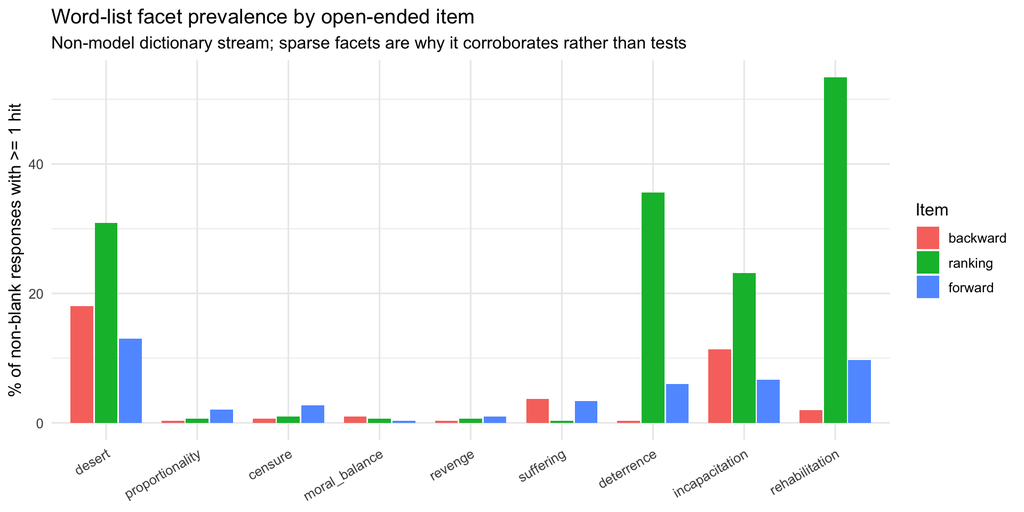

```r
# =========================================================================
# PHASE 3g: FIGURE -- WORD-LIST FACET PREVALENCE BY ITEM
# -------------------------------------------------------------------------
# WHAT THIS CHUNK DOES: plots the share of non-blank responses containing at
# least one word-list hit, per facet per item.
# PREREG: 6.7 (the non-model word list). Descriptive; not a test of anything and
#         not registered in the FDR family.
# WRITES: output/figures/wordlist_facet_prevalence.png
#
# WHY IT IS WORTH A FIGURE. It is the evidence for how the word list may be read.
# A facet that fires in a small minority of responses cannot support a stable
# correlation, so a near-zero word-list r for that facet is uninformative rather
# than negative. Phase 7 turns this into an explicit 10% rule for E5.
#
# fig.height = 5 overrides the document default of 7: nine facets x three items
# is a wide, short plot, and the taller default leaves a band of whitespace.
# GUARD: DICT_READY.
# =========================================================================

if (DICT_READY) {
  prev_long <- dict_long %>%
    dplyr::filter(n_words > 0) %>%
    # Wide -> long so facet can become an aesthetic. intersect() means facets the
    # notebook did not emit are simply not plotted.
    tidyr::pivot_longer(dplyr::all_of(intersect(FACETS_ALL, names(dict_long))),
                        names_to = "facet", values_to = "hits") %>%
    dplyr::group_by(item_type, facet) %>%
    dplyr::summarise(pct = 100 * mean(hits > 0, na.rm = TRUE), .groups = "drop") %>%
    # Explicit factor levels rather than alphabetical order: facets are ordered
    # principled -> vengeful -> consequentialist (the FACETS_ALL order), and the
    # items backward -> ranking -> forward, which puts the two backward-looking
    # items side by side so the eye can compare them before reaching the
    # forward-looking one.
    dplyr::mutate(facet = factor(facet, levels = FACETS_ALL),
                  item_type = factor(item_type,
                                     levels = c("backward", "ranking", "forward")))

  p_prev <- ggplot2::ggplot(prev_long,
                            ggplot2::aes(x = facet, y = pct, fill = item_type)) +
    ggplot2::geom_col(position = ggplot2::position_dodge(width = .8), width = .75) +
    ggplot2::labs(
      title = "Word-list facet prevalence by open-ended item",
      subtitle = "Non-model dictionary stream; sparse facets are why it corroborates rather than tests",
      x = NULL, y = "% of non-blank responses with >= 1 hit", fill = "Item") +
    ggplot2::theme_minimal(base_size = 12) +
    # Facet names are long; the 30-degree rotation keeps them legible without the
    # vertical labels a 90-degree rotation would give.
    ggplot2::theme(axis.text.x = ggplot2::element_text(angle = 30, hjust = 1))
  print(p_prev)
  # Saved as well as printed: the knitted HTML embeds it, and the PNG in
  # output/figures/ is what goes into a manuscript or onto OSF.
  ggplot2::ggsave(file.path(OUT_FIGURES, "wordlist_facet_prevalence.png"),
                  p_prev, width = 10, height = 5, dpi = 200)
} else {
  awaiting_colab("The word-list prevalence figure", NLP_FILES[["dictionary"]])
}
```

# PHASE 4: THE PRE-REGISTERED §6.7 VALIDATION GATE

> “A facet supports a claim only if the models agree at an intraclass correlation of at least .60 **and** the facet correlates at least .30 with its matching survey scale.” — prereg §6.7

Two clauses, both required:

- **Clause A (reliability)** — inter-model ICC ≥ 0.60, read from `ensemble_agreement.csv`. Agreement among models is *reliability, not validity*: models trained on similar data can share a bias, and the desert/revenge boundary is exactly what this study is examining.
- **Clause B (external validity)** — the facet correlates ≥ 0.30 with its matching survey scale, **word count partialled**, at the routed item. The survey scales are external to the text, which is what makes this clause do work that clause A cannot.

The two clauses are joined by **and**, not by *or*, and neither substitutes for the other. Clause A alone would certify an ensemble that agrees with itself about the wrong construct — three models trained on overlapping corpora can share a bias, and the very distinction this study exists to test, principled desert versus revenge, is one where a shared prior is likely. Clause B alone would certify a correlation computed from an average that no one could reproduce: if the models disagree, the facet score is a different number each time it is scored, and its correlation with anything is an accident of that particular run.

The four anchored pairings are fixed by prereg §6.7 and are not chosen after seeing the data: desert → `deserved` (the just-deserts purpose items, Retribution 1–4), proportionality → the single `proportionality` item, revenge → the `revenge` scale, suffering → the `suffer` items. Each survey scale is external to the text, which is what makes clause B a validity check rather than another internal-consistency check.

Facets with **no admissible survey anchor** — censure and moral balance, plus the three consequentialist facets — cannot clear clause B by construction. They are reported as **exploratory descriptives only** and never used to support a claim. This is settled by what the instrument measures, not by how their numbers come out.

The gate governs what a result may be *used for*; it does not decide which tests are run or which enter the FDR correction. A facet that fails still appears in the tables below, still enters the Benjamini–Hochberg family, and is still reported honestly — it simply supports no claim. Those are two different questions, and keeping them apart is what stops a small *p*-value from being mistaken for a valid measurement.

```r
# =========================================================================
# PHASE 4a: THE GATE SPECIFICATION, STATED BEFORE IT IS EVALUATED
# -------------------------------------------------------------------------
# WHAT THIS CHUNK DOES: prints, per facet, exactly what it would have to do to
# pass -- the ICC threshold and the named survey scale with its r threshold.
# PREREG: 6.7, both clauses.
# WRITES: gate_spec, and the printed specification table.
#
# This runs unguarded and therefore prints in full even before the ensemble
# exists. That is the point of putting it in its own chunk: the standard is on the
# record ahead of the numbers, and the five no-anchor facets are visibly marked as
# unable to clear clause B before anyone has seen how they scored.
# =========================================================================

gate_spec <- data.frame(
  facet = FACETS_ALL,
  clause_A = sprintf("inter-model ICC >= %.2f", ICC_MIN),
  clause_B = ifelse(FACETS_ALL %in% names(FACET_SCALE_MAP),
                    sprintf("r >= %.2f with survey '%s' (word count partialled)",
                            R_MIN, FACET_SCALE_MAP[FACETS_ALL]),
                    "NO ADMISSIBLE SURVEY ANCHOR - exploratory only"),
  stringsAsFactors = FALSE)
knitr::kable(gate_spec, row.names = FALSE,
             caption = "The two gate clauses, per facet (prereg 6.7)")
```

The two gate clauses, per facet (prereg 6.7)

| facet | clause_A | clause_B |
| --- | --- | --- |
| desert | inter-model ICC >= 0.60 | r >= 0.30 with survey ‘deserved’ (word count partialled) |
| proportionality | inter-model ICC >= 0.60 | r >= 0.30 with survey ‘proportionality’ (word count partialled) |
| censure | inter-model ICC >= 0.60 | NO ADMISSIBLE SURVEY ANCHOR - exploratory only |
| moral_balance | inter-model ICC >= 0.60 | NO ADMISSIBLE SURVEY ANCHOR - exploratory only |
| revenge | inter-model ICC >= 0.60 | r >= 0.30 with survey ‘revenge’ (word count partialled) |
| suffering | inter-model ICC >= 0.60 | r >= 0.30 with survey ‘suffering’ (word count partialled) |
| deterrence | inter-model ICC >= 0.60 | NO ADMISSIBLE SURVEY ANCHOR - exploratory only |
| incapacitation | inter-model ICC >= 0.60 | NO ADMISSIBLE SURVEY ANCHOR - exploratory only |
| rehabilitation | inter-model ICC >= 0.60 | NO ADMISSIBLE SURVEY ANCHOR - exploratory only |

```r
# =========================================================================
# PHASE 4b: EVALUATING THE 6.7 GATE
# -------------------------------------------------------------------------
# WHAT THIS CHUNK DOES: computes both clauses for all nine facets and assigns
# each a status of PASS, FAIL, or EXPLORATORY (no anchor).
# PREREG: 6.7 -- "A facet supports a claim only if the models agree at an
#         intraclass correlation of at least .60 and the facet correlates at
#         least .30 with its matching survey scale."
# WRITES: gate_table; output/tables/gate_table.csv.
#
# CLAUSE A is read from the agreement table: inter-model ICC >= ICC_MIN (.60).
# CLAUSE B is computed here: the partial correlation between the facet and its
#   matching survey scale, word count partialled, at the backward-looking items,
#   >= R_MIN (.30).
#
# BOTH REQUIRED, AND THE THRESHOLDS ARE ONE-SIDED IN THE OBVIOUS DIRECTION: a
# facet passes clause B on r >= .30, not on |r| >= .30. A facet that correlated
# -.45 with the scale it is supposed to be measuring has not been validated, it
# has been shown to run backwards, and treating that as a pass would let a
# sign-flipped scorer through the one check designed to catch it.
#
# ELSE BRANCH: when the ensemble or agreement table is missing, an all-NA gate
# table of the same shape is built and written anyway, so the CSV always exists
# and downstream tooling has a stable target. Every anchored facet reads
# "AWAITING COLAB OUTPUTS" and every unanchored one reads "EXPLORATORY (no survey
# anchor)" -- the second is a permanent fact about the instrument, not a
# consequence of the pipeline not having run.
#
# GUARD: GATE_READY (= ENS_READY && AGREE_READY).
# =========================================================================

gate_table <- NULL

if (GATE_READY) {

  # Re-resolved here rather than carried from Phase 3b so this chunk can be run on
  # its own in an interactive session without leaving icc_col undefined.
  icc_col <- intersect(c("icc2k", "icc_2k", "ICC2k", "ICC_2k", "icc", "ICC",
                         "icc2_1", "icc21"), names(agree_tbl))[1]

  # ICC per facet; if the agreement table is split by item_type, take the value at
  # the routed (backward-looking) item, else the single value.
  #' @param f  facet name
  #' @return   the facet's inter-model ICC, or NA if the table has no such row
  #'
  #' Routing to the backward-looking items matters: reliability is a property of
  #' the models scoring THIS corpus, and the corpus clause B is computed on is the
  #' backward-looking one. Averaging in the forward item's ICC would let good
  #' agreement about deterrence language prop up poor agreement about desert.
  #' Where the notebook reports one ICC per facet with no item breakdown, the
  #' single value is used unchanged.
  get_icc <- function(f) {
    a <- agree_tbl[agree_tbl$facet == f, , drop = FALSE]
    if (!nrow(a)) return(NA_real_)
    if ("item_type" %in% names(a) && any(a$item_type %in% BACKWARD_ITEMS)) {
      a <- a[a$item_type %in% BACKWARD_ITEMS, , drop = FALSE]
    }
    # as.numeric guards against the column arriving as character (a stray "NA" or
    # a thousands separator); suppressWarnings absorbs the expected coercion note.
    mean(suppressWarnings(as.numeric(a[[icc_col]])), na.rm = TRUE)
  }

  # Clause B: facet at the backward-looking items vs its survey scale, word count
  # partialled. Participant-level aggregation over the backward items (Q1, Q333).
  gate_rows <- lapply(FACETS_ALL, function(f) {
    ens_col <- paste0("ens_", f)
    icc <- get_icc(f)
    # A facet with no entry in FACET_SCALE_MAP has no admissible anchor; anchor
    # stays NA and clause B is never attempted for it.
    anchor <- if (f %in% names(FACET_SCALE_MAP)) FACET_SCALE_MAP[[f]] else NA_character_
    # Pre-seeded with the same shape part_cor() returns, so the data.frame at the
    # foot of the function has its columns whether or not clause B ran.
    r <- data.frame(r = NA_real_, lo = NA_real_, hi = NA_real_, p = NA_real_, n = 0L)

    if (!is.na(anchor) && ens_col %in% names(facets_joined)) {
      # AGGREGATE TO THE PARTICIPANT FIRST. The survey scale is a participant-level
      # score, so the correlation has to be participant-level too. Correlating at
      # response x item grain would enter each participant twice (Q1 and Q333) with
      # their scale value repeated, which inflates n, understates the standard
      # error, and turns a within-person consistency into apparent between-person
      # agreement.
      agg <- facets_joined %>%
        dplyr::filter(item_type %in% BACKWARD_ITEMS, nonblank) %>%
        dplyr::group_by(response_id) %>%
        # facet_score: mean across whichever backward items the person answered.
        # n_words: SUMMED, not averaged -- the covariate should represent the total
        #   volume of text the facet score was computed from, which is what drives
        #   the opportunity to trip a facet.
        # scale_score: first() because the survey value is constant within
        #   response_id; mean() would give the same number, first() says why.
        dplyr::summarise(facet_score = mean(.data[[ens_col]], na.rm = TRUE),
                         n_words = sum(n_words, na.rm = TRUE),
                         scale_score = dplyr::first(.data[[paste0("sv_", anchor)]]),
                         .groups = "drop")
      r <- part_cor(agg$facet_score, agg$scale_score, agg$n_words)
    }

    # The !is.na() wrappers make a missing value a FAIL rather than an NA that
    # would propagate into the status test and land in the else branch anyway --
    # explicit is better here, because "we could not evaluate this" and "this
    # failed" both mean the facet supports no claim.
    clause_A <- !is.na(icc) && icc >= ICC_MIN
    clause_B <- !is.na(r$r) && r$r >= R_MIN
    # Three statuses, and the order of the tests matters: the no-anchor check comes
    # FIRST, so an unanchored facet is never labelled a failure. It did not fail
    # the gate; the instrument gives it nothing to be validated against.
    status <- if (is.na(anchor)) {
      "EXPLORATORY (no survey anchor)"
    } else if (clause_A && clause_B) {
      "PASS - may support a claim"
    } else {
      "FAIL - descriptive only"
    }
    data.frame(facet = f, survey_anchor = ifelse(is.na(anchor), "-", anchor),
               icc = icc, clause_A_icc = clause_A,
               r_survey = r$r, r_lo = r$lo, r_hi = r$hi, r_p = r$p, n = r$n,
               clause_B_r = clause_B, status = status, stringsAsFactors = FALSE)
  })
  gate_table <- do.call(rbind, gate_rows)

  # The table reports the INPUTS to both clauses (icc, r with its CI, p, n) next
  # to the booleans and the verdict, so a reader can see how near a miss a FAIL
  # was rather than only that it failed.
  print(knitr::kable(gate_table, digits = 3, row.names = FALSE,
                     caption = "Section 6.7 validation gate"))
  readr::write_csv(gate_table, file.path(OUT_TABLES, "gate_table.csv"))
  cat(sprintf("\nWrote %s\n", file.path(OUT_TABLES, "gate_table.csv")))

} else {
  # Same columns, same facet order, all NA. Written to the same path so the CSV
  # exists in both states and nothing downstream has to branch on its presence.
  gate_table <- data.frame(
    facet = FACETS_ALL,
    survey_anchor = ifelse(FACETS_ALL %in% names(FACET_SCALE_MAP),
                           FACET_SCALE_MAP[FACETS_ALL], "-"),
    icc = NA_real_, clause_A_icc = NA, r_survey = NA_real_, r_lo = NA_real_,
    r_hi = NA_real_, r_p = NA_real_, n = NA_integer_, clause_B_r = NA,
    status = ifelse(FACETS_ALL %in% names(FACET_SCALE_MAP),
                    "AWAITING COLAB OUTPUTS", "EXPLORATORY (no survey anchor)"),
    stringsAsFactors = FALSE)
  print(knitr::kable(gate_table, row.names = FALSE,
                     caption = "Section 6.7 validation gate (not yet evaluable)"))
  readr::write_csv(gate_table, file.path(OUT_TABLES, "gate_table.csv"))
  cat("\n")
  awaiting_colab("The 6.7 validation gate",
                 c(NLP_FILES[["ensemble"]], NLP_FILES[["agreement"]]))
}
```

```
##
##
## Table: Section 6.7 validation gate (not yet evaluable)
##
## |facet           |survey_anchor   | icc|clause_A_icc | r_survey| r_lo| r_hi| r_p|  n|clause_B_r |status                         |
## |:---------------|:---------------|---:|:------------|--------:|----:|----:|---:|--:|:----------|:------------------------------|
## |desert          |deserved        |  NA|NA           |       NA|   NA|   NA|  NA| NA|NA         |AWAITING COLAB OUTPUTS         |
## |proportionality |proportionality |  NA|NA           |       NA|   NA|   NA|  NA| NA|NA         |AWAITING COLAB OUTPUTS         |
## |censure         |-               |  NA|NA           |       NA|   NA|   NA|  NA| NA|NA         |EXPLORATORY (no survey anchor) |
## |moral_balance   |-               |  NA|NA           |       NA|   NA|   NA|  NA| NA|NA         |EXPLORATORY (no survey anchor) |
## |revenge         |revenge         |  NA|NA           |       NA|   NA|   NA|  NA| NA|NA         |AWAITING COLAB OUTPUTS         |
## |suffering       |suffering       |  NA|NA           |       NA|   NA|   NA|  NA| NA|NA         |AWAITING COLAB OUTPUTS         |
## |deterrence      |-               |  NA|NA           |       NA|   NA|   NA|  NA| NA|NA         |EXPLORATORY (no survey anchor) |
## |incapacitation  |-               |  NA|NA           |       NA|   NA|   NA|  NA| NA|NA         |EXPLORATORY (no survey anchor) |
## |rehabilitation  |-               |  NA|NA           |       NA|   NA|   NA|  NA| NA|NA         |EXPLORATORY (no survey anchor) |
##
## --------------------------------------------------------------------------
## AWAITING COLAB OUTPUTS from Analysis/NLP/colab/
##   The 6.7 validation gate cannot be computed yet.
##   Required file(s) not found: ensemble_facet_scores.csv, ensemble_agreement.csv
##   Produced by the notebooks in Analysis/NLP/colab/:
##     01_preprocessing_and_facets   -> facet_dictionary_scores.csv, gold_codes.csv,
##                                      gold_split_assignment.csv
##     02_llm_ensemble_scoring       -> ensemble_facet_scores.csv, ensemble_agreement.csv
##     03_embeddings_and_similarity  -> embedding_facet_similarity.csv
##   Drop the downloaded CSVs into Analysis/NLP/outputs/ (or R/nlp/) and re-knit.
## --------------------------------------------------------------------------
```

```r
# =========================================================================
# PHASE 4c: THE GATE-PASSING FACET SET
# -------------------------------------------------------------------------
# WHAT THIS CHUNK DOES: reduces the gate table to GATE_PASS, the character vector
# of facets a claim may rest on, and says plainly what it means when it is empty.
# PREREG: 6.7.
# WRITES: GATE_PASS -- read by every register_test() call in Phases 5-9 (as
#         claim_eligible) and by E7's predictor selection in Phase 9.
#
# GATE_PASS is the single point of contact between the validation step and the
# hypothesis tests. Nothing downstream re-derives it, so a facet's claim status is
# decided once, here, from the printed table.
# =========================================================================

# The facets any E3-E7 CLAIM may rest on. Everything else is descriptive.
# The any(!is.na(clause_A_icc)) test distinguishes "the gate ran and nothing
# passed" from "the gate never ran": in the awaiting-Colab table every
# clause_A_icc is NA, and the status column carries the placeholder text rather
# than a verdict, so matching on status alone would be reading a label that was
# never earned. Both cases yield character(0), but only for the right reason.
GATE_PASS <- if (!is.null(gate_table) && any(!is.na(gate_table$clause_A_icc))) {
  gate_table$facet[gate_table$status == "PASS - may support a claim"]
} else character(0)

cat("Gate-passing facets (claims may rest on these):\n")
```

```
## Gate-passing facets (claims may rest on these):
```

```r
if (length(GATE_PASS)) {
  cat(sprintf("  %s\n", paste(GATE_PASS, collapse = ", ")))
} else {
  cat("  none yet - the gate has not been evaluated.\n")
  cat("  Until it is, every facet result below is DESCRIPTIVE and supports no claim.\n")
}
```

```
##   none yet - the gate has not been evaluated.
##   Until it is, every facet result below is DESCRIPTIVE and supports no claim.
```

```r
# =========================================================================
# PHASE 4d: FIGURE -- THE GATE AS A PLANE
# -------------------------------------------------------------------------
# WHAT THIS CHUNK DOES: plots every facet in the ICC x survey-r plane, with the
# pass region shaded and both thresholds drawn as dashed lines.
# PREREG: 6.7.
# WRITES: output/figures/gate_icc_by_survey_r.png
#
# The figure makes the conjunction visual: only the upper-right rectangle passes,
# and a facet sitting just outside one line is visibly a near miss on ONE clause
# rather than a general failure. It also makes the two failure modes legible at a
# glance -- high ICC with low r is the models agreeing about something the survey
# does not recognise; low ICC with high r is a correlation resting on an
# unreliable average.
#
# GUARD: GATE_READY plus at least one non-NA r_survey -- an all-NA plane would
# render as an empty panel, which reads as a broken figure rather than as a
# pending one, so the awaiting-Colab banner is printed instead.
# =========================================================================

if (GATE_READY && any(!is.na(gate_table$r_survey))) {
  # Keep any facet with at least one coordinate. A no-anchor facet has an ICC but
  # no r, so it drops out of the plot at the geom stage; it stays in the printed
  # table above, where its status is stated in words.
  gt <- gate_table[!is.na(gate_table$icc) | !is.na(gate_table$r_survey), ]
  p_gate <- ggplot2::ggplot(gt, ggplot2::aes(x = icc, y = r_survey, label = facet)) +
    # The shaded rectangle IS the gate: x >= .60 AND y >= .30, unbounded above.
    # Drawn first so the points sit on top of it.
    ggplot2::geom_rect(xmin = ICC_MIN, xmax = Inf, ymin = R_MIN, ymax = Inf,
                       fill = "grey90", colour = NA) +
    ggplot2::geom_vline(xintercept = ICC_MIN, linetype = "dashed") +
    ggplot2::geom_hline(yintercept = R_MIN, linetype = "dashed") +
    ggplot2::geom_point(size = 3) +
    # Labels sit just above their points so a cluster near a threshold stays
    # readable.
    ggplot2::geom_text(vjust = -0.9, size = 3.5) +
    ggplot2::labs(title = "Section 6.7 validation gate",
                  subtitle = sprintf("Shaded region: ICC >= %.2f AND r >= %.2f with the matching survey scale",
                                     ICC_MIN, R_MIN),
                  x = "Inter-model ICC", y = "r with matching survey scale (word count partialled)") +
    ggplot2::theme_minimal(base_size = 12)
  print(p_gate)
  ggplot2::ggsave(file.path(OUT_FIGURES, "gate_icc_by_survey_r.png"),
                  p_gate, width = 8, height = 5, dpi = 200)
} else {
  awaiting_colab("The gate figure (ICC x survey-r plane)",
                 c(NLP_FILES[["ensemble"]], NLP_FILES[["agreement"]]))
}
```

```
## --------------------------------------------------------------------------
## AWAITING COLAB OUTPUTS from Analysis/NLP/colab/
##   The gate figure (ICC x survey-r plane) cannot be computed yet.
##   Required file(s) not found: ensemble_facet_scores.csv, ensemble_agreement.csv
##   Produced by the notebooks in Analysis/NLP/colab/:
##     01_preprocessing_and_facets   -> facet_dictionary_scores.csv, gold_codes.csv,
##                                      gold_split_assignment.csv
##     02_llm_ensemble_scoring       -> ensemble_facet_scores.csv, ensemble_agreement.csv
##     03_embeddings_and_similarity  -> embedding_facet_similarity.csv
##   Drop the downloaded CSVs into Analysis/NLP/outputs/ (or R/nlp/) and re-knit.
## --------------------------------------------------------------------------
```

# PHASE 5: E3 — RETRIBUTIVISTS VERSUS OTHERS ON THE BACKWARD-LOOKING TEXTS

**E3 (exploratory).** In the backward-looking explanations — the sentence justification (**Q1**, `item_type == "backward"`) and the goal-ranking explanation (**Q333**, `item_type == "ranking"`) — retributivists use more desert, proportionality, and censure language than non-retributivists.

Two forms, both run: (a) the **categorical** contrast, retributivists (`Prioritization_1 == 1`) versus everyone else, Welch *t* with Cohen’s *d*; and (b) the **continuous** form, a regression of the facet on the **relative retribution subscale** (the primary continuous measure of prereg §5.3), with **word count** as a covariate. Q1 and Q333 are analysed **separately, never pooled** — the two backward items act as a within-study replication of each other.

Both retributivist measures are used because prereg §5.3 expects any single one to be imperfect: participants may report the goals they take to be socially expected, people often punish on desert while describing utilitarian aims, and introspective access to a punitive motive is limited. The categorical and continuous forms fail differently, so agreement between them is informative and disagreement is worth seeing rather than averaging away.

```r
# =========================================================================
# PHASE 5: E3 -- RETRIBUTIVIST LANGUAGE IN THE BACKWARD-LOOKING TEXTS
# -------------------------------------------------------------------------
# WHAT THIS CHUNK DOES: for each backward-looking item and each of five facets,
# runs (a) a Welch contrast of retributivists against everyone else on the
# word-count-adjusted facet score and (b) a regression of the facet on the
# relative retribution subscale with word count covaried. Registers both in the
# exploratory family.
# PREREG: 2.4 (E3), 6.7 ("For E3 we compare facet scores between retributivists
#         and others, and regress them on the retribution subscale, using the
#         backward-looking texts"), 5.3 (both retributivist measures).
# WRITES: e3_results; output/tables/e3_backward_facets.csv; 2 x items x facets
#         rows appended to FAMILY.
#
# EXPLORATORY. E3 is one of the five predictions in the single exploratory family;
# nothing here is confirmatory, and the p-values in the printed table are raw --
# the BH-adjusted values that carry the inference appear in Phase 10.
#
# GUARD: E_READY. Before the ensemble exists this prints the awaiting-Colab
# banner and registers nothing, which is why the Phase 10 family is empty.
# =========================================================================

e3_results <- NULL

if (E_READY) {

  # E3 names desert, proportionality and censure. The two vengeful facets are run
  # alongside them not because E3 predicts anything about them, but because the
  # interesting comparison is whether retributivists' language is MORE principled
  # in particular or simply more punitive across the board; without the vengeful
  # facets in the same table that question cannot be read off the results.
  e3_facets <- intersect(c(E4_PRINCIPLED, VENGEFUL_FACETS), FACETS_ALL)
  rows <- list()

  # Outer loop: one item at a time (prereg 5.15 -- Q1 and Q333 never pooled).
  for (it in BACKWARD_ITEMS) {
    dd <- facets_joined %>% dplyr::filter(item_type == it, nonblank)
    for (f in e3_facets) {
      ens_col <- paste0("ens_", f)
      # A facet the ensemble did not score is skipped rather than fabricated.
      if (!ens_col %in% names(dd)) next

      # (a) categorical: retributivist vs rest, word count residualised out first
      # The covariate cannot enter a t-test directly, so it is removed first by
      # regressing the facet on n_words and testing the residuals. That is the
      # same adjustment the regression in (b) makes internally, applied here so
      # the group contrast is covariate-adjusted too -- prereg 6.7 makes word
      # count a covariate throughout, not only in the regression form.
      y_raw <- dd[[ens_col]]
      ok <- stats::complete.cases(y_raw, dd$n_words)
      # y_adj is pre-filled with NA and written only at the complete rows, so the
      # residual vector stays aligned with dd's rows and lines up with
      # sv_retributivist below. Building it from resid() alone would silently
      # shift the group labels against the scores.
      y_adj <- rep(NA_real_, nrow(dd))
      if (sum(ok) > 5) y_adj[ok] <- stats::resid(stats::lm(y_raw[ok] ~ dd$n_words[ok]))
      # Welch rather than Student: the retributivist group is a minority of the
      # sample, so the two ns are unequal, and equal variances are not something
      # to assume when one group may talk about desert both more and more
      # variably. See welch_d() in Phase 0c.
      wd <- welch_d(y_adj, dd$sv_retributivist)

      # (b) continuous: regression on the relative retribution subscale + word count
      # retribution_rel is prereg 5.3's primary CONTINUOUS measure -- retribution
      # minus the mean of the other three goals -- so this form does not depend on
      # where the categorical split falls, and it uses the whole sample rather
      # than contrasting two groups. Word count enters as a second predictor,
      # which is the same adjustment (a) makes by residualising.
      m <- tryCatch(stats::lm(y_raw ~ dd$sv_retribution_rel + dd$n_words),
                    error = function(e) NULL)
      b <- se <- pval <- NA_real_
      # Row 2 of the coefficient matrix is sv_retribution_rel (row 1 is the
      # intercept, row 3 is n_words). The nrow() check catches a model that
      # collapsed to an intercept because the predictor had no variance.
      if (!is.null(m) && nrow(stats::coef(summary(m))) >= 2) {
        cf <- stats::coef(summary(m))[2, ]
        b <- cf[["Estimate"]]; se <- cf[["Std. Error"]]; pval <- cf[["Pr(>|t|)"]]
      }

      # One row per item x facet carrying BOTH forms side by side, plus the gate
      # verdict, so a reader never sees an E3 effect without seeing whether the
      # facet behind it was validated.
      rows[[length(rows) + 1]] <- data.frame(
        item = it, facet = f, gate = ifelse(f %in% GATE_PASS, "PASS", "not gated"),
        M_other = wd$M0, M_retributivist = wd$M1, t = wd$t, p_group = wd$p, d = wd$d,
        b_retrib_rel = b, se = se, p_reg = pval, n = wd$n, stringsAsFactors = FALSE)

      # Both forms are registered separately: they are two tests, they can
      # disagree, and BH must see the true number of tests in the family.
      # The d interval uses the large-sample approximation SE(d) ~ sqrt(4/n),
      # which is the standard 2/sqrt(n) form; max(n, 2) keeps it finite if a
      # degenerate cell ever returned n = 0.
      register_test("E3", sprintf("%s | %s | retributivist vs rest (word count adj.)", it, f),
                    "Cohen's d", wd$d,
                    wd$d - 1.96 * sqrt(4 / max(wd$n, 2)), wd$d + 1.96 * sqrt(4 / max(wd$n, 2)),
                    wd$p, wd$n, claim_eligible = f %in% GATE_PASS)
      # The regression CI is the conventional b +/- 1.96 SE.
      register_test("E3", sprintf("%s | %s | ~ relative retribution + word count", it, f),
                    "b", b, b - 1.96 * se, b + 1.96 * se, pval, wd$n,
                    claim_eligible = f %in% GATE_PASS)
    }
  }
  e3_results <- do.call(rbind, rows)
  if (!is.null(e3_results)) {
    print(knitr::kable(e3_results, digits = 3, row.names = FALSE,
                       caption = "E3: backward-looking facet language, Q1 and Q333 separately"))
    readr::write_csv(e3_results, file.path(OUT_TABLES, "e3_backward_facets.csv"))
  }

} else {
  awaiting_colab("E3 (retributivists vs others on the backward-looking texts)",
                 c(NLP_FILES[["ensemble"]], NLP_FILES[["agreement"]]))
}
```

```
## --------------------------------------------------------------------------
## AWAITING COLAB OUTPUTS from Analysis/NLP/colab/
##   E3 (retributivists vs others on the backward-looking texts) cannot be computed yet.
##   Required file(s) not found: ensemble_facet_scores.csv, ensemble_agreement.csv
##   Produced by the notebooks in Analysis/NLP/colab/:
##     01_preprocessing_and_facets   -> facet_dictionary_scores.csv, gold_codes.csv,
##                                      gold_split_assignment.csv
##     02_llm_ensemble_scoring       -> ensemble_facet_scores.csv, ensemble_agreement.csv
##     03_embeddings_and_similarity  -> embedding_facet_similarity.csv
##   Drop the downloaded CSVs into Analysis/NLP/outputs/ (or R/nlp/) and re-knit.
## --------------------------------------------------------------------------
```

```r
# =========================================================================
# PHASE 5b: E3 WORD-LIST PREVIEW (descriptive)
# -------------------------------------------------------------------------
# WHAT THIS CHUNK DOES: runs the E3 group contrast on the non-model word-list
# scores instead of the ensemble, for the three principled facets.
# PREREG: 6.7 (the word list as a non-model stream). This is NOT the E3 test:
#         prereg 6.7 tests E3 on the facet scores, and reserves the word list for
#         corroboration.
# WRITES: prev_tbl; output/tables/e3_wordlist_preview.csv. Registers NOTHING.
#
# WHY IT IS HERE AND WHY IT IS NOT IN THE FAMILY. The word list is scored by a
# different notebook and can arrive before the ensemble, so this is often the
# first E3-shaped number the document can produce. It is worth seeing -- if the
# word list shows nothing at all, the ensemble result deserves more scepticism --
# but it is descriptive, so registering it would add rows to the BH denominator
# for a test nobody will claim from, costing power on the tests that matter.
#
# THE `&& !E_READY` IS DELIBERATE. Once the ensemble arrives, the real E3 test
# above supersedes this preview and it stops printing, so the two never sit in
# the output together where a reader might take the preview for the result.
# =========================================================================

# NON-MODEL PREVIEW. The word list is not the E3 test and is not registered in the
# FDR family; it is shown because it can be computed now and it is the same stream
# the prereg relies on for the E4 corroboration.
if (DICT_READY && !E_READY) {
  cat("DICTIONARY PREVIEW (non-model word list) - descriptive only, not the E3 test,\n")
  cat("not in the FDR family. Rates per 100 words, non-blank responses.\n\n")

  prev_rows <- list()
  for (it in BACKWARD_ITEMS) {
    dd <- facets_joined %>% dplyr::filter(item_type == it, nonblank)
    for (f in intersect(E4_PRINCIPLED, FACETS_ALL)) {
      dcol <- paste0("dict_", f)
      if (!dcol %in% names(dd)) next
      # No word-count residualisation here, unlike the ensemble version above: the
      # dictionary columns are already rates per 100 words, so the mechanical part
      # of the length effect is normalised out at source. That also means these
      # numbers are not on the same scale as the ensemble d's and should not be
      # compared to them digit for digit -- the preview answers whether the
      # direction is there, not whether the magnitude matches.
      wd <- welch_d(dd[[dcol]], dd$sv_retributivist)
      prev_rows[[length(prev_rows) + 1]] <- data.frame(
        item = it, facet = f, M_other = wd$M0, M_retributivist = wd$M1,
        t = wd$t, p = wd$p, d = wd$d, n = wd$n, stringsAsFactors = FALSE)
    }
  }
  if (length(prev_rows)) {
    prev_tbl <- do.call(rbind, prev_rows)
    print(knitr::kable(prev_tbl, digits = 3, row.names = FALSE,
                       caption = "E3 word-list preview (descriptive; NOT the E3 test)"))
    readr::write_csv(prev_tbl, file.path(OUT_TABLES, "e3_wordlist_preview.csv"))
  }
} else if (!DICT_READY) {
  awaiting_colab("The E3 word-list preview", NLP_FILES[["dictionary"]])
}
```

```
## DICTIONARY PREVIEW (non-model word list) - descriptive only, not the E3 test,
## not in the FDR family. Rates per 100 words, non-blank responses.
##
##
##
## Table: E3 word-list preview (descriptive; NOT the E3 test)
##
## |item     |facet           | M_other| M_retributivist|      t|     p|      d|   n|
## |:--------|:---------------|-------:|---------------:|------:|-----:|------:|---:|
## |backward |desert          |   0.826|           1.647|  1.588| 0.114|  0.216| 295|
## |backward |proportionality |   0.020|           0.000| -1.000| 0.319| -0.098| 295|
## |backward |censure         |   0.062|           0.000| -1.178| 0.240| -0.115| 295|
## |ranking  |desert          |   0.659|           1.161|  2.095| 0.038|  0.278| 293|
## |ranking  |proportionality |   0.016|           0.000| -1.400| 0.163| -0.137| 293|
## |ranking  |censure         |   0.021|           0.014| -0.346| 0.730| -0.038| 293|
```

# PHASE 6: E4 — PRINCIPLED AND VENGEFUL LANGUAGE TOGETHER

**E4 (exploratory).** Within participants, principled-retributive language (**desert, proportionality, censure**) appears **together with** vengeful language (**revenge, infliction of suffering**) rather than in place of it. A positive correlation between the two across responses would show that ordinary just deserts is bound up with revenge.

The prereg does not accept the ensemble correlation on its own:

> “Because both sides come from the same automated scoring, one method’s tendency to assign several facets at once could create this correlation on its own, so **we require the same co-occurrence to show up in the non-model word-list measure**, and **we compare it with the relationship between the desert and revenge scales in the survey**, before reading it as evidence…” — prereg §6.7

So three numbers are reported side by side: the **ensemble** correlation (the test), the **word-list** correlation (the required non-model corroboration), and the **survey** `r(deserved, revenge)` benchmark. Word count is partialled throughout.

```r
# =========================================================================
# PHASE 6a: E4 -- PRINCIPLED x VENGEFUL CO-OCCURRENCE (the ensemble arm)
# -------------------------------------------------------------------------
# WHAT THIS CHUNK DOES: per backward-looking item, averages the three principled
# facets and the two vengeful ones into two composites and correlates them with
# word count partialled; then prints the facet-by-facet breakdown behind that
# composite correlation.
# PREREG: 2.4 (E4), 6.7 ("For E4 we estimate the correlation across responses
#         between the principled facets (desert, proportionality, censure) and
#         the vengeful facets (revenge, suffering)").
# WRITES: e4_rows (the ensemble entries); one FAMILY row per item.
#
# WHAT THE NUMBER WOULD MEAN. A POSITIVE correlation is the predicted result and
# the substantive claim: people who reach for desert language also reach for
# revenge language, so ordinary just deserts is bound up with getting even rather
# than standing apart from it. A null would say the two vocabularies are
# independent -- principled retributive talk is its own thing. A negative
# correlation would say they substitute for each other.
#
# WHY THE ENSEMBLE NUMBER CANNOT BE READ ALONE. Both sides come from the same
# scorer, and one method's tendency to assign several facets to a rich response
# would produce a positive correlation by itself. That is why prereg 6.7 REQUIRES
# the word-list corroboration in the next chunk before this is read as evidence.
#
# GUARD: E_READY.
# =========================================================================

e4_rows <- list()

if (E_READY) {
  for (it in BACKWARD_ITEMS) {
    dd <- facets_joined %>% dplyr::filter(item_type == it, nonblank)
    pcols <- intersect(paste0("ens_", E4_PRINCIPLED), names(dd))
    vcols <- intersect(paste0("ens_", E4_VENGEFUL),   names(dd))
    # Both sides need at least one facet present or there is no correlation to
    # compute; skip the item rather than emit a spurious NA row.
    if (!length(pcols) || !length(vcols)) next

    # The two composites are unweighted row means of the facets on each side --
    # the sides the prereg names, three principled and two vengeful. na.rm keeps a
    # response contributing when the ensemble scored some facets but not others.
    dd$principled <- rowMeans(dd[, pcols, drop = FALSE], na.rm = TRUE)
    dd$vengeful   <- rowMeans(dd[, vcols, drop = FALSE], na.rm = TRUE)
    # Word count partialled: without it, a long response scores higher on both
    # composites simply by containing more material, and the correlation would
    # largely be a correlation between length and length.
    pc <- part_cor(dd$principled, dd$vengeful, dd$n_words)

    e4_rows[[length(e4_rows) + 1]] <- data.frame(
      stream = "ensemble (LLM)", item = it, r = pc$r, lo = pc$lo, hi = pc$hi,
      p = pc$p, n = pc$n, stringsAsFactors = FALSE)
    # claim_eligible requires at least one gate-passing facet on EACH side: a
    # correlation between a validated principled composite and an unvalidated
    # vengeful one is a correlation with something whose meaning is unestablished,
    # so it cannot carry the claim either.
    register_test("E4", sprintf("%s | principled x vengeful (ensemble, word count partialled)", it),
                  "partial r", pc$r, pc$lo, pc$hi, pc$p, pc$n,
                  claim_eligible = any(E4_PRINCIPLED %in% GATE_PASS) &&
                                   any(E4_VENGEFUL %in% GATE_PASS))

    # Facet-by-facet detail: which principled facet travels with which vengeful one.
    # The composite correlation can hide its own composition -- a strong
    # desert x revenge link with nothing else would produce much the same number
    # as three uniformly moderate links, and those are different findings. Printed
    # only, not registered: these six cells are a decomposition of the test above,
    # not six additional tests, and registering them would multiply E4's weight in
    # the BH family sixfold for one prediction.
    detail <- expand.grid(p = E4_PRINCIPLED, v = E4_VENGEFUL, stringsAsFactors = FALSE)
    det_rows <- lapply(seq_len(nrow(detail)), function(i) {
      pc_i <- part_cor(dd[[paste0("ens_", detail$p[i])]],
                       dd[[paste0("ens_", detail$v[i])]], dd$n_words)
      data.frame(item = it, principled = detail$p[i], vengeful = detail$v[i],
                 r = pc_i$r, lo = pc_i$lo, hi = pc_i$hi, p = pc_i$p, n = pc_i$n)
    })
    print(knitr::kable(do.call(rbind, det_rows), digits = 3, row.names = FALSE,
                       caption = sprintf("E4 detail (%s): each principled facet x each vengeful facet", it)))
  }
} else {
  awaiting_colab("E4 (ensemble principled x vengeful co-occurrence)",
                 c(NLP_FILES[["ensemble"]], NLP_FILES[["agreement"]]))
}
```

```
## --------------------------------------------------------------------------
## AWAITING COLAB OUTPUTS from Analysis/NLP/colab/
##   E4 (ensemble principled x vengeful co-occurrence) cannot be computed yet.
##   Required file(s) not found: ensemble_facet_scores.csv, ensemble_agreement.csv
##   Produced by the notebooks in Analysis/NLP/colab/:
##     01_preprocessing_and_facets   -> facet_dictionary_scores.csv, gold_codes.csv,
##                                      gold_split_assignment.csv
##     02_llm_ensemble_scoring       -> ensemble_facet_scores.csv, ensemble_agreement.csv
##     03_embeddings_and_similarity  -> embedding_facet_similarity.csv
##   Drop the downloaded CSVs into Analysis/NLP/outputs/ (or R/nlp/) and re-knit.
## --------------------------------------------------------------------------
```

```r
# =========================================================================
# PHASE 6b: E4 -- THE REQUIRED NON-MODEL CORROBORATION
# -------------------------------------------------------------------------
# WHAT THIS CHUNK DOES: repeats the principled x vengeful correlation on the
# word-list scores, and reports the co-firing base rates that say whether that
# correlation could have been detected at all.
# PREREG: 6.7 -- "we require the same co-occurrence to show up in the non-model
#         word-list measure ... before reading it as evidence that ordinary just
#         deserts is bound up with revenge."
# WRITES: word-list entries appended to e4_rows. Registers NOTHING -- this is the
#         corroboration condition on E4, not a second test of it.
#
# THIS IS A PRECONDITION, NOT A ROBUSTNESS CHECK. The prereg makes the word-list
# result a requirement for reading the ensemble result as evidence. If the
# ensemble shows co-occurrence and the word list does not, the honest reading is
# that the co-occurrence may be an artifact of one scorer assigning several facets
# to the same rich response -- unless the base rates below show the word list was
# too sparse to have found it either way.
#
# GUARD: DICT_READY, tested independently of E_READY, so the corroboration can be
# computed and printed even while the ensemble arm is still awaiting Colab.
# =========================================================================

# THE REQUIRED NON-MODEL CORROBORATION. This runs on the word list, which uses no
# language model, so its agreement with the ensemble is a more independent check
# than the models' agreement with one another (prereg 6.7).
if (DICT_READY) {
  for (it in BACKWARD_ITEMS) {
    dd <- facets_joined %>% dplyr::filter(item_type == it, nonblank)
    pcols <- intersect(paste0("dict_", E4_PRINCIPLED), names(dd))
    vcols <- intersect(paste0("dict_", E4_VENGEFUL),   names(dd))
    if (!length(pcols) || !length(vcols)) next

    # Built exactly as the ensemble composites were, on the same facet sets and
    # the same items, so the two rows of the summary table differ only in scorer.
    dd$principled_wl <- rowMeans(dd[, pcols, drop = FALSE], na.rm = TRUE)
    dd$vengeful_wl   <- rowMeans(dd[, vcols, drop = FALSE], na.rm = TRUE)
    # Word count is partialled here too even though these are already per-100-word
    # rates: normalising removes the mechanical length effect, but facet DENSITY
    # can still vary with length (a longer answer may be more elaborated as well
    # as longer), and that residual path is what the covariate closes.
    pc <- part_cor(dd$principled_wl, dd$vengeful_wl, dd$n_words)

    e4_rows[[length(e4_rows) + 1]] <- data.frame(
      stream = "word list (non-model)", item = it, r = pc$r, lo = pc$lo, hi = pc$hi,
      p = pc$p, n = pc$n, stringsAsFactors = FALSE)
  }

  # Base rates matter here: the word list is structurally sparse on revenge, so a
  # near-zero correlation can be absence of signal rather than absence of
  # co-occurrence. Report the co-firing base rate alongside the correlation.
  #
  # HOW TO READ THE THREE PERCENTAGES. pct_both is the share of responses where at
  # least one principled facet AND at least one vengeful facet fired. If that is
  # near zero, the word-list correlation carries almost no information: the
  # co-occurrence the prereg asks it to corroborate had essentially no opportunity
  # to appear, and a null there does not undercut the ensemble result. If pct_both
  # is substantial and the correlation is still null, the corroboration has
  # genuinely failed and E4 cannot be read as evidence.
  # Descriptive; not registered.
  cofire <- facets_joined %>%
    dplyr::filter(item_type %in% BACKWARD_ITEMS, nonblank) %>%
    dplyr::group_by(item_type) %>%
    dplyr::summarise(
      pct_any_principled = 100 * mean(rowSums(dplyr::across(
        dplyr::any_of(paste0("dict_", E4_PRINCIPLED))) > 0, na.rm = TRUE) > 0),
      pct_any_vengeful = 100 * mean(rowSums(dplyr::across(
        dplyr::any_of(paste0("dict_", E4_VENGEFUL))) > 0, na.rm = TRUE) > 0),
      pct_both = 100 * mean(
        rowSums(dplyr::across(dplyr::any_of(paste0("dict_", E4_PRINCIPLED))) > 0, na.rm = TRUE) > 0 &
        rowSums(dplyr::across(dplyr::any_of(paste0("dict_", E4_VENGEFUL))) > 0, na.rm = TRUE) > 0),
      .groups = "drop")
  print(knitr::kable(cofire, digits = 1, row.names = FALSE,
                     caption = "Word-list co-firing base rates (a near-zero r may be sparsity, not independence)"))
} else {
  awaiting_colab("The required non-model word-list corroboration for E4",
                 NLP_FILES[["dictionary"]])
}
```

[output not shown]

```r
# =========================================================================
# PHASE 6c: E4 -- THE THREE STREAMS SIDE BY SIDE
# -------------------------------------------------------------------------
# WHAT THIS CHUNK DOES: appends the survey benchmark to the ensemble and
# word-list rows and prints all three in one table, then restates the condition
# prereg 6.7 places on reading the ensemble estimate as evidence.
# PREREG: 6.7 -- "we compare it with the relationship between the desert and
#         revenge scales in the survey ... before reading it as evidence".
# WRITES: e4_results; output/tables/e4_principled_vengeful.csv.
#
# This chunk is UNGUARDED, and that is deliberate: the survey benchmark is always
# available, so the table always prints with at least one row. In the
# awaiting-Colab state it contains the survey benchmark alone, which is exactly
# the information a reader needs -- the yardstick, visible before the thing being
# measured arrives.
#
# WHY ALL THREE BELONG IN ONE TABLE. The ensemble r is the estimate, the word-list
# r is the precondition on reading it, and the survey r is the scale it is read
# against. Reported separately, an ensemble r of .35 looks like a finding;
# reported next to a survey r(deserved, revenge) of similar size it looks like the
# text reproducing what the closed-ended items already say, and next to a survey r
# near zero it looks like something the questionnaire missed.
# =========================================================================

# Survey benchmark, always available. Computed back in Phase 1c from the
# closed-ended scales alone, so it does not depend on any Colab output.
e4_rows[[length(e4_rows) + 1]] <- data.frame(
  stream = "survey benchmark", item = "r(deserved, revenge)",
  r = bench_desert_revenge$r, lo = bench_desert_revenge$lo,
  hi = bench_desert_revenge$hi, p = bench_desert_revenge$p,
  n = bench_desert_revenge$n, stringsAsFactors = FALSE)

e4_results <- do.call(rbind, e4_rows)
print(knitr::kable(e4_results, digits = 3, row.names = FALSE,
                   caption = "E4: principled x vengeful co-occurrence across the three streams"))
```

```
##
##
## Table: E4: principled x vengeful co-occurrence across the three streams
##
## |stream                |item                 |      r|     lo|    hi|     p|   n|
## |:---------------------|:--------------------|------:|------:|-----:|-----:|---:|
## |word list (non-model) |backward             | -0.045| -0.158| 0.070| 0.444| 295|
## |word list (non-model) |ranking              |  0.040| -0.075| 0.154| 0.498| 293|
## |survey benchmark      |r(deserved, revenge) |  0.551|  0.505| 0.594| 0.000| 948|
```

```r
readr::write_csv(e4_results, file.path(OUT_TABLES, "e4_principled_vengeful.csv"))

cat("\nReading rule (prereg 6.7): the ensemble correlation is read as evidence that\n")
```

```
##
## Reading rule (prereg 6.7): the ensemble correlation is read as evidence that
```

```r
cat("ordinary just deserts is bound up with revenge ONLY IF the same co-occurrence\n")
```

```
## ordinary just deserts is bound up with revenge ONLY IF the same co-occurrence
```

```r
cat("appears in the non-model word-list stream, and it is interpreted against the\n")
```

```
## appears in the non-model word-list stream, and it is interpreted against the
```

```r
cat("survey r(deserved, revenge) shown above rather than in isolation.\n")
```

```
## survey r(deserved, revenge) shown above rather than in isolation.
```

```r
if (!E_READY) {
  cat("\nThe ensemble row is still missing, so no E4 reading is available yet.\n")
}
```

```
##
## The ensemble row is still missing, so no E4 reading is available yet.
```

# PHASE 7: E5 — DESERT VERSUS PROPORTIONALITY LANGUAGE (TEXT VERSION OF H6)

**E5 (exploratory).** Desert language and proportionality language do not hold together in the open-ended responses. This is the **text version of H6**, which asks the same question of the closed-ended items: does “just deserts” cohere as one construct, or are *deserved* and *proportionate* two different things people say?

The text estimate is reported next to the survey H6 correlation `r(deserved, proportionality_jd)`, computed above. One caution belongs with it, and it is ours rather than the registration’s: proportionality language is rare, so a near-zero text correlation can be a **null-by-absence** (nobody wrote proportionality language) rather than evidence of two independent constructs. Base rates are reported with the correlation for exactly that reason, and the standing of the proportionality facet is set out in the deviation table in `NLP/MEASUREMENT_DESIGN.md`.

```r
# =========================================================================
# PHASE 7: E5 -- DESERT VERSUS PROPORTIONALITY LANGUAGE (the text version of H6)
# -------------------------------------------------------------------------
# WHAT THIS CHUNK DOES: correlates desert language with proportionality language
# per backward-looking item, computes the alpha of the two together, repeats both
# on the word list with a sparsity check, and prints all of it beside the survey
# H6 correlation.
# PREREG: 2.4 (E5), 6.7 ("For E5 we test whether desert and proportionality
#         language hold together, the text version of H6"), 6.4 (H6 itself).
# WRITES: e5_results; output/tables/e5_desert_proportionality.csv; one FAMILY row
#         per item.
#
# THE INCOHERENCE IS THE FINDING. H6 predicts that just deserts does NOT hold
# together -- that "punishment is deserved" and "punishment should be
# proportionate" are two different things people believe, not two indicators of
# one construct. E5 asks the same of the language. So a NEAR-ZERO CORRELATION AND
# A LOW ALPHA ARE THE PREDICTED OUTCOME, not a measurement failure and not a null
# result to be apologised for. A reader who sees alpha of .10 here should read it
# as the hypothesis being borne out.
#
# THE ASYMMETRY WITH THE 6.7 GATE. The same low alpha would be a problem if this
# were a scale being built; it is not. E5 is testing whether the two cohere, and
# the gate's clause B -- which does require each facet to correlate .30 with its
# OWN survey anchor -- is what establishes that desert and proportionality are
# each measured well enough for their non-correlation to mean something. Failing
# to cohere with each other and succeeding at tracking their own anchors are
# exactly compatible, and together they are the result.
#
# THE COMPETING EXPLANATION. Proportionality language is rare. A near-zero
# correlation between a common facet and one almost nobody uses is a null BY
# ABSENCE, not evidence of two independent constructs, so the base rates are
# printed with the estimate and Phase 11 sets a 10% floor for reading it either
# way.
#
# GUARD: E_READY for the ensemble arm; DICT_READY for the word-list arm; the
# survey row and the printed table are unguarded.
# =========================================================================

e5_rows <- list()

if (E_READY) {
  for (it in BACKWARD_ITEMS) {
    dd <- facets_joined %>% dplyr::filter(item_type == it, nonblank)
    # Both facets required: E5 is about the relationship between them, so one
    # alone gives nothing.
    if (!all(c("ens_desert", "ens_proportionality") %in% names(dd))) next
    # Two-sided, via part_cor()'s default. E5 predicts the ABSENCE of a
    # relationship rather than a direction, and prereg 6.8 reserves one-sided
    # tests for predictions that name one -- an absence names none.
    pc <- part_cor(dd$ens_desert, dd$ens_proportionality, dd$n_words)
    e5_rows[[length(e5_rows) + 1]] <- data.frame(
      stream = "ensemble (LLM)", item = it, r = pc$r, lo = pc$lo, hi = pc$hi,
      p = pc$p, n = pc$n, stringsAsFactors = FALSE)
    # BOTH facets must have cleared the gate for this to be claim-eligible: a
    # non-correlation between two things only means they are distinct if each is
    # known to measure something.
    register_test("E5", sprintf("%s | desert x proportionality language (word count partialled)", it),
                  "partial r", pc$r, pc$lo, pc$hi, pc$p, pc$n,
                  claim_eligible = all(c("desert", "proportionality") %in% GATE_PASS))

    # Alpha of the two text facets, the direct text analogue of the H6 alpha.
    # H6 reports the correlation, the alpha of the two together, and a
    # confirmatory factor model (prereg 6.4); the first two carry over to text
    # directly, so both are reported here.
    # scale() puts the two facets on a common metric first, because raw alpha is
    # computed from covariances and would otherwise be dominated by whichever
    # facet the ensemble happened to score on a wider range.
    # check.keys = FALSE is essential: with two items, psych::alpha's auto-reversal
    # would flip proportionality the moment the correlation went negative and
    # report a healthy alpha for a scale it had just inverted -- converting the
    # exact result E5 is looking for into its opposite.
    a <- tryCatch(suppressWarnings(psych::alpha(
      data.frame(d = as.numeric(scale(dd$ens_desert)),
                 p = as.numeric(scale(dd$ens_proportionality))),
      check.keys = FALSE, warnings = FALSE)$total$raw_alpha),
      error = function(e) NA_real_)
    cat(sprintf("%s: alpha of {desert, proportionality} language = %s (low alpha => does NOT cohere)\n",
                it, ifelse(is.na(a), "NA", sprintf("%.3f", a))))
  }
} else {
  awaiting_colab("E5 (desert vs proportionality language, the text version of H6)",
                 c(NLP_FILES[["ensemble"]], NLP_FILES[["agreement"]]))
}
```

```
## --------------------------------------------------------------------------
## AWAITING COLAB OUTPUTS from Analysis/NLP/colab/
##   E5 (desert vs proportionality language, the text version of H6) cannot be computed yet.
##   Required file(s) not found: ensemble_facet_scores.csv, ensemble_agreement.csv
##   Produced by the notebooks in Analysis/NLP/colab/:
##     01_preprocessing_and_facets   -> facet_dictionary_scores.csv, gold_codes.csv,
##                                      gold_split_assignment.csv
##     02_llm_ensemble_scoring       -> ensemble_facet_scores.csv, ensemble_agreement.csv
##     03_embeddings_and_similarity  -> embedding_facet_similarity.csv
##   Drop the downloaded CSVs into Analysis/NLP/outputs/ (or R/nlp/) and re-knit.
## --------------------------------------------------------------------------
```

```r
# The word-list arm: the same question asked of the non-model stream. Not
# registered -- corroboration, as everywhere else in this document. Note that the
# word list is the stream where the sparsity problem bites hardest, which is why
# the prevalence of proportionality is printed on the same line as the estimate.
if (DICT_READY) {
  for (it in BACKWARD_ITEMS) {
    dd <- facets_joined %>% dplyr::filter(item_type == it, nonblank)
    if (!all(c("dict_desert", "dict_proportionality") %in% names(dd))) next
    pc <- part_cor(dd$dict_desert, dd$dict_proportionality, dd$n_words)
    e5_rows[[length(e5_rows) + 1]] <- data.frame(
      stream = "word list (non-model)", item = it, r = pc$r, lo = pc$lo, hi = pc$hi,
      p = pc$p, n = pc$n, stringsAsFactors = FALSE)
    # The 10% floor: below it, too few responses contain any proportionality
    # language for a correlation to be estimable, and the flag printed on this
    # line marks the estimate as a null-by-absence at the point of reading rather
    # than leaving it to be caught in the standing notes at the end.
    cat(sprintf("%s word list: proportionality present in %.1f%% of non-blank responses%s\n",
                it, 100 * mean(dd$dict_proportionality > 0, na.rm = TRUE),
                ifelse(mean(dd$dict_proportionality > 0, na.rm = TRUE) < .10,
                       "  <- below 10%: read a null here as null-BY-ABSENCE", "")))
  }
}
```

```
## backward word list: proportionality present in 0.3% of non-blank responses  <- below 10%: read a null here as null-BY-ABSENCE
## ranking word list: proportionality present in 0.7% of non-blank responses  <- below 10%: read a null here as null-BY-ABSENCE
```

```r
# H6 itself, from the closed-ended items, as the last row. This is the same
# correlation the main analysis document tests confirmatorily; it appears here so
# the text and survey answers to one question can be read on one line. The
# comparison is qualitative -- do both come out weak? -- not a formal test of
# equality between the two coefficients.
e5_rows[[length(e5_rows) + 1]] <- data.frame(
  stream = "survey (H6 itself)", item = "r(deserved, proportionality_jd)",
  r = bench_h6$r, lo = bench_h6$lo, hi = bench_h6$hi, p = bench_h6$p,
  n = bench_h6$n, stringsAsFactors = FALSE)

e5_results <- do.call(rbind, e5_rows)
print(knitr::kable(e5_results, digits = 3, row.names = FALSE,
                   caption = "E5: do desert and proportionality hold together, in text and in the survey?"))
```

```
##
##
## Table: E5: do desert and proportionality hold together, in text and in the survey?
##
## |stream                |item                            |      r|     lo|    hi|     p|   n|
## |:---------------------|:-------------------------------|------:|------:|-----:|-----:|---:|
## |word list (non-model) |backward                        | -0.015| -0.130| 0.099| 0.793| 295|
## |word list (non-model) |ranking                         | -0.035| -0.150| 0.080| 0.547| 293|
## |survey (H6 itself)    |r(deserved, proportionality_jd) |  0.085|  0.022| 0.148| 0.009| 948|
```

```r
readr::write_csv(e5_results, file.path(OUT_TABLES, "e5_desert_proportionality.csv"))
```

# PHASE 8: E6 — BACKWARD VERSUS FORWARD WITHIN PERSON

**E6 (exploratory).** Backward-looking explanations (*why this sentence*, Q1) are more retributive, and forward-looking explanations (*what the sentence should accomplish*, Q2) more consequentialist. The **within-person** difference `delta = facet(backward) - facet(forward)` indexes a retributive versus consequentialist motive.

The pairing is strictly within person: only participants who wrote a non-blank answer to **both** Q1 and Q2 contribute. Because the two items differ in typical length, the word count of each response enters as a covariate — the delta is tested both raw (paired *t*) and adjusted (regression of the delta on the word-count delta).

```r
# =========================================================================
# PHASE 8: E6 -- BACKWARD MINUS FORWARD, WITHIN PERSON
# -------------------------------------------------------------------------
# WHAT THIS CHUNK DOES: defines run_e6(), which pairs each participant's Q1 and
# Q2 responses, computes the per-facet within-person difference, and tests it
# both raw (paired t) and adjusted for the difference in response length. Runs it
# on the ensemble (the test) and on the word list (corroboration).
# PREREG: 2.4 (E6), 6.7 ("For E6 we compare each person's facets in the
#         backward-looking item with the forward-looking item"), 5.15 (the
#         backward/forward distinction the study is built to keep).
# WRITES: e6_results, e6_dict, e6_all; output/tables/e6_backward_minus_forward.csv;
#         one FAMILY row per facet (ensemble only).
#
# WHY WITHIN PERSON. Comparing the two items BETWEEN people would confound the
# item difference with everything that differs between the people who answered
# each. Every participant supplies both responses, so each acts as their own
# control and stable individual differences in verbosity, vocabulary and
# punitiveness cancel out of the difference. Only participants who wrote a
# non-blank answer to BOTH items contribute.
#
# THE PREDICTION IS SIGNED AND FACET-SPECIFIC: positive deltas for the retributive
# facets (they belong to explaining WHY), negative for the consequentialist ones
# (they belong to explaining WHAT FOR). The `family` column in the output exists
# so the sign can be checked against the prediction facet by facet, and a uniform
# positive delta across all nine would indicate something wrong with the pairing
# rather than support for E6.
#
# GUARD: E_READY for the ensemble arm; DICT_READY for the word-list arm.
# =========================================================================

e6_results <- NULL

#' Run E6 over one facet stream.
#' @param prefix  column prefix identifying the stream: "ens_" or "dict_"
#' @param label   the stream name to print in the `stream` column
#' @return  one row per facet (stream, facet, family, means, delta, t, p, dz,
#'          p_wordadj, n), or NULL if the stream has no facet columns
#'
#' Written as a function because it is run twice on the same logic, once per
#' stream. Only the ensemble run is registered in the FDR family; the word-list
#' run is corroboration, as everywhere else.
run_e6 <- function(prefix, label) {
  cols <- paste0(prefix, FACETS_ALL)
  cols <- intersect(cols, names(facets_joined))
  # No columns for this stream means it has not arrived; the caller handles NULL.
  if (!length(cols)) return(NULL)

  wide <- facets_joined %>%
    # ONLY backward and forward here -- the ranking item is excluded. E6 is
    # specifically the Q1-versus-Q2 contrast: both are about the same sentence
    # this participant just imposed, which is what makes the pair comparable.
    # Q333 is about the goal ranking and belongs to E3, not here.
    dplyr::filter(item_type %in% c("backward", "forward"), nonblank) %>%
    dplyr::select(response_id, item_type, n_words, dplyr::all_of(cols)) %>%
    # Pivot to one row per participant with _backward and _forward variants of
    # every facet AND of n_words. Pivoting n_words alongside the facets is what
    # makes the length-difference covariate available below.
    tidyr::pivot_wider(names_from = item_type,
                       values_from = c(dplyr::all_of(cols), n_words))

  rows <- lapply(cols, function(cc) {
    b <- wide[[paste0(cc, "_backward")]]; f <- wide[[paste0(cc, "_forward")]]
    if (is.null(b) || is.null(f)) return(NULL)
    # complete.cases on the PAIR is the within-person requirement: a participant
    # who answered only one of the two items contributes to neither side.
    ok <- stats::complete.cases(b, f)
    if (sum(ok) < 6) return(NULL)
    delta <- b[ok] - f[ok]
    # A constant difference (usually every delta exactly 0, from a facet neither
    # item ever triggers) has no variance for a paired t to work with.
    if (stats::sd(delta) == 0) return(NULL)
    # A one-sample t on the differences IS the paired t-test, and writing it this
    # way keeps the delta available for the covariate-adjusted model below.
    # Two-sided: the direction of the prediction differs by facet family, so a
    # single one-sided alternative would be wrong for half the rows.
    tt <- stats::t.test(delta)
    # Cohen's dz, the effect size for a within-person design: the mean difference
    # in units of the SD OF THE DIFFERENCES. Not comparable to a between-groups d,
    # because the denominator is a difference SD, which is smaller when the two
    # measures are correlated -- as they are here, both coming from the same
    # person.
    dz <- mean(delta) / stats::sd(delta)

    # Word-count covariate: the delta is re-tested adjusting for how much longer
    # the backward answer was than the forward one. dw is centred so the intercept
    # is the adjusted mean delta at the average length difference.
    # This is prereg 6.7's word-count covariate in its within-person form. People
    # typically write more when justifying a sentence than when saying what it
    # should accomplish, so part of any facet delta could be the length delta
    # rather than a difference in reasoning.
    dw <- wide$n_words_backward[ok] - wide$n_words_forward[ok]
    dw <- dw - mean(dw, na.rm = TRUE)
    m  <- tryCatch(stats::lm(delta ~ dw), error = function(e) NULL)
    # Row 1, column 4 of the coefficient matrix is the p-value for the INTERCEPT,
    # and the intercept is the point of the model: with dw centred, it is the mean
    # delta at the average length difference, so testing it against zero is the
    # length-adjusted version of the paired t. The slope on dw is a nuisance
    # parameter here and is not reported.
    p_adj <- if (!is.null(m)) stats::coef(summary(m))[1, 4] else NA_real_

    # Strip the stream prefix so the `facet` column reads the same for both
    # streams and the two can be stacked and plotted together.
    facet <- sub(paste0("^", prefix), "", cc)
    data.frame(stream = label, facet = facet,
               family = ifelse(facet %in% PRINCIPLED_FACETS, "principled",
                        ifelse(facet %in% VENGEFUL_FACETS, "vengeful", "consequentialist")),
               M_backward = mean(b[ok]), M_forward = mean(f[ok]),
               delta = mean(delta), t = unname(tt$statistic), p = tt$p.value,
               dz = dz, p_wordadj = p_adj, n = sum(ok), stringsAsFactors = FALSE)
  })
  do.call(rbind, rows)
}

if (E_READY) {
  # The ensemble run is the E6 test, so every facet row is registered.
  e6_results <- run_e6("ens_", "ensemble (LLM)")
  if (!is.null(e6_results)) {
    for (i in seq_len(nrow(e6_results))) {
      # The raw paired-t p is registered rather than p_wordadj: the paired test is
      # the E6 test as prereg 6.7 states it, and the length-adjusted version is
      # reported in the table beside it as a robustness check. Registering both
      # would enter one prediction into the family twice.
      # dz interval uses SE(dz) ~ 1/sqrt(n), the standard large-sample form for a
      # within-person standardized mean difference.
      register_test("E6", sprintf("%s | backward - forward (within person)", e6_results$facet[i]),
                    "dz", e6_results$dz[i],
                    e6_results$dz[i] - 1.96 / sqrt(max(e6_results$n[i], 2)),
                    e6_results$dz[i] + 1.96 / sqrt(max(e6_results$n[i], 2)),
                    e6_results$p[i], e6_results$n[i],
                    claim_eligible = e6_results$facet[i] %in% GATE_PASS)
    }
  }
} else {
  awaiting_colab("E6 (backward vs forward within person, ensemble facets)",
                 c(NLP_FILES[["ensemble"]], NLP_FILES[["agreement"]]))
}
```

```
## --------------------------------------------------------------------------
## AWAITING COLAB OUTPUTS from Analysis/NLP/colab/
##   E6 (backward vs forward within person, ensemble facets) cannot be computed yet.
##   Required file(s) not found: ensemble_facet_scores.csv, ensemble_agreement.csv
##   Produced by the notebooks in Analysis/NLP/colab/:
##     01_preprocessing_and_facets   -> facet_dictionary_scores.csv, gold_codes.csv,
##                                      gold_split_assignment.csv
##     02_llm_ensemble_scoring       -> ensemble_facet_scores.csv, ensemble_agreement.csv
##     03_embeddings_and_similarity  -> embedding_facet_similarity.csv
##   Drop the downloaded CSVs into Analysis/NLP/outputs/ (or R/nlp/) and re-knit.
## --------------------------------------------------------------------------
```

```r
# The word-list run: same function, same logic, different stream. Deliberately
# outside the register_test loop above -- it is corroboration and enters no
# family. bind_rows tolerates either being NULL, so the stacked frame contains
# whichever streams exist and the `stream` column keeps them distinguishable.
e6_dict <- if (DICT_READY) run_e6("dict_", "word list (non-model)") else NULL
e6_all  <- dplyr::bind_rows(e6_results, e6_dict)

if (!is.null(e6_all) && nrow(e6_all)) {
  print(knitr::kable(e6_all, digits = 3, row.names = FALSE,
                     caption = "E6: within-person backward minus forward, by facet"))
  readr::write_csv(e6_all, file.path(OUT_TABLES, "e6_backward_minus_forward.csv"))
  cat("\nPrediction: positive deltas for the retributive facets (desert, proportionality,\n")
  cat("censure, moral balance, revenge, suffering) and negative deltas for the\n")
  cat("consequentialist facets (deterrence, incapacitation, rehabilitation).\n")
  if (is.null(e6_results)) {
    cat("Only the non-model word-list stream is present: descriptive, not the E6 test,\n")
    cat("and not registered in the FDR family.\n")
  }
} else {
  cat("No E6 stream available yet.\n")
}
```

```
##
##
## Table: E6: within-person backward minus forward, by facet
##
## |stream                |facet           |family           | M_backward| M_forward|  delta|      t|     p|     dz| p_wordadj|   n|
## |:---------------------|:---------------|:----------------|----------:|---------:|------:|------:|-----:|------:|---------:|---:|
## |word list (non-model) |desert          |principled       |      1.161|     0.870|  0.291|  1.054| 0.293|  0.061|     0.289| 294|
## |word list (non-model) |proportionality |principled       |      0.012|     0.060| -0.048| -1.537| 0.125| -0.090|     0.124| 294|
## |word list (non-model) |censure         |principled       |      0.037|     0.221| -0.184| -2.013| 0.045| -0.117|     0.045| 294|
## |word list (non-model) |moral_balance   |principled       |      0.037|     0.043| -0.005| -0.108| 0.914| -0.006|     0.914| 294|
## |word list (non-model) |revenge         |vengeful         |      0.012|     0.034| -0.022| -0.944| 0.346| -0.055|     0.343| 294|
## |word list (non-model) |suffering       |vengeful         |      0.174|     0.317| -0.143| -1.098| 0.273| -0.064|     0.274| 294|
## |word list (non-model) |deterrence      |consequentialist |      0.008|     0.499| -0.491| -3.607| 0.000| -0.210|     0.000| 294|
## |word list (non-model) |incapacitation  |consequentialist |      0.379|     0.617| -0.238| -1.281| 0.201| -0.075|     0.198| 294|
## |word list (non-model) |rehabilitation  |consequentialist |      0.089|     1.526| -1.436| -2.735| 0.007| -0.160|     0.006| 294|
##
## Prediction: positive deltas for the retributive facets (desert, proportionality,
## censure, moral balance, revenge, suffering) and negative deltas for the
## consequentialist facets (deterrence, incapacitation, rehabilitation).
## Only the non-model word-list stream is present: descriptive, not the E6 test,
## and not registered in the FDR family.
```

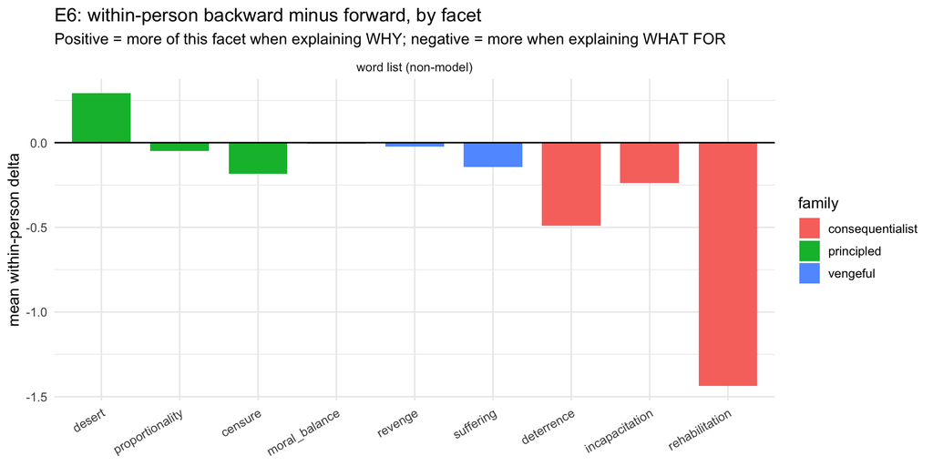

```r
# =========================================================================
# PHASE 8b: FIGURE -- THE E6 DELTAS
# -------------------------------------------------------------------------
# WHAT THIS CHUNK DOES: plots the mean within-person delta per facet, coloured by
# facet family, one panel per stream.
# PREREG: 2.4 (E6). WRITES: output/figures/e6_backward_minus_forward.png
#
# The whole prediction is readable as a shape: principled and vengeful bars above
# the zero line, consequentialist bars below it. Colouring by `family` rather than
# by facet is what makes that pattern visible instead of nine unrelated bars.
# =========================================================================

if (!is.null(e6_all) && nrow(e6_all)) {
  p_e6 <- ggplot2::ggplot(
      # Explicit factor levels keep the facets in scheme order (principled,
      # vengeful, consequentialist) rather than alphabetical, so the predicted
      # sign change falls at one place in the axis.
      e6_all %>% dplyr::mutate(facet = factor(facet, levels = FACETS_ALL)),
      ggplot2::aes(x = facet, y = delta, fill = family)) +
    ggplot2::geom_col(position = ggplot2::position_dodge(width = .8), width = .75) +
    # The zero line is the reference the whole prediction is stated against.
    ggplot2::geom_hline(yintercept = 0) +
    # One panel per stream with free y scales: ensemble scores and word-list rates
    # per 100 words live on completely different scales, and a shared axis would
    # flatten one of them into a line. What is being compared across panels is the
    # PATTERN of signs, not the magnitudes.
    ggplot2::facet_wrap(~ stream, ncol = 1, scales = "free_y") +
    ggplot2::labs(title = "E6: within-person backward minus forward, by facet",
                  subtitle = "Positive = more of this facet when explaining WHY; negative = more when explaining WHAT FOR",
                  x = NULL, y = "mean within-person delta") +
    ggplot2::theme_minimal(base_size = 12) +
    ggplot2::theme(axis.text.x = ggplot2::element_text(angle = 30, hjust = 1))
  print(p_e6)
  ggplot2::ggsave(file.path(OUT_FIGURES, "e6_backward_minus_forward.png"),
                  p_e6, width = 10, height = 6, dpi = 200)
} else {
  awaiting_colab("The E6 figure", NLP_FILES[["ensemble"]])
}
```

# PHASE 9: E7 — FACETS ADDED TO THE SENTENCE MODEL

**E7 (exploratory).** The language facets add prediction of the within-vignette sentence **on top of** the survey measures.

> “…we add the facet scores to a model predicting the within-vignette sentence on top of the survey measures, using **the eight-item punitiveness scale rather than the full index, because the full index already contains the sentence**.” — prereg §6.7

The outcome is `Sentence1_z` (standardized within vignette). The baseline predictor is `punitiveness`, the **eight self-report items**. `punitiveness_full` — which adds `Sentence1_z` — **must never** appear here, and a hard guard below stops the chunk if it ever does. Word count is a covariate. Facets are taken from the **backward-looking** sentence justification (Q1), the response that is actually about this sentence.

```r
# =========================================================================
# PHASE 9a: THE E7 CIRCULARITY GUARD
# -------------------------------------------------------------------------
# WHAT THIS CHUNK DOES: fixes the E7 baseline predictor set, asserts that nothing
# containing the sentence is in it, and prints both correlations with the outcome
# so the size of the circularity being avoided is on the record.
# PREREG: 6.7 -- "using the eight-item punitiveness scale rather than the full
#         index, because the full index already contains the sentence"; the same
#         principle appears at 5.3 and 5.11 for the sentencing ratio.
# WRITES: E7_BASE_PREDICTORS, FORBIDDEN_IN_E7. Computes no result.
#
# HAZARD, STATED PLAINLY. E7 predicts Sentence1_z. punitiveness_full is the eight
# self-report items PLUS Sentence1_z. Using it as the baseline predictor would put
# the sentence on both sides of the model: the baseline R2 would be inflated by an
# identity rather than by anything anyone measured, and the incremental R2 the
# facets have to beat would be correspondingly meaningless. Use `punitiveness`,
# the eight self-report items, which contains no sentence.
#
# The guard is a stopifnot rather than a comment because a silent version of this
# mistake produces a plausible-looking table. The second stopifnot pair in the
# next chunk re-checks the literal model formulas, so the assertion covers what is
# actually fitted and not merely what was intended.
# =========================================================================

# HARD GUARD: the sentence must not appear on both sides of the model.
E7_BASE_PREDICTORS <- c("sv_punitiveness", "n_words")
# Both the sv_-prefixed and bare names are listed, because the frame carries the
# prefixed form and a hand-edit might reach for the unprefixed one.
FORBIDDEN_IN_E7    <- c("sv_punitiveness_full", "punitiveness_full",
                        "sv_Sentence1", "Sentence1")
stopifnot(!any(FORBIDDEN_IN_E7 %in% E7_BASE_PREDICTORS))
cat("E7 circularity guard: baseline predictors are",
    paste(E7_BASE_PREDICTORS, collapse = " + "), "\n")
```

```
## E7 circularity guard: baseline predictors are sv_punitiveness + n_words
```

```r
cat("  punitiveness (8 self-report items) is used; punitiveness_full is BLOCKED.\n")
```

```
##   punitiveness (8 self-report items) is used; punitiveness_full is BLOCKED.
```

```r
# The two correlations are printed side by side as a demonstration. The first is
# a real association between self-reported punitiveness and the sentence someone
# imposed. The second is larger by construction, because Sentence1_z is one of the
# two things averaged into punitiveness_full -- it is partly the sentence
# correlated with itself. Seeing the gap makes the rule self-evidently necessary
# rather than merely asserted.
cat(sprintf("  For reference, r(punitiveness, Sentence1_z) = %.3f and r(punitiveness_full, Sentence1_z) = %.3f\n",
            part_cor(survey$punitiveness, survey$Sentence1_z)$r,
            part_cor(survey$punitiveness_full, survey$Sentence1_z)$r))
```

```
##   For reference, r(punitiveness, Sentence1_z) = 0.469 and r(punitiveness_full, Sentence1_z) = 0.857
```

```r
cat("  The second number is inflated by construction - that is exactly why it is barred.\n")
```

```
##   The second number is inflated by construction - that is exactly why it is barred.
```

```r
# =========================================================================
# PHASE 9b: E7 -- DO THE FACETS ADD TO THE SENTENCE MODEL?
# -------------------------------------------------------------------------
# WHAT THIS CHUNK DOES: fits a survey-only baseline and a survey-plus-facets
# model predicting the within-vignette sentence, and compares them with a nested
# F test. Reports the incremental R2.
# PREREG: 2.4 (E7 -- the facets "add prediction of the sentence beyond the
#         self-report scales"), 6.7 (the eight-item scale, not the full index).
# WRITES: e7_results; output/tables/e7_sentence_model.csv; one FAMILY row.
#
# THE MODELS:
#   baseline  Sentence1_z ~ punitiveness(8 items) + word count
#   full      baseline + the facet scores
# A nested F test is the right comparison because the models are nested by
# construction -- the full model is the baseline plus terms -- so the F is exactly
# a test of whether those added terms explain variance the baseline did not. The
# incremental R2 is the effect size that goes with it.
#
# FACETS COME FROM Q1 ONLY. The sentence justification is the response actually
# about this sentence. Using the ranking explanation would ask whether the way
# someone described their general goals predicts a particular sentence, which is a
# different and weaker question.
#
# GUARD: E_READY -- but note the else branch fits the BASELINE anyway, because it
# uses only survey variables. That is the most useful thing this chunk can do
# before the ensemble arrives: it establishes the R2 the facets will have to
# improve on.
# =========================================================================

e7_results <- NULL

if (E_READY) {

  # Prefer the gate-passing facets: E7 is about whether validated language
  # measures add predictive value, and entering unvalidated facets would let noise
  # inflate R2 through sheer number of predictors.
  e7_facets <- if (length(GATE_PASS)) GATE_PASS else character(0)
  if (!length(e7_facets)) {
    # If nothing passed, the model is still fitted -- but on a fixed, small,
    # theory-chosen set (desert, revenge, suffering: the three facets with survey
    # anchors that bear most directly on sentencing) rather than on all nine, and
    # it is labelled descriptive. Choosing the subset by theory rather than by
    # which facets performed best is what keeps this from becoming a search.
    cat("No facet cleared the 6.7 gate, so E7 is fitted on a fixed, theory-chosen\n")
    cat("set -- desert, revenge, suffering -- as a descriptive model only; it\n")
    cat("supports no claim.\n")
    e7_facets <- intersect(c("desert", "revenge", "suffering"), FACETS_ALL)
  }
  e7_cols <- intersect(paste0("ens_", e7_facets), names(facets_joined))

  dd <- facets_joined %>%
    # Q1 only, and only people who wrote something.
    dplyr::filter(item_type == "backward", nonblank) %>%
    dplyr::select(response_id, n_words, sv_punitiveness, sv_punitiveness_full,
                  sv_Sentence1_z, dplyr::all_of(e7_cols)) %>%
    # LISTWISE COMPLETE, AND IT MUST BE. The two models have to be fitted on
    # exactly the same rows or the R2 difference is not an increment at all -- it
    # would confound the added predictors with a change of sample. Filtering once,
    # up front, guarantees it. (sv_punitiveness_full is selected only so it is
    # visible in the frame; it never enters a formula.)
    dplyr::filter(stats::complete.cases(.))

  # Need more rows than parameters plus a margin, or the full model is unstable.
  if (nrow(dd) > (5 + length(e7_cols))) {
    base_fml <- stats::as.formula("sv_Sentence1_z ~ sv_punitiveness + n_words")
    full_fml <- stats::as.formula(paste("sv_Sentence1_z ~ sv_punitiveness + n_words +",
                                        paste(e7_cols, collapse = " + ")))
    # Re-assert the guard on the literal formulas that will be fitted.
    # The Phase 9a assertion checked the intended predictor list; this one checks
    # the strings that actually go to lm(), which is where the circularity would
    # have to show up if it were ever introduced by an edit to the formula rather
    # than to the list.
    stopifnot(!grepl("punitiveness_full", paste(deparse(base_fml), collapse = " ")))
    stopifnot(!grepl("punitiveness_full", paste(deparse(full_fml), collapse = " ")))

    m_base <- stats::lm(base_fml, data = dd)
    m_full <- stats::lm(full_fml, data = dd)
    # anova() on two nested lm objects gives the partial F for the added block.
    cmp <- stats::anova(m_base, m_full)

    # Row 2 of the anova table is the comparison row (row 1 describes the baseline
    # alone). delta_r2 is the plain R2 difference rather than adjusted R2, because
    # the F test already accounts for the number of added parameters and the two
    # would otherwise penalise the same thing twice.
    delta_r2 <- summary(m_full)$r.squared - summary(m_base)$r.squared
    f_stat <- cmp$F[2]; p_val <- cmp$`Pr(>F)`[2]

    cat("\n--- Baseline: survey only (8-item punitiveness + word count) ---\n")
    print(summary(m_base)$coefficients)
    cat(sprintf("R2 = %.4f\n", summary(m_base)$r.squared))
    cat("\n--- Full: survey + language facets ---\n")
    print(summary(m_full)$coefficients)
    cat(sprintf("R2 = %.4f\n", summary(m_full)$r.squared))
    cat(sprintf("\nIncremental R2 from the facets: %.4f, F(%d, %d) = %.3f, p %s\n",
                delta_r2, cmp$Df[2], cmp$Res.Df[2], f_stat, format_p(p_val)))

    e7_results <- data.frame(
      model = c("survey only", "survey + facets"),
      predictors = c(paste(deparse(base_fml), collapse = ""),
                     paste(deparse(full_fml), collapse = "")),
      r2 = c(summary(m_base)$r.squared, summary(m_full)$r.squared),
      delta_r2 = c(NA_real_, delta_r2), F = c(NA_real_, f_stat),
      p = c(NA_real_, p_val), n = nrow(dd), stringsAsFactors = FALSE)
    print(knitr::kable(e7_results, digits = 4, row.names = FALSE,
                       caption = "E7: do the facets add to the sentence model beyond the 8-item punitiveness scale?"))
    readr::write_csv(e7_results, file.path(OUT_TABLES, "e7_sentence_model.csv"))

    # CI left NA: an incremental R2 has no simple closed-form interval, and the
    # F test with its exact p is the inference here. The registry allows NA
    # bounds for exactly this case.
    # claim_eligible only if something cleared the gate -- an R2 increment from
    # unvalidated facets shows that the text contains SOMETHING predictive, not
    # that the retributive facets do.
    register_test("E7", "facets added to Sentence1_z ~ punitiveness(8) + word count",
                  "delta R2", delta_r2, NA_real_, NA_real_, p_val, nrow(dd),
                  claim_eligible = length(GATE_PASS) > 0)
  } else {
    cat("Too few complete cases for the E7 model.\n")
  }

} else {
  awaiting_colab("E7 (facets added to the sentence model beyond the 8-item punitiveness scale)",
                 c(NLP_FILES[["ensemble"]], NLP_FILES[["agreement"]]))
  # The baseline is computable now and worth printing: it is the bar the facets
  # will have to clear, and knowing it in advance is the difference between
  # reading a future incremental R2 as impressive or as trivial.
  cat("\nThe baseline half of E7 uses only survey variables and can be shown now:\n")
  dd0 <- facets_joined %>%
    # Same filters as the full analysis (Q1, non-blank, complete cases) so this
    # baseline is directly comparable to the one that will be fitted later, not a
    # different model on a different sample.
    dplyr::filter(item_type == "backward", nonblank) %>%
    dplyr::select(n_words, sv_punitiveness, sv_Sentence1_z) %>%
    dplyr::filter(stats::complete.cases(.))
  # Note the predictor: sv_punitiveness, the eight self-report items. Same rule as
  # the guarded branch -- the full index is barred here too.
  m0 <- stats::lm(sv_Sentence1_z ~ sv_punitiveness + n_words, data = dd0)
  print(summary(m0)$coefficients)
  cat(sprintf("Baseline R2 = %.4f (n = %d). The facets will be added to THIS model.\n",
              summary(m0)$r.squared, nrow(dd0)))
}
```

```
## --------------------------------------------------------------------------
## AWAITING COLAB OUTPUTS from Analysis/NLP/colab/
##   E7 (facets added to the sentence model beyond the 8-item punitiveness scale) cannot be computed yet.
##   Required file(s) not found: ensemble_facet_scores.csv, ensemble_agreement.csv
##   Produced by the notebooks in Analysis/NLP/colab/:
##     01_preprocessing_and_facets   -> facet_dictionary_scores.csv, gold_codes.csv,
##                                      gold_split_assignment.csv
##     02_llm_ensemble_scoring       -> ensemble_facet_scores.csv, ensemble_agreement.csv
##     03_embeddings_and_similarity  -> embedding_facet_similarity.csv
##   Drop the downloaded CSVs into Analysis/NLP/outputs/ (or R/nlp/) and re-knit.
## --------------------------------------------------------------------------
##
## The baseline half of E7 uses only survey variables and can be shown now:
##                   Estimate Std. Error  t value
## (Intercept)     -1.4965558   0.104393 -14.3358
## sv_punitiveness  0.3659360   0.022495  16.2672
## n_words          0.0001342   0.001299   0.1033
##                                                                  Pr(>|t|)
## (Intercept)     0.0000000000000000000000000000000000000000025472111408301
## sv_punitiveness 0.0000000000000000000000000000000000000000000000000001209
## n_words         0.9177490279614194390589432259730529040098190307617187500
## Baseline R2 = 0.2198 (n = 948). The facets will be added to THIS model.
```

```r
# =========================================================================
# PHASE 9c: THE SECONDARY E7 CHECKS
# -------------------------------------------------------------------------
# WHAT THIS CHUNK DOES: correlates the two vengeful facets with the shark pain
# rating and with the sentence, word count partialled.
# PREREG: 6.7 -- "We also report whether revenge and suffering language predict
#         the shark pain rating and the sentence."
# WRITES: printed table only. Registers NOTHING -- the prereg says "report",
#         which is a descriptive instruction, and E7's registered test is the
#         incremental R2 above.
#
# WHY THE SHARK. Shark_3 asks how painful the animal's death should be
# (prereg 5.10). A shark cannot be deterred, reformed or held responsible, so no
# forward-looking justification and no Kantian desert claim applies to it: wanting
# its death to hurt is close to a pure measure of the appetite for suffering.
# Vengeful LANGUAGE tracking that rating would be striking convergence between two
# very different measurements of the same disposition.
#
# GUARD: E_READY plus the presence of sv_Shark_3, which is optional in the scored
# file (see the any_of() in Phase 3f).
# =========================================================================

# Secondary E7 question from prereg 6.7: "We also report whether revenge and
# suffering language predict the shark pain rating and the sentence."
if (E_READY && "sv_Shark_3" %in% names(facets_joined)) {
  dd <- facets_joined %>% dplyr::filter(item_type == "backward", nonblank)
  sec <- lapply(intersect(paste0("ens_", VENGEFUL_FACETS), names(dd)), function(cc) {
    # `a` is the shark-pain correlation, `b` the sentence correlation. Both are
    # partial on word count, and n is reported separately for each because
    # Shark_3 is only answered by participants who said the shark should be
    # killed, so its n is the smaller of the two.
    a <- part_cor(dd[[cc]], dd$sv_Shark_3, dd$n_words)
    b <- part_cor(dd[[cc]], dd$sv_Sentence1_z, dd$n_words)
    data.frame(facet = sub("^ens_", "", cc),
               r_shark_pain = a$r, p_shark = a$p, n_shark = a$n,
               r_sentence_z = b$r, p_sentence = b$p, n_sentence = b$n)
  })
  if (length(sec)) {
    print(knitr::kable(do.call(rbind, sec), digits = 3, row.names = FALSE,
                       caption = "Secondary: does vengeful language predict the shark pain rating and the sentence?"))
  }
} else {
  awaiting_colab("The secondary E7 checks (vengeful language -> shark pain rating, sentence)",
                 NLP_FILES[["ensemble"]])
}
```

```
## --------------------------------------------------------------------------
## AWAITING COLAB OUTPUTS from Analysis/NLP/colab/
##   The secondary E7 checks (vengeful language -> shark pain rating, sentence) cannot be computed yet.
##   Required file(s) not found: ensemble_facet_scores.csv
##   Produced by the notebooks in Analysis/NLP/colab/:
##     01_preprocessing_and_facets   -> facet_dictionary_scores.csv, gold_codes.csv,
##                                      gold_split_assignment.csv
##     02_llm_ensemble_scoring       -> ensemble_facet_scores.csv, ensemble_agreement.csv
##     03_embeddings_and_similarity  -> embedding_facet_similarity.csv
##   Drop the downloaded CSVs into Analysis/NLP/outputs/ (or R/nlp/) and re-knit.
## --------------------------------------------------------------------------
```

# PHASE 10: BENJAMINI–HOCHBERG FDR WITHIN THE E3–E7 FAMILY

> “E3 through E7 form **one exploratory family**; we control the false discovery rate within it and report effect sizes and confidence intervals.” — prereg §6.7

The correction is applied **within** this family and nowhere else. These are **exploratory** tests: nothing here is confirmatory, and no result here is combined with the confirmatory H1–H21 family in the main analysis document. Descriptive results — the word-list previews, base-rate reports, the holistic “both” rate — are deliberately excluded from the family so they neither borrow nor lend power.

```r
# =========================================================================
# PHASE 10: BENJAMINI-HOCHBERG ACROSS THE E3-E7 FAMILY
# -------------------------------------------------------------------------
# WHAT THIS CHUNK DOES: applies BH-FDR to every p-value in the FAMILY registry,
# sorts by raw p, prints the family, and counts how many survive at q = .05 --
# separating the survivors that are claim-eligible under the 6.7 gate from those
# that are not.
# PREREG: 2.4 and 6.7 -- "E3 through E7 form one exploratory family; we control
#         the false discovery rate within it and report effect sizes and
#         confidence intervals." Threshold alpha = .05 per prereg 6.8.
# WRITES: FAMILY gains p_BH and sig_BH; output/tables/e3_e7_family_fdr.csv.
#
# WHY BH RATHER THAN BONFERRONI. These are exploratory tests whose purpose is to
# identify effects worth pursuing. Controlling the family-wise error rate would
# be the right instrument if a single false positive anywhere invalidated the set;
# controlling the FALSE DISCOVERY RATE -- the expected share of claimed effects
# that are false -- is the right one when the output is a list of candidates. It
# is also far less conservative across a family this size, and BH is what the
# prereg specifies here and at 6.1 for the H1 correlation set.
#
# ACROSS EXACTLY WHICH SET. The registry, and only the registry: the tests of E3,
# E4, E5, E6 and E7, which are ONE family. Not across the descriptive results
# (word-list previews, base rates, co-firing rates, the facet-by-facet E4
# decomposition, the secondary shark checks) -- none of those were registered, and
# adding them would enlarge the denominator with results nobody claims from. And
# not across the confirmatory H1-H21 family in the main analysis document, which
# gets its own corrections over its own sets.
#
# EXPLORATORY THROUGHOUT. A row surviving BH here is an exploratory finding.
# Nothing in this document is confirmatory.
# =========================================================================

if (nrow(FAMILY) > 0) {
  # p.adjust(method = "BH") returns adjusted p-values that may be compared
  # directly against q = .05; no separate step-up bookkeeping is needed. NA
  # p-values (a test that could not be computed) pass through as NA and are
  # excluded from the adjustment, which is correct -- a test that did not run is
  # not a test that failed.
  FAMILY$p_BH <- stats::p.adjust(FAMILY$p, method = "BH")
  # Stars on the ADJUSTED p, not the raw one, so the printed table cannot be
  # skimmed for significance that the correction has already removed.
  FAMILY$sig_BH <- ifelse(is.na(FAMILY$p_BH), "", sig_stars(FAMILY$p_BH))
  # Sorted by raw p, which is the order the BH step-up procedure itself works in,
  # so the table reads in the same sequence the correction applied.
  FAMILY <- FAMILY[order(FAMILY$p), ]

  print(knitr::kable(FAMILY, digits = 4, row.names = FALSE,
                     caption = "The E3-E7 exploratory family with Benjamini-Hochberg FDR control"))
  readr::write_csv(FAMILY, file.path(OUT_TABLES, "e3_e7_family_fdr.csv"))

  # Family size is printed because BH's severity depends on it: the same raw p
  # survives or does not depending on how many tests it sits among, so the
  # denominator belongs in the output next to the result.
  cat(sprintf("\nFamily size: %d tests across %s.\n", nrow(FAMILY),
              paste(sort(unique(FAMILY$hypothesis)), collapse = ", ")))
  # q = .05 matches the alpha of prereg 6.8; under BH it means that among the
  # tests declared here, about 5% are expected to be false discoveries.
  cat(sprintf("Surviving BH at q = .05: %d\n", sum(FAMILY$p_BH < .05, na.rm = TRUE)))
  cat(sprintf("  ... of which claim-eligible under the 6.7 gate: %d\n",
              sum(FAMILY$p_BH < .05 & FAMILY$claim_eligible, na.rm = TRUE)))
  cat(sprintf("  ... descriptive only (facet did not clear the gate): %d\n",
              sum(FAMILY$p_BH < .05 & !FAMILY$claim_eligible, na.rm = TRUE)))
  cat("\nBH is applied across the whole E3-E7 family, gate-passing or not: the prereg\n")
  cat("defines the family as E3 through E7, and correcting over the larger set is the\n")
  cat("conservative choice. The gate then decides what a surviving test may be used\n")
  cat("FOR - a survivor on a non-gate-passing facet is reported and supports no claim.\n")
  cat("\nAll of these are EXPLORATORY (prereg 2.4). None is labelled confirmatory.\n")
} else {
  cat("The E3-E7 family registry is empty: no test has been run yet.\n\n")
  awaiting_colab("The BH-FDR correction across the E3-E7 exploratory family",
                 c(NLP_FILES[["ensemble"]], NLP_FILES[["agreement"]]))
  cat("\nWhen the ensemble arrives, the family will contain, per gate-passing facet:\n")
  cat("  E3  2 backward items x facets x {group contrast, continuous regression}\n")
  cat("  E4  the principled x vengeful partial correlation, per backward item\n")
  cat("  E5  the desert x proportionality partial correlation, per backward item\n")
  cat("  E6  the within-person backward-minus-forward test, per facet\n")
  cat("  E7  the incremental R2 of the facets over the 8-item punitiveness scale\n")
  cat("and Benjamini-Hochberg is applied across that set and only that set.\n")
  # Write an empty, correctly-shaped family table so downstream tooling has a target.
  # Zero rows but the full column schema, matching the populated version exactly,
  # so a script that reads this CSV works in both states.
  readr::write_csv(FAMILY, file.path(OUT_TABLES, "e3_e7_family_fdr.csv"))
}
```

```
## The E3-E7 family registry is empty: no test has been run yet.
##
## --------------------------------------------------------------------------
## AWAITING COLAB OUTPUTS from Analysis/NLP/colab/
##   The BH-FDR correction across the E3-E7 exploratory family cannot be computed yet.
##   Required file(s) not found: ensemble_facet_scores.csv, ensemble_agreement.csv
##   Produced by the notebooks in Analysis/NLP/colab/:
##     01_preprocessing_and_facets   -> facet_dictionary_scores.csv, gold_codes.csv,
##                                      gold_split_assignment.csv
##     02_llm_ensemble_scoring       -> ensemble_facet_scores.csv, ensemble_agreement.csv
##     03_embeddings_and_similarity  -> embedding_facet_similarity.csv
##   Drop the downloaded CSVs into Analysis/NLP/outputs/ (or R/nlp/) and re-knit.
## --------------------------------------------------------------------------
##
## When the ensemble arrives, the family will contain, per gate-passing facet:
##   E3  2 backward items x facets x {group contrast, continuous regression}
##   E4  the principled x vengeful partial correlation, per backward item
##   E5  the desert x proportionality partial correlation, per backward item
##   E6  the within-person backward-minus-forward test, per facet
##   E7  the incremental R2 of the facets over the 8-item punitiveness scale
## and Benjamini-Hochberg is applied across that set and only that set.
```

# PHASE 11: EXPORT, PLACEHOLDERS, SESSION INFO

```r
# =========================================================================
# PHASE 11a: EXPORT INVENTORY AND THE PARTICIPANT-LEVEL FEATURE FILE
# -------------------------------------------------------------------------
# WHAT THIS CHUNK DOES: lists everything the knit wrote, and exports the joined
# facet features for downstream use.
# PREREG: 6.7 -- "The model set and versions, the scoring prompts, the word lists,
#         the raw model output, and the analysis code go on the project's OSF
#         page."
# WRITES: data/cleaned/retribution_nlp_features.csv (only if a facet stream
#         exists).
# =========================================================================

# Listed by scanning the directories rather than from a hard-coded manifest, so
# the inventory reflects what was actually written on this run -- including
# nothing at all, when the whole language side is awaiting Colab.
written <- list.files(OUT_TABLES, pattern = "\\.csv$", full.names = TRUE)
figs    <- list.files(OUT_FIGURES, pattern = "\\.png$", full.names = TRUE)

cat("Tables written to output/tables/:\n")
```

```
## Tables written to output/tables/:
```

```r
if (length(written)) for (f in written) cat(sprintf("  %s\n", basename(f))) else cat("  (none)\n")
```

```
##   contrast_measure_agreement.csv
##   contrasts_all_measures.csv
##   contrasts_continuous_ratio.csv
##   contrasts_continuous_sentence_resid.csv
##   contrasts_continuous.csv
##   contrasts_median_split.csv
##   contrasts_ranking.csv
##   contrasts_sentencing_ratio.csv
##   contrasts_side_by_side.csv
##   contrasts_tertiles.csv
##   data_provenance.csv
##   demographics.csv
##   descriptives.csv
##   E1_personality_continuous.csv
##   E1_personality_contrasts.csv
##   E1_personality.csv
##   E2_solidarity_steiger.csv
##   e3_e7_family_fdr.csv
##   e3_wordlist_preview.csv
##   e4_principled_vengeful.csv
##   e5_desert_proportionality.csv
##   e6_backward_minus_forward.csv
##   EFA_correlate_intercorrelations.csv
##   EFA_correlate_loadings.csv
##   exclusion_funnel.csv
##   gate_table.csv
##   goal_ranked_first.csv
##   goal_subscales.csv
##   H1_correlations_full_index.csv
##   H1_correlations.csv
##   H10_steiger.csv
##   H11_H1_comparison.csv
##   H11_H1_retributivists.csv
##   H11_H10_steiger.csv
##   H11_H2_retributivists.csv
##   H11_H3_eigenvalues.csv
##   H11_H4_shares.csv
##   H11_H4_tests.csv
##   H11_H5_paired.csv
##   H11_H6_cfa_fit.csv
```

[output cut: 17 more lines]

```
##   H6_summary.csv
##   H7_limits.csv
##   H8_limits_punitiveness.csv
##   H9_paired.csv
##   moderator_interactions.csv
##   reliability_alpha_omega.csv
##   response_quality_flags.csv
##   retributivist_group_overlap.csv
##   retributivist_measure_agreement.csv
##   retributivist_measure_convergence.csv
##   sentence_by_vignette.csv
##   sentence_change_contrasts.csv
##   sentence_residualized_correlations.csv
##   sentencing_ratio_by_vignette.csv
##   supplementary_reliability.csv
```

```r
cat("\nFigures written to output/figures/:\n")
```

```
##
## Figures written to output/figures/:
```

```r
if (length(figs)) for (f in figs) cat(sprintf("  %s\n", basename(f))) else cat("  (none)\n")
```

```
##   E1_personality_effects.png
##   e6_backward_minus_forward.png
##   EFA_scree_correlates.png
##   H1_correlate_forest.png
##   H3_correlate_heatmap.png
##   H3_scree.png
##   response_quality_duration.png
##   retributivism_distributions.png
##   retributivist_contrasts.png
##   sentence_ratio_by_vignette.png
##   wordlist_facet_prevalence.png
```

```r
# Participant-level facet features for downstream use, whenever any stream exists.
# The prefix pattern is what makes this generic: whichever of the three streams
# arrived contributes its columns, and the export shape follows the inputs.
feature_cols <- grep("^(ens_|dict_|emb_)", names(facets_joined), value = TRUE)
if (length(feature_cols)) {
  nlp_features <- facets_joined %>%
    # Non-blank rows only, and NO sv_* columns: this file carries scored text
    # plus its keys and its word count, nothing from the survey. The survey side
    # already has its own file, and keeping the two separate means neither can be
    # mistaken for the other or joined to itself.
    dplyr::filter(nonblank) %>%
    dplyr::select(response_id, item_type, n_words, dplyr::all_of(feature_cols))
  readr::write_csv(nlp_features, file.path(OUT_DATA, "retribution_nlp_features.csv"))
  cat(sprintf("\nWrote %s (%d rows x %d cols)\n",
              file.path(OUT_DATA, "retribution_nlp_features.csv"),
              nrow(nlp_features), ncol(nlp_features)))
} else {
  cat("\nNo facet features to export yet.\n")
}
```

```
##
## Wrote data/cleaned/retribution_nlp_features.csv (2839 rows x 12 cols)
```

```r
# =========================================================================
# PHASE 11b: OUTSTANDING INPUTS AND THE STANDING INTERPRETIVE NOTES
# -------------------------------------------------------------------------
# WHAT THIS CHUNK DOES: restates which of the six Colab inputs are present and
# what each one blocks, then records the interpretive commitments that hold
# whatever the data turn out to say.
# PREREG: 6.7 throughout; 4.4 (the stopping rule).
# WRITES: printed table and notes only.
#
# The notes below are decided in advance on purpose. Two of them -- that censure
# and moral balance stay descriptive, and that a proportionality rate under 10%
# makes E5 a null-by-absence -- are rules about how a result WILL be read, and a
# rule of that kind is only worth anything if it is fixed before the number is
# known.
# =========================================================================

cat("=== WHAT IS STILL A PLACEHOLDER ===\n\n")
```

```
## === WHAT IS STILL A PLACEHOLDER ===
```

```r
# Each row pairs a file with what it blocks, so the table reads as a dependency
# list rather than an inventory: the cost of each missing input is stated in terms
# of the analysis it prevents.
placeholders <- data.frame(
  item = c("ensemble_facet_scores.csv", "ensemble_agreement.csv",
           "embedding_facet_similarity.csv", "facet_dictionary_scores.csv",
           "gold_codes.csv", "gold_split_assignment.csv"),
  needed_for = c("E3, E4, E5, E6, E7 (all primary facet tests)",
                 "gate clause A (inter-model ICC >= .60)",
                 "convergence reporting only (never a gate)",
                 "the non-model corroboration E4 requires",
                 "human-anchored validation of the ensemble",
                 "the frozen SEED/TEST split behind every validation number"),
  status = c(ifelse(ENS_READY, "present", "AWAITING"),
             ifelse(AGREE_READY, "present", "AWAITING"),
             ifelse(EMB_READY, "present", "AWAITING"),
             ifelse(DICT_READY, "present", "AWAITING"),
             ifelse(GOLD_READY, "present", "AWAITING"),
             ifelse(SPLIT_READY, "present", "AWAITING")),
  stringsAsFactors = FALSE)
print(knitr::kable(placeholders, row.names = FALSE))
```

```
##
##
## |item                           |needed_for                                                |status   |
## |:------------------------------|:---------------------------------------------------------|:--------|
## |ensemble_facet_scores.csv      |E3, E4, E5, E6, E7 (all primary facet tests)              |AWAITING |
## |ensemble_agreement.csv         |gate clause A (inter-model ICC >= .60)                    |AWAITING |
## |embedding_facet_similarity.csv |convergence reporting only (never a gate)                 |AWAITING |
## |facet_dictionary_scores.csv    |the non-model corroboration E4 requires                   |present  |
## |gold_codes.csv                 |human-anchored validation of the ensemble                 |AWAITING |
## |gold_split_assignment.csv      |the frozen SEED/TEST split behind every validation number |AWAITING |
```

```r
cat("\nOther standing notes:\n")
```

```
##
## Other standing notes:
```

```r
cat("  - Censure and moral balance have no admissible survey anchor, so they can never\n")
```

```
##   - Censure and moral balance have no admissible survey anchor, so they can never
```

```r
cat("    clear gate clause B. They stay exploratory descriptives by design, not by\n")
```

```
##     clear gate clause B. They stay exploratory descriptives by design, not by
```

```r
cat("    accident, and are reported as such however the data come out.\n")
```

```
##     accident, and are reported as such however the data come out.
```

```r
cat("  - Proportionality language is rare. If its realized non-zero rate in the\n")
```

```
##   - Proportionality language is rare. If its realized non-zero rate in the
```

```r
cat("    backward-looking items stays below 10%, E5 is reported as a descriptive\n")
```

```
##     backward-looking items stays below 10%, E5 is reported as a descriptive
```

```r
cat("    null-by-absence rather than as an orthogonality result.\n")
```

```
##     null-by-absence rather than as an orthogonality result.
```

```r
cat("  - The human gold codes are the strongest non-model anchor for E4; until they\n")
```

```
##   - The human gold codes are the strongest non-model anchor for E4; until they
```

```r
cat("    arrive, the word list is the only non-model stream available.\n")
```

```
##     arrive, the word list is the only non-model stream available.
```

```r
cat("  - Full dataset (N = 948 after exclusions). Collection is complete, so the\n")
```

```
##   - Full dataset (N = 948 after exclusions). Collection is complete, so the
```

```r
cat("    preregistered tests are the single run the stopping rule in prereg 4.4\n")
```

```
##     preregistered tests are the single run the stopping rule in prereg 4.4
```

```r
cat("    provides for.\n")
```

```
##     provides for.
```

```r
# =========================================================================
# PHASE 11c: PROVENANCE AND SESSION INFO
# -------------------------------------------------------------------------
# WHAT THIS CHUNK DOES: prints which survey source produced these numbers, the
# analytic N, the corpus size, and the full R session.
# PREREG: 6.7 -- the analysis code and materials go on the project's OSF page,
#         and sessionInfo() is what makes the environment reproducible from that
#         posting: exact R version and the version of every attached package.
#
# survey_source distinguishes 01's authoritative scored file from the inline
# fallback build, so a reader of the knitted HTML never has to guess which path
# produced the numbers above it.
# =========================================================================

cat("Survey source :", survey_source, "\n")
```

```
## Survey source : data/cleaned/retribution_scored.csv
```

```r
cat("Analytic N    :", nrow(survey), "\n")
```

```
## Analytic N    : 948
```

```r
cat("Corpus rows   :", nrow(texts_long), " (", sum(texts_long$nonblank), " non-blank )\n\n")
```

```
## Corpus rows   : 2844  ( 2839  non-blank )
```